# QUESTÕES DE ESTATÍSTICA BÁSICA

QUESTÃO 1 (SQL 01)

(Enem PPL 2022 — reaplicação) Até a Copa de 2010, apenas sete jogadores haviam conseguido o feito de marcar 8 ou mais gols em uma mesma edição da Copa do Mundo. O quadro apresenta os anos das edições da Copa nas quais ocorreram esses feitos, quais foram os jogadores que os realizaram e os respectivos números de gols marcados por cada um deles.

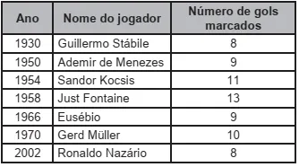

Para facilitar a análise sobre a quantidade de gols marcados por esses artilheiros nas referidas copas, foi calculada a mediana da distribuição dos números de gols marcados por eles nas sete copas especificadas no quadro.

A mediana dessa distribuição é igual a

1. 9,0.
2. 9,7.
3. 10,0.
4. 10,2.
5. 13,0.

RESPOSTA: A

Para encontrar a [mediana](https://brasilescola.uol.com.br/matematica/mediana.htm), colocaremos os dados em ordem:

8 8 9 9 10 11 13

Sabemos que a mediana é o termo que está posicionado no centro. Como há 7 elementos, a mediana é o 4º valor:

8 8 9 **9** 10 11 13

Assim, a mediana desse conjunto de dados é 9.

QUESTÃO 2 (id 02)

(Enem PPL 2010) Em uma corrida de regularidade, a equipe campeã é aquela em que o tempo dos participantes mais se aproxima do tempo fornecido pelos organizadores em cada etapa. Um campeonato foi organizado em 5 etapas, e o tempo médio de prova indicado pelos organizadores foi de 45 minutos por prova. No quadro, estão representados os dados estatísticos das 5 equipes mais bem classificadas.

Dados estatísticos das equipes mais bem classificadas (em minutos):

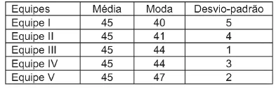

Utilizando os dados estatísticos do quadro, a campeã foi a equipe

RESPOSTA: C

Sabemos que quanto menor é o desvio padrão, mais regulares são os dados. Note que todas possuem a mesma média, entretanto a equipe III é a que tem o menor desvio padrão. Logo, essa é a equipe que possui o tempo mais próximo da meta.

QUESTÃO 3 (id 03)

(UFT-TO) A nota final para uma disciplina de uma instituição de ensino superior é a média ponderada das notas A, B e C, cujos pesos são 1, 2 e 3, respectivamente. Paulo obteve A = 3,0 e B = 6,0. Quanto ele deve obter em C para que sua nota final seja 6,0?

1. 7,0
2. 9,0
3. 8,0
4. 10,0

RESPOSTA: A

Seja x a terceira nota, temos que:

[figure not shown]

QUESTÃO 4 (id 04)

(Enem 2015) Uma pessoa, ao fazer uma pesquisa com alguns alunos de um curso, coletou as idades dos entrevistados e organizou esses dados em um gráfico.

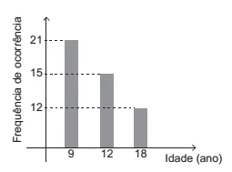

Qual a moda das idades, em anos, dos entrevistados?

1. 9
2. 12
3. 13
4. 15
5. 21

RESPOSTA: A

A moda é o valor com maior frequência, ou seja, o valor que mais ocorreu. Analisando o gráfico, vemos que o valor que possui a maior ocorrência é a idade de 9 anos, que apareceu 21 vezes. Sendo assim, a moda desse conjunto é 9.

QUESTÃO 5 (id 05)

Buscando fazer uma renda extra, Fabrício decidiu fazer bolo no pote em sua casa para vender na escola. Antes de começar a produzir, ele resolveu fazer uma pesquisa de campo para entender qual seriam os sabores preferidos dos seus clientes. Considerando que os potenciais clientes eram os 400 estudantes matriculados e os 22 funcionários da escola, Fabrício foi até lá para realizar a sua pesquisa e obteve a seguinte resposta:

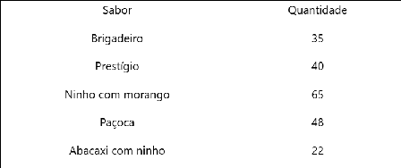

Analisando as respostas coletadas, podemos afirmar que:

1. A pesquisa foi realizada com uma amostra de 422 pessoas.
2. A pesquisa foi realizada com uma população de 210 pessoas.
3. A pesquisa foi realizada com uma amostra de 210 pessoas.
4. A pesquisa foi realizada com uma população de 400 pessoas.

RESPOSTA: C

A população abarca os estudantes e os funcionários, logo ela corresponde a 400 + 22 = 422 pessoas. Já a amostra é composta pelas pessoas que foram abordadas, que é igual a 35 + 40 + 65 + 48 + 22 = 210. Concluímos, então, que a pesquisa foi realizada com uma amostra de 210 pessoas.

QUESTÃO 6 (id 06)

Dados os números 10, 6, 4, 3 e 9, cinco números de uma lista de 8 números inteiros, o menor valor possível para a mediana desse conjunto é:

1. 3,0
2. 3,5
3. 4,0
4. 6,0
5. 10,0

RESPOSTA: B

Para que mediana seja o menor valor possível, os 3 números restantes, x, y e z, devem ser menores ou iguais a 3, deixando a lista da seguinte maneira:

x, y, z, **3, 4,** 6, 9, 10

Como a quantidade de termos é par, pois na sequência há 8 números, somaremos os dois termos centrais e dividiremos por 2:

(3 + 4) : 2 = 3,5

QUESTÃO 7 (id 07) ARRUMAR

Na tabela a seguir está a média dos alunos nos 1º, 2º e 3º bimestres em Matemática.

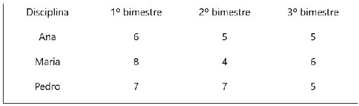

Suponha que a média da escola seja igual a 6 pontos. Se no 4º bimestre a nota de todos os estudantes for igual a 7, podemos afirmar que:

1. Todos os alunos foram aprovados.
2. Somente Ana foi reprovada.
3. Somente Maria foi reprovada.
4. Somente Pedro foi reprovado.

RESPOSTA: B

[figure not shown]

QUESTÃO 8 (id 08)

Durante a organização das eleições para diretor escolar, os estudantes fizeram uma pesquisa sobre a intenção de voto dos alunos entre os candidatos A, B e C. Os resultados obtidos estão na tabela a seguir:

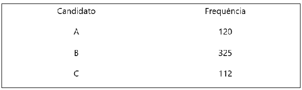

Sabendo que na escola há 607 votantes e que as pessoas restantes não estavam na escola no dia da pesquisa, a porcentagem de pessoas não alcançadas nessa pesquisa é de aproximadamente:

1. 83,0%
2. 72,0%
3. 8,3%
4. 7,2%
5. 6,0%

RESPOSTA: C

Primeiramente, calcularemos a quantidade de respostas obtidas:

120 + 325 + 112 = 557

Agora, calcularemos a diferença:

607 – 557 = 50

Transformando em [porcentagem](https://brasilescola.uol.com.br/matematica/porcentagem.htm), temos que 0,0833… *≈* 8,3%.

QUESTÃO 9

**Quantidade de irmãos dos alunos do 2º A**

1. Menos da metade dos estudantes pesquisados tem 2 irmãos ou mais.
2. Menos da metade dos estudantes pesquisados possui no máximo 2 irmãos.
3. A maior parte dos estudantes pesquisados possui exatamente 1 irmão.
4. Mais da metade dos estudantes pesquisados tem 3 irmãos ou mais.
5. Mais da metade dos estudantes pesquisados possui pelo menos 2 irmãos.

RESPOSTA: E

QUESTÃO 10 ARRUMAR

Durante uma pesquisa feita por um petshop, o atendente da loja realizava duas perguntas para cada um dos clientes atendidos naquele dia:

- Quais são as espécies de seus animais de estimação?
- Quantos animais de estimação de cada espécie você tem?

**Quantidade de animais dos clientes do petshop**

I – Podemos inferir que a pesquisa foi respondida por 45 clientes.

II – O animal mais frequente é o cachorro, que representa aproximadamente 47% dos animais.

III – Há somente 3 animais diferentes de gato, cachorro e peixe.

Marque a alternativa correta:

1. Todas as afirmativas são verdadeiras.
2. Somente a afirmativa I é falsa
3. Somente a afirmativa II é falsa
4. Somente a afirmativa III é falsa.

RESPOSTA: B  
I – Falsa

Um mesmo cliente pode ter mais de um animal, e eles foram contabilizados.

II – Verdadeira

Quando dividimos 21 por 45, temos que:

21 : 45 = 0,47 = 47%

III – Verdadeira

QUESTÃO 11 ARRUMAR

Marque a alternativa que melhor define a área do conhecimento chamada estatística:

1. A estatística é a área da Matemática que estuda a probabilidade de um evento acontecer.
2. A estatística é a área da Matemática que estuda o total de combinações possíveis e o tipo de agrupamento de determinado conjunto.
3. A estatística é a área da Matemática que estuda a coleta de dados, a organização deles, suas representações em gráfico ou tabelas e suas possíveis análises.
4. A estatística é a área da Matemática que estuda o tamanho de regiões planas, desenvolvendo o cálculo de área, perímetro e volume para diferentes formas geométricas.

RESPOSTA: C

A alternativa que melhor define a [estatística](https://brasilescola.uol.com.br/matematica/estatistica-2.htm) é a terceira.

QUESTÃO 12

Os valores dos salários dos funcionários de uma empresa estão representados na tabela a seguir:

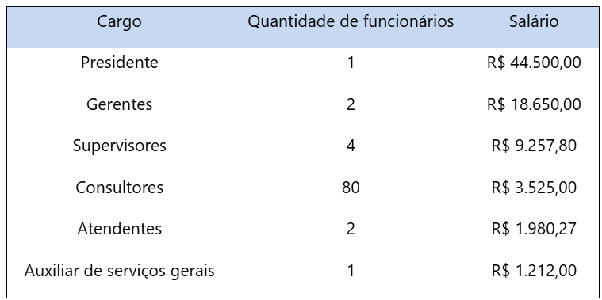

Analisando a tabela de salários dos funcionários da empresa, podemos afirmar que:

1. A moda salarial dessa empresa é R$ 3.525,00, que é o salário dos consultores.
2. A mediana dos salários é de R$ 6.391,40.
3. A maioria dos funcionários ganha abaixo de R$ 3.525,00.
4. A moda salarial dessa empresa é o conjunto {2, 4}.
5. A média salarial dessa empresa é R$ 3.525,00.

RESPOSTA: A

O cargo que possui a maior quantidade de funcionários é o de consultor, logo a moda será o salário de um consultor, que é de R$ 3.525,00.

Fonte desta lista:  
https://exercicios.brasilescola.uol.com.br/exercicios-matematica/exercicios-sobre-estatistica.htm  
QUESTÃO 13

QUESTÃO 14

Considere a tabela de classes (em salários mínimos) com frequências absolutas: 4—8: 10; 8—12: 12; 12—16: 8; 16—20: 5; 20—24: 1 (n=36). Qual é a porcentagem acumulada até a classe 12—16?  
A) 22,22%  
B) 27,78%  
C) 61,11%  
D) 83,33%  
E) 97,22%  
RESPOSTA: D  
Até 12—16 acumulamos 10+12+8=30 observações.  
Logo, porcentagem acumulada = 100·30/36 = 83,33%

QUESTÃO 15

Em um histograma com classes de amplitudes possivelmente diferentes, o livro recomenda que a altura do retângulo da i-ésima classe seja proporcional a:  
A) ni  
B) fi  
C) Δi/fi  
D) fi/Δi (ou ni/Δi)  
E) (ni·Δi)  
RESPOSTA: D  
Para que a área de cada retângulo seja proporcional à frequência relativa fi, a altura deve ser proporcional a fi/Δi (ou ni/Δi). Assim a área total pode ser 1.

QUESTÃO 16

Uma pesquisa coleta as seguintes variáveis: (i) estado civil (solteiro, casado, etc.); (ii) número de filhos; (iii) altura (em cm). Assinale a alternativa que classifica corretamente (i), (ii) e (iii).  
A) (i) qualitativa nominal; (ii) quantitativa discreta; (iii) quantitativa contínua.  
B) (i) qualitativa ordinal; (ii) quantitativa contínua; (iii) quantitativa discreta.  
C) (i) quantitativa discreta; (ii) qualitativa nominal; (iii) quantitativa contínua.  
D) (i) qualitativa nominal; (ii) qualitativa ordinal; (iii) quantitativa discreta.  
E) (i) qualitativa ordinal; (ii) quantitativa discreta; (iii) qualitativa nominal.  
RESPOSTA: A  
Variáveis qualitativas têm realizações do tipo atributo; quando não há ordenação, são nominais.  
Número de filhos resulta de contagem (discreta) e altura resulta de mensuração em intervalo real (contínua).  
Logo: (i) qualitativa nominal; (ii) quantitativa discreta; (iii) quantitativa contínua.

QUESTÃO 17

Um conjunto de dados (ordenado) é: 2, 3, 5, 7, 8, 10, 11, 12, 15. Se acrescentarmos um valor discrepante 67, qual medida tende a ser menos afetada por esse acréscimo?  
A) Média aritmética  
B) Mediana  
C) Amplitude (máx-mín)  
D) Máximo  
E) Soma dos valores  
RESPOSTA: B  
A mediana é resistente (robusta) a valores discrepantes: ao inserir 67, a média muda bastante, mas a mediana permanece próxima à mediana original.

QUESTÃO 18

Dois conjuntos de dados A e B têm a mesma média amostral x̄=50. O desvio padrão amostral de A é S=5 e o de B é S=10. Qual alternativa descreve corretamente os coeficientes de variação?

1. CV(A)=10% e CV(B)=20%
2. CV(A)=20% e CV(B)=10%
3. CV(A)=5% e CV(B)=10%
4. CV(A)=50% e CV(B)=100%
5. CV(A)=2,5% e CV(B)=5%

RESPOSTA: A

Coeficiente de variação: cv = (S / x̄) × 100%.

Para A: cv(A) = (5/50) × 100% = 10%.

Para B: cv(B) = (10/50) × 100% = 20%.

QUESTÃO 19

Se x(1) ≤ x(2) ≤ … ≤ x(n) denota a amostra ordenada, qual alternativa descreve corretamente x(1) e x(n)?  
A) x(1) é a mediana e x(n) é a moda  
B) x(1) é a média e x(n) é o desvio padrão  
C) x(1) é o mínimo e x(n) é o máximo  
D) x(1) é o primeiro quartil e x(n) é o terceiro quartil  
E) x(1) é o máximo e x(n) é o mínimo  
RESPOSTA: C  
Por definição, x(1), x(2), …, x(n) é a amostra em ordem crescente.  
Logo, x(1) é a menor observação (mínimo) e x(n) é a maior observação (máximo).

QUESTÃO 20

Um conjunto de dados é X = {2, 2, 4, 6}. Calcule a variância dos dados (variância populacional, isto é, dividindo por n) e assinale a alternativa correta.  
A) 2  
B) 2,75  
C) 3  
D) 11/3  
E) 4  
RESPOSTA: B  
Calcule a média: x̄ = (2+2+4+6) / 4 = 14 / 4 = 3,5.  
Desvios:  
(2 − 3,5) = -1,5  
(2 − 3,5) = -1,5  
(4 − 3,5) = 0,5  
(6 − 3,5) = 2,5  
Quadrados: 2,25; 2,25; 0,25; 6,25  
Soma = 11,0  
Variância (dividindo por n): var(X) = 11 / 4 = 2,75

QUESTÃO 21

Para a série ordenada 3, 4, 7, 8, 8 e 9, qual é a mediana?  
A) 7  
B) 7,5  
C) 8  
D) 8,5  
E) 9  
RESPOSTA: B  
Como n = 6 é par, a mediana é a média das duas observações centrais.  
As observações centrais são a 3ª e a 4ª: 7 e 8.  
Mediana = (7 + 8) / 2 = 7,5

QUESTÃO 22

Considere as observações (em ordem crescente): 3, 4, 7, 8 e 8. Qual é a média aritmética desses dados?  
A) 6  
B) 7  
C) 7,5  
D) 7,6  
E) 8  
RESPOSTA: A  
A média aritmética é a soma das observações dividida por n.  
Soma = 3 + 4 + 7 + 8 + 8 = 30  
n = 5 ⇒ x̄ = 30/5 = 6

QUESTÃO 23

Em uma amostra de velocidades do vento, um valor atípico (muito grande) é  
incluído. Qual medida tende a ser MAIS afetada por esse valor atípico?  
A) Mediana  
B) Moda  
C) Média aritmética  
D) Quartil Q1  
E) Desvio absoluto mediano (DAM)  
RESPOSTA: C  
Medidas resistentes mudam pouco com valores extremos (mediana, quartis, DAM).  
A média utiliza todos os valores com o mesmo peso e, por isso, é fortemente influenciada por extremos.  
Logo, a medida mais afetada é a média aritmética.

QUESTÃO 24

Considere as variáveis a seguir, observadas em um levantamento com estudantes: (i) cor dos olhos; (ii) número de irmãos; (iii) pressão arterial (mmHg); (iv) nível de satisfação (baixo/médio/alto). Classifique cada uma como qualitativa nominal, qualitativa ordinal, quantitativa discreta ou quantitativa contínua.  
A) (i) nominal; (ii) discreta; (iii) contínua; (iv) ordinal  
B) (i) ordinal; (ii) discreta; (iii) discreta; (iv) nominal  
C) (i) nominal; (ii) contínua; (iii) contínua; (iv) ordinal  
D) (i) nominal; (ii) discreta; (iii) ordinal; (iv) contínua  
E) (i) ordinal; (ii) contínua; (iii) contínua; (iv) nominal  
RESPOSTA: A  
• (i) Cor dos olhos: categorias sem ordenação → qualitativa nominal.  
• (ii) Número de irmãos: contagem em 0,1,2,… → quantitativa discreta.  
• (iii) Pressão arterial: medida em escala contínua → quantitativa contínua.  
• (iv) Satisfação baixo/médio/alto: categorias ordenáveis → qualitativa ordinal.

QUESTÃO 25  
Os valores de uma variável X são: 4, 6, 6, 7, 9. Qual é a média aritmética?  
A) 5,6  
B) 6,4  
C) 6,8  
D) 7,0  
E) 7,6  
RESPOSTA: B  
Soma = 4+6+6+7+9 = 32. Como n = 5, a média é x-bar = 32/5 = 6,4.

QUESTÃO 27  
Considere os dados ordenados: 2, 3, 5, 7, 8, 9, 10, 11, 12, 15, 67. De acordo com a definição usual de quartis apresentada no capítulo de quantis empíricos, quais são q1 (1º quartil) e q3 (3º quartil)?  
A) q1 = 3 e q3 = 12  
B) q1 = 5 e q3 = 12  
C) q1 = 5 e q3 = 15  
D) q1 = 7 e q3 = 12  
E) q1 = 7 e q3 = 15  
RESPOSTA: B  
Os dados separam-se em quatro partes pelos quartis q1, q2 (mediana) e q3. Para esse conjunto, o texto indica q1 = 5 e q3 = 12 (com q2 = 9).

QUESTÃO 28  
A variável “nível de escolaridade” é classificada como:

1. Quantitativa discreta
2. Quantitativa contínua
3. Qualitativa nominal
4. Qualitativa ordinal
5. Numérica intervalar

RESPOSTA: D  
“Nível de escolaridade” é uma variável qualitativa ordinal, pois é uma categoria que possui uma ordem/hierarquia.

QUESTÃO 29  
A medida que indica o quanto os dados estão dispersos em torno da média é:

1. Mediana
2. Moda
3. Desvio padrão
4. Percentil
5. Frequência relativa

RESPOSTA: C  
O desvio padrão indica a dispersão dos dados em torno da média

QUESTÃO 30  
Qual desses exemplos é considerado uma variável quantitativa discreta

1. Altura
2. Número de filhos
3. Peso
4. Cor de cabelo
5. Classe social

RESPOSTA: B  
“Número de filhos” é uma variável quantitativa discreta, pois são valores numéricos inteiros.

QUESTÃO 31  
Num experimento, 15 coelhos foram alimentados com uma nova ração e tiveram seus pesos avaliados ao fim do mês. Os dados referentes ao ganho de peso dos coelhos (em quilogramas) foram: 1,5; 1,6; 2,3; 1,7; 1,5; 2,0; 1,5; 1,8; 2,1; 2,1; 1,9; 1,8; 1,7; 2,5 e 2,2  
Qual foi a média de ganho de peso dos coelhos (em quilogramas)?

1. 2,45
2. 1,52
3. 1,81
4. 1,88
5. 2,10

RESPOSTA: D  
1,5 + 1,6 + 2,3 + 1,7 + 1,5 + 2,0 + 1,5 + 1,8 + 2,1 + 2,1 + 1,9 + 1,8 + 1,7 + 2,5 + 2,2 = 28,2  
28,2 / 15 =1,88

QUESTÃO 32:  
Os dados abaixo referem-se à dureza de 12 peças de alumínio:  
53,0; 70,2; 84,3; 69,5; 77,8; 87,5; 53,4; 82,5; 67,3; 54,1; 70,5; 71,4  
Calcule o desvio padrão (considere 3 casas decimais):

1. 11,893
2. 9,837
3. 10,432
4. 11,102
5. 8,987

RESPOSTA: A  
Média:  
53,0 + 70,2 + 84,3 + 69,5 + 77,8 + 87,5 + 53,4 + 82,5 + 67,3 + 54,1 + 70,5 + 71,4 = 841,5  
841,5/12 =70,125  
Desvios  
70,125 - 53,0 = 17,125  
70,125 - 70,2 = -0,075  
70,125 - 84,3 = −14,175  
70,125 - 69,5 = 0,625  
70,125 - 77,8 = −7,675  
70,125 - 87,5 = −17,375  
70,125 - 53,4 = 16,725  
70,125 - 82,5 = −12,375  
70,125 - 67,3 = 2,825  
70,125 - 54,1 = 16,025  
70,125 - 70,5 = −0,375  
70,125 - 71,4 = −1,275  
Desvios ao quadrado:  
293,266  
0,006  
200,931  
0,391  
58,911  
301,891  
279,726  
153,141  
7,981  
256,801  
0,141  
1,626  
Soma do quadrado dos desvios:  
293,266 + 0,006 + 200,931 + 0,391 + 58,911 + 301,891 + 279,726 + 153,141 + 7,981 + 256,801 + 0,141 + 1,626 = 1.555,812  
Variância:  
1.555,812 / (12-1) = 141,437  
Desvio padrão: 141,437 = 11,893

QUESTÃO 33:  
Vamos considerar os dados abaixo, extraídos de Graedel e Kleiner (1985) e que representam as velocidades do vento no aeroporto de Philadelphia (EUA) para os primeiros 15 dias de dezembro de 1974.  
22,2; 61,1; 13,0; 27,8; 22,2; 27,4; 27,4; 27,4; 20,4; 20,4; 20,4; 11,1; 13,0; 27,4; 14,8;  
Qual é a média e a mediana da velocidade do vento?

1. 61,1 e 27,4
2. 14,8 e 50
3. 23,73 e 14,8
4. 28,32 e 22,2
5. 23,73 e 22,2

RESPOSTA: E  
Média: 22,2+61,1+13,0+27,8+22,2+27,4+27,4+27,4+20,4+20,4+20,4+11,1+13,0+27,4+14,8 = 356  
356/15 = 23,733  
Mediana(ordem crescente):  
11,1; 13,0; 13,0; 14,8; 20,4; 20,4; 20,4; **22,2**; 22,2; 27,4; 27,4; 27,4; 27,4; 27,8; 61,1  
Valor central= 22,2

QUESTÃO 34  
Uma companhia de seguros analisou a frequência com que 2.000 segurados (1.000 homens e 1.000 mulheres) usaram o hospital. Os resultados foram:

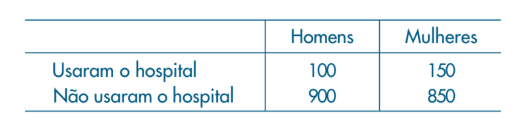

Calcule a proporção de homens entre os indivíduos que usaram o hospital.

1. 0,45
2. 0,5
3. 0,05
4. 0,075
5. 0,1

QUESTÃO 35  
A frequência relativa é:

1. Número total de observações
2. Proporção de cada categoria
3. Soma das frequências
4. Média dos valores
5. Desvio dos dados

RESPOSTA: B  
A frequência relativa equivale a proporção de cada categoria dentro de uma tabela de contingência

QUESTÃO 36  
Uma entidade realizou um teste de proficiência da língua inglesa com seus gerentes. A entidade deseja saber o seguinte:  
I. A média das notas dos gerentes.  
II. A distribuição da frequência de cada nota dos gerentes.  
III. A proficiência do idioma entre os diretores que possuem características semelhantes aos gerentes.  
Ao utilizar a estatística descritiva, foi possível obter as seguintes informações:

1. I, somente.
2. I e II, somente.
3. I e III, somente.
4. II e III, somente.
5. I, II e III.

RESPOSTA: B  
QUESTÃO 37  
Responda verdadeiro (V) ou falso (F):  
1) Suponha duas amostras colhidas de uma mesma população, sendo uma de tamanho 100 e outra de tamanho 200. Então, a amostra de tamanho maior é mais representativa da população.  
2) Duas variáveis com valores diferentes podem apresentar histogramas iguais.  
3) Duas variáveis com box-plot iguais não podem ter valores diferentes.

1. V, F, F
2. F, V, F
3. F, V, V
4. V, V, F
5. F, F, V

RESPOSTA: B

QUESTÃO 38  
Um grupo de pedagogos estuda a influência da troca de escolas no  
desempenho de alunos do ensino fundamental. Como parte do levantamento  
realizado, foi anotado o número de escolas cursadas pelos alunos participantes do estudo.

| ESCOLAS CURSADAS | FREQUÊNCIA |
| --- | --- |
| 1 | 46 |
| 2 | 57 |
| 3 | 21 |
| 4 | 15 |
| 5 | 54 |

Qual a porcentagem dos alunos que cursam mais de uma escola?

1. 76%
2. 30%
3. 82%
4. 54%
5. 23%

RESPOSTA: A  
Quantidade de alunos que cursam mais de uma escola (2 ou mais):  
57 + 21 + 15 + 54 = 147  
Quantidade de alunos total:  
46 + 57 + 21 + 15 + 54 = 193  
147 / 193 = 0.762  
0,762 * 100% = 76%

QUESTÃO 39  
Alunos da Escola de Educação Física foram submetidos a um teste de  
resistência quanto ao número de quilômetros que conseguiram correr sem parar. Qual é a classificação da variável em estudo segundo os tipos de variáveis?

1. Variável quantitativa contínua
2. Variável qualitativa nominal
3. Variável quantitativa discreta
4. Variável qualitativa ordinal
5. Variável qualitativa discreta

RESPOSTA: A  
Variável quantitativa contínua porque a distância é uma grandeza que pode assumir qualquer valor real

QUESTÃO 40  
O tempo de utilização de caixas eletrônicos depende de cada usuário e das  
operações efetuadas. Foram coletadas 10 medidas desse tempo (em minutos): 1,1; 1,7; 1,5; 0,9; 1,3; 1,4; 1,6; 1,7; 1,6; 1,0  
Assinale a alternativa correta:

1. A média de tempo de utilização de caixas eletrônicos é 1,6
2. A amplitude do tempo de utilização de caixas eletrônicos é 0,8
3. A mediana do tempo de utilização de caixas eletrônicos é 1,3
4. A moda do tempo de utilização de caixas eletrônicos é 1,1
5. O desvio padrão do tempo de utilização de caixas eletrônicos é 1,4

RESPOSTA: B  
Valor máximo: 1,7  
Valor mínimo: 0,9  
Amplitude total: 1,7 - 0,9 = 0,8

QUESTÃO 41  
Foram feitas medidas em operários da construção civil a respeito da taxa de  
hemoglobina no sangue (em gramas/cm³):  
15,8; 14,7; 13,5; 12,7; 12,3; 13,5; 15,4; 16,3; 15,2; 12,3; 13,7; 14,1  
Determine o terceiro quartil e a mediana.

1. 16,2 e 15
2. 15,3 e 13,9
3. 15,3 e 12,6
4. 16,2 e 13,9
5. 12,8 e 11,5

RESPOSTA: B  
Ordem crescente:  
12,3; 12,3; 12,7; 13,5; 13,5; 13,7; 14,1; 14,7; 15,2; 15,4; 15,8; 16,3

Como temos 12 valores (n=12), n é par, logo, a mediana é a média entre o 6º e o 7º valores.

12,3; 12,3; 12,7; 13,5; 13,5; 13,7; 14,1; 14,7; 15,2; 15,4; 15,8; 16,3

(13,7+14,1)/2 = 13,9

Para n par, Q3 é a mediana da metade superior.

Metade superior:

14,1; 14,7; 15,2; 15,4; 15,8; 16,3

Q3 = média do 3º e 4º: (15,2+15,4)/2 = 15,3

QUESTÃO 42  
Uma pesquisa coletou os dados de idade de 30 pacientes em uma clínica. Calcule: média, moda e mediana  
34; 27; 45; 51; 39; 63; 29; 48; 56; 31; 40; 36; 42; 54; 47; 50; 38; 33; 60; 52; 37; 43; 35; 46; 49; 55; 32; 41; 44; 30

1. 42,9; 38 e 42,5
2. 43; 42,9 e 43
3. 42,9; não há e 42,5
4. 42,5; não há e 42,9
5. 45; 42,6 e 47

RESPOSTA: C  
Média:  
34+ 27+ 45+ 51+ 39+ 63+ 29+ 48+ 56+ 31+ 40+ 36+ 42+ 54+ 47+ 50+ 38+ 33+ 60+ 52+ 37+ 43+ 35+ 46+ 49+ 55+ 32+ 41+ 44+ 30 = 1287  
1287 / 30 = 42.9  
Moda: não há valor que se repete, logo, não há moda  
Mediana: como n é par (n=30) a mediana é a média entre o 15º e 16º valor  
Ordem crescente:  
27; 29; 30; 31; 32; 33; 34; 35; 36; 37; 38; 39; 40; 41; 42; 43; 44; 45; 46; 47; 48; 49; 50; 51; 52; 54; 55; 56; 60; 63  
(42 + 43) / 2 = 42.5

QUESTÃO 43  
Considere dois conjuntos:  
Conjunto A: 10, 10, 10, 10, 10  
Conjunto B: 5, 8, 10, 12, 15  
Ambos têm média igual a 10. Sobre a dispersão, podemos afirmar que:

1. Ambos têm o mesmo desvio padrão
2. O conjunto A tem maior variabilidade
3. O conjunto B tem maior variabilidade
4. Ambos têm amplitude igual
5. Não é possível comparar

RESPOSTA: C  
No conjunto A, todos os valores são iguais, logo, não há variabilidade.  
No conjunto B, há valores de 5 a 15, então há variabilidade  
Portanto, o conjunto B apresenta maior dispersão

QUESTÃO 44  
Em uma empresa, a maioria dos funcionários ganha entre R$ 2.000 e R$ 3.000, mas alguns diretores ganham acima de R$ 20.000.  
Essa distribuição tende a apresentar:

1. Assimetria negativa
2. Assimetria nula
3. Assimetria positiva
4. Curtose negativa
5. Distribuição uniforme

RESPOSTA: C  
A maioria ganha valores menores, mas há poucos salários muito altos, “puxando” a média para cima. Isso gera uma cauda à direita, chamada de assimetria positiva.

QUESTÃO 45  
Em uma pesquisa com 100 pessoas, podemos afirmar que:

|  | PRATICAM ESPORTE | NÃO PRATICAM ESPORTE |
| --- | --- | --- |
| FEMININO | 10 | 40 |
| MASCULINO | 30 | 20 |

1. 70% praticam esporte
2. 50% são homens
3. 40% das mulheres praticam esporte
4. 60% não praticam esporte
5. Homens praticam menos esporte que mulheres

RESPOSTA: B  
Total de homens: 30 + 20 = 50  
Total geral: 10 + 40 + 30 + 20 =100  
50 / 100 = 0.5 = 50%

# QUESTÕES DE PROBABILIDADE

QUESTÃO 01 (SQL 15)

No lançamento de dois dados perfeitos, qual a probabilidade de que a soma dos resultados obtidos seja igual a 6?  
A) 1/6  
B) 1/9  
C) 5/36  
D) 1/12  
E) 7/36

RESPOSTA: C

Para que a soma seja 6, precisamos das seguintes faces: {(1,5), (2,4), (3,3), (4,2), (5,1)}. E considerando que o espaço amostral do lançamento de dois dados e representado pela multiplicação 6 * 6 = 36, temos a seguinte probabilidade:  
P = 5/36 = 0,1388  
A probabilidade é de 5/36, aproximadamente 13,88% de chance.

QUESTÃO 02

Considerando todos os divisores positivos do numeral 60, determine a probabilidade de escolhermos ao acaso, um número primo.  
A) 1/6  
B) 1/5  
C) 1/4  
D) 1/3  
E) 1/2

RESPOSTA: C

Divisores de 60: (1, 2, 3, 4, 5, 6, 10, 12, 15, 20, 30, 60). Temos um espaço amostral de 12 elementos, dos quais 3 são primos. Portanto, a probabilidade de escolhermos ao acaso, um número primo dentro dos divisores do número 60, será dada por:  
A probabilidade é de 25% de chance.

QUESTÃO 03

Em uma urna existem bolas enumeradas de 1 a 15. Qualquer uma delas possui a mesma chance de ser retirada. Determine a probabilidade de se retirar uma bola com número nas seguintes condições:  
a) par  
b) primo  
c) par ou primo  
d) par e primo

RESPOSTA:

Espaço amostral: (1, 2, 3, 4, 5, 6, 7, 8, 9, 10, 11, 12, 13, 14, 15)

1. No espaço amostral de 15 números, temos 7 números pares.  
   P = 7/15 = 0,466 = 46,6%
2. Temos 6 números primos dentre o espaço amostral de 15 números.  
   P = 6/15 = 0,4 = 40%
3. Número par = 7 possibilidades entre 15  
   Número primo = 6 possibilidades entre 15  
   Par ∩ primo = 1

P(par) + P(primo) – P (par ∩ primo)

QUESTÃO 04

Um teste de múltipla escolha é composto de 12 questões, com 5 alternativas de resposta, sendo que somente uma, é correta. Calcule a probabilidade de uma pessoa, marcando aleatoriamente as 12 questões, acertar metade das respostas.

RESPOSTA:

As chances de acerto são 1 em 5, que corresponde a 0,2 ou 20%.  
As chances de erro são 4 em 5, que corresponde a 08 ou 80%.

Nesse caso, vamos utilizar a fórmula do método binomial:

Vamos considerar acertos (p) e erros (q), então:

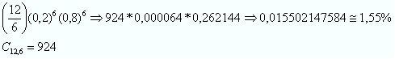

Ele possui 1,55% de chance de acertar metade das questões.

QUESTÃO 05

Uma moeda é lançada 10 vezes. Determine a probabilidade de sair “coroa” 7 vezes.

RESPOSTA:

Chance de sair cara = 1/2

Chance de não sair cara (sair coroa) = ½

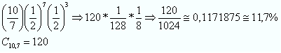

Fonte desta lista:  
https://exercicios.brasilescola.uol.com.br/exercicios-matematica/exercicios-sobre-propriedades-probabilidade.htm

QUESTÃO 06 (ID 13)

(EPCAr 2012) Suponha que a distribuição das idades dos cadetes do 1º ano da Academia da Força Aérea no ano de 2011 esteja representada pelo gráfico seguinte.

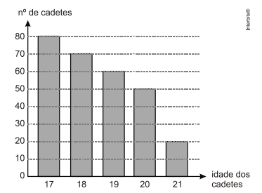

Com base nos dados registrados nesse gráfico, é correto afirmar que, escolhido um aluno ao acaso, a probabilidade de ele ter 20 anos ou 21 anos é igual a  
a) 20%  
b) 25%  
c) 30%  
d) 35%  
e) 40%

RESPOSTA: B

Podemos transformar o gráfico na seguinte tabela:

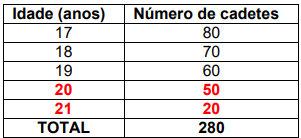

QUESTÃO 07 (ID 14)

No lançamento de dois dados, qual é o número total de possibilidades de resultados e qual é a probabilidade de obtermos soma igual a 8?

1. 36 e 5%
2. 36 e 14%
3. 6 e 5%
4. 5 e 6%
5. 36 e 6%

RESPOSTA: B

Primeiramente, vamos descobrir o número total de possibilidades, pois ele será usado para descobrirmos a probabilidade de obter soma 8:

São dois dados com seis resultados possíveis cada. As combinações entre esses resultados podem ser calculadas multiplicando-se o número de resultados do primeiro pelo do segundo:

6·6 = 36

Também poderíamos ter escrito todas as possibilidades e contado-as, mas esse procedimento gasta mais tempo. Portanto, o número total de possibilidades de resultados é 36.

Para calcular a probabilidade de sair soma 8, devemos procurar as possibilidades de obter tal soma. São elas:

2,6; 3,5; 4,4; 5,3 e 6,2

Sendo 5 o número de possibilidades de obter soma 8, divida esse número pelo número total de possibilidades de resultados:

5 = 0,14  
36

Para transformar isso em porcentagem, basta multiplicar por 100:

0,14·100 = 14%

A probabilidade de sair soma 8 é 14%.

QUESTÃO 08 (ID 15)

Qual é a probabilidade de, no lançamento de 4 moedas, obtermos cara em todos os resultados?

1. 2%
2. 2,2%
3. 6,2%
4. 4%
5. 4,2%

RESPOSTA: C

Primeiramente, é necessário encontrar o número total de possibilidades de resultados:

2·2·2·2 = 16

Posteriormente, devemos encontrar o número de possibilidades de obter cara em todos os resultados. Na realidade, só existe uma possibilidade de que isso aconteça.

Por fim, basta dividir o segundo pelo primeiro:

1 = 0,0625  
16

Multiplicando 6,25 por 100, para obter um percentual, teremos: 6,25%

QUESTÃO 09 (SQL 16)

Duas moedas e dois dados, todos diferentes entre si, foram lançados simultaneamente. Qual é o número de possibilidades de resultados para esse experimento?

1. 146
2. 142
3. 133
4. 144
5. 155

RESPOSTA: D

Para calcular o número de possibilidades de resultados de um experimento nesses moldes, multiplique o número de resultados possíveis de cada objeto em observação. No caso de cada moeda, 2 resultados, e de cada dado, 6 resultados:

2·2·6·6 = 4·36 = 144

ID 17

Qual é o número total de possibilidades de resultado no lançamento de 5 moedas?

1. 2
2. 5
3. 10
4. 24
5. 32

RESPOSTA: E

O número total de resultados que pode ser obtido no lançamento de duas moedas é encontrado multiplicando-se a quantidade de resultados da primeira moeda pela quantidade da segunda e assim por diante. Observe:

2·2·2·2·2 = 32

Portanto, são 32 possibilidades diferentes.

Fonte desta lista:

https://exercicios.mundoeducacao.uol.com.br/exercicios-matematica/exercicios-sobre-probabilidade-possibilidade.htm#resposta-3615

QUESTÃO 10 (SQL 18)

Considere que existe uma urna na qual foram colocadas 200 esferas de plásticos, e cada uma delas possui um pedaço de papel no seu interior. As esferas são coloridas, sendo uma de cada cor. Os pedaços de papel, então, trazem números de 1 a 200, diferentes a cada esfera. Qual das alternativas apresenta a probabilidade de que, ao sortear uma dessas esferas, ela tenha um número divisível por 3 e por 5 ao mesmo tempo?

a)13,0%.  
b)6,5%.  
c)3,25%.  
d)9,75%.  
e) 9,0%

RESPOSTA: B

Para saber quantos divisores de 3 e 5 têm entre 1 a 200, primeiro temos que achar o divido comum:

- MMC de 3 e 5
- 3, 5 | 3
- 1, 5 | 5
- 1, 1
- MMC = 15

Sabendo o fator comum, basta dividi-lo pela quantidade:

- 200/15
- 13 divisores comum

Probabilidade: Quero/Total

- P = 13/200 {divide por dois para ciar na base 10}
- P = 6,5/100
- P = 6,5 %

Fonte desta lista:

https://www.qconcursos.com/questoes-de-concursos/disciplinas/matematica-matematica/probabilidade/questoes?from_omniauth=true&provider=google_oauth2

QUESTÃO 11 (SQL 19)

(Espcex (Aman)) Numa sala existem duas caixas com bolas amarelas e verdes. Na caixa 1, há 3 bolas amarelas e 7 bolas verdes. Na caixa 2, há 5 bolas amarelas e 5 bolas verdes. De forma aleatória, uma bola é extraída da caixa 1, sem que se saiba a sua cor, e é colocada na caixa 2. Após esse procedimento, a probabilidade de extrair uma bola amarela da caixa 2 é igual a:

1. 49/110
2. 51/110
3. 53/110
4. 57/110
5. 61/110

RESPOSTA: C

Temos dois casos a considerar:

1. retirada de uma bola amarela da caixa 1 e de outra amarela da caixa 2

Neste caso temos que a probabilidade de retirar uma bola amarela da primeira caixa é 3/10 e da segunda caixa é 6/11. Como neste caso estamos utilizando a conjunção “E” multiplicamos ambos os resultados:

3/10 · 6/11

2. retirada de uma bola verde da caixa 1 e de uma amarela da caixa 2

Neste caso temos que a probabilidade de retirar uma bola verde da primeira caixa é 7/10 e retirar da segunda caixa uma bola amarela é 5/11. Como neste caso estamos utilizando a conjunção “E” multiplicamos ambos os resultados:

7/10 · 5/11

Desse modo, devemos somar ambos os resultados pois queremos um “OU” outro, a resposta é dada por: 3/10 · 6/11 + 7/10 · 5/11 = 53/110

QUESTÃO 12

(Enem PPL) Para um docente estrangeiro trabalhar no Brasil, ele necessita validar o seu diploma junto ao Ministério da Educação. Num determinado ano, somente para estrangeiros que trabalharão em universidades dos estados de São Paulo e Rio de Janeiro, foram validados os diplomas de 402 docentes estrangeiros. Na tabela, está representada a distribuição desses docentes estrangeiros, por países de origem, para cada um dos dois estados.

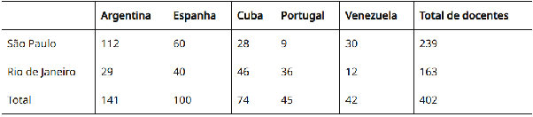

A probabilidade de se escolher, aleatoriamente, um docente espanhol, sabendo-se que ele trabalha em uma universidade do estado de São Paulo é

1. 60/402
2. 60/239
3. 60/100
4. 100/239
5. 279/402

RESPOSTA: B

Perceba que queremos saber a probabilidade de ser um espanhol sabendo que ele trabalha em uma universidade de São Paulo. Se A é o evento “docente espanhol” e B é o evento “trabalha em uma universidade do estado de São Paulo”, então queremos calcular P(A|B).

Sabendo pela tabela, que o número de professores espanhóis que lecionam em São Paulo é: n(A ∩ B) = 60

Além disso, sabemos que o número de professores estrangeiros que trabalham em São Paulo é n(B)= 239.

Dado a fórmula de probabilidade condicional sabemos que:

P(A|B)=(n(A ∩ B))/(n(B))

=60/239

QUESTÃO 13

(UFPR) Um kit para impressão vem com oito cartuchos de tinta, de formato idêntico, para impressora. Nesse kit há dois cartuchos de cada uma das quatro cores diferentes necessárias para uma impressora caseira (ciano, magenta, amarelo e preto). Escolhendo aleatoriamente dois cartuchos desse kit, qual a probabilidade de se obter duas cores distintas?

1. 6/7
2. 1/12
3. 15/56
4. 1/48
5. 1/64

RESPOSTA: A

Como são dois cartuchos de cada uma das quatro cores, não importa qual o cartucho pegar, a probabilidade de pegar outro cartucho da mesma cor é 1/7, pois há apenas mais um cartucho daquela cor dentre os 7 cartuchos que restaram. Desse modo, a probabilidade de pegar dois cartuchos de cores distintas é o complementar, ou seja 1 - 1/7 = 6/7

Fonte desta lista:

https://aprovatotal.com.br/probabilidade-conceitos-calculo-e-exercicios-resolvidos/

QUESTÃO 14

Um morador de uma região metropolitana tem 50% de probabilidade de atrasar-se para o trabalho quando chove na região. Caso não chova, sua probabilidade de atraso é de 25%. Para um determinado dia, o serviço de meteorologia estima em 30% de probabilidade da ocorrência de chuva nessa região. Qual é a probabilidade de esse morador se atrasar para o serviço no dia para o, qual foi dada a estimativa de chuva?

1. 0,075
2. 0,150
3. 0,325
4. 0,600
5. 0,800

RESPOSTA: C

P(A) = probabilidade de chover no dia * probabilidade de se atrasar quando chove + probabilidade de não chover no dia * probabilidade de não se atrasar quando chove.

Aplicando as porcentagens em decimais temos:

P(A) = 0,30 * 0,50 + 0,70 * 0,25

P(A) = 0,15 + 0,175

P(A) = 0,325

QUESTÃO 15

1. 8%.
2. 9%.
3. 11%.
4. 12%.
5. 22%.

RESPOSTA: C

P(A) = 22/200

P(A) = 11/100

QUESTÃO 16

No próximo final de semana, um grupo de alunos participará de uma aula de campo. Em dias chuvosos, aulas de campo não podem ser realizadas. A ideia é que essa aula seja no sábado, mas, se estiver chovendo no sábado, a aula será adiada para o domingo. Segundo a meteorologia, a probabilidade de chover no sábado é de 30% e a de chover no domingo é de 25%. A probabilidade de que a aula de campo ocorra no domingo é de:

1. 5,0%
2. 7,5%
3. 22,5%
4. 30,0%
5. 75,0%

RESPOSTA: C

Para que a aula aconteça no domingo, é preciso que chova no sábado e não chova no domingo. Esse “e” nos mostra que é preciso encontrar o produto entre essas probabilidades. A fórmula muda um pouco:

P(A∩B) = P(A) x P(B)

Já sabemos qual é o nosso P(A), a probabilidade de chover no sábado, que é de 30% ou 0,3. Também sabemos que a chance de chover no domingo é de 25%, o que nos leva a calcular nosso evento B favorável, a probabilidade de não chover no domingo: 100% - 25% = 75%. Nosso P(B), então, é de 75% ou 0,75.

Então, o cálculo será:

P(A∩B) = 0,3 x 0,75

P (A∩B) = 0,225 = 22,5%

Fonte desta lista:

https://www.prepara.com.br/blog/post/questoes-de-probabilidade-enem-com-resolucao

QUESTÃO 17 (NOVA)

Um dado honesto é lançado uma única vez. Consideremos as variáveis X = 1, se o número observado é maior ou igual a 3, X = 0 caso contrário. Seja Y = 1 se o número observado é par, e Y = 0 caso contrário. Calcule as distribuições marginais de X e Y.

1. Distribuições: P(X=0) = 1/3, P(X=1) = 2/3, P(X=0) = 1/2, P(X=1) = 1/2.
2. Distribuições: P(X=0) = 1/3, P(X=1) = 2/3, P(X=0) = 1/2, P(X=1) = 1/3.
3. Distribuições: P(X=0) = 1/2, P(X=1) = 1/2, P(X=0) = 1/2, P(X=1) = 1/2.
4. Distribuições: P(X=0) = 1/3, P(X=1) = 1/2, P(X=0) = 1/2, P(X=1) = 1/2.
5. Distribuições: P(X=0) = 1/2, P(X=1) = 1/2, P(X=0) = 2/3, P(X=1) = 1/3.

RESPOSTA: A

Distribuições marginais de X e Y:

Para X:

• P(X=0)=1/6+1/6= 2/6 ou 1/3

• P(X=1)=2/6+2/6= 4/6 ou 2/3

Para Y:

• P(Y=0)=1/6+2/6= 3/6 ou 1/2

• P(Y=1)=1/6+2/6= 3/6 ou 1/2

QUESTÃO 18 (NOVA)

Um dado honesto é lançado uma única vez. Consideremos as variáveis X = 1, se o número observado é maior ou igual a 3, X = 0 caso contrário. Seja Y = 1 se o número observado é par, e Y = 0 caso contrário. Calcule P(X+Y=1).

1. P(X+Y=1) = 1/3
2. P(X+Y=1) = 1/2
3. P(X+Y=1) = 3/2
4. P(X+Y=1) = 2/3
5. P(X+Y=1) = 5/6

RESPOSTA: B

Calcule P(X+Y=1)

Queremos os pares (X,Y) cuja soma seja 1:

• X=0,Y=1 → prob = 1/6

• X=1,Y=0 → prob = 2/6

Portanto: P(X+Y=1) = 1/6 + 2/6 = 3/6 = 1/2

QUESTÃO 19 (NOVA)

Em um pacote com cinco transistores, dois deles são defeituosos. Os transistores são escolhidos ao acaso devem ser testados, um de cada vez, até que aqueles defeituosos sejam identificados. Qual a probabilidade de haver pelo menos um transistor sem defeito entre os dois defeituosos encontrados?

1. 3/10
2. 2/5
3. 3/5
4. 7/10
5. 4/5

RESPOSTA: C

Probabilidade de se observar um transistor sem defeito entre os dois defeituosos

Ou seja, há um bom (B) entre os dois D, como por exemplo:

D B D → tem bom entre

Basta contar os casos em que entre as posições dos dois defeituosos há pelo menos 1 bom.

Isso acontece quando os defeituosos não estão em posições consecutivas.

• Consecutivos: (1,2), (2,3), (3,4), (4,5) → 4 casos

• Restantes 6 casos têm pelo menos um bom entre os dois D

Logo:

P(há um bom entre os dois defeituosos) = 6/10 = 0,6

QUESTÃO 20 (NOVA) ARRUMAR

Em um pacote com cinco transistores, dois deles são defeituosos. Os transistores são escolhidos ao acaso devem ser testados, um de cada vez, até que aqueles defeituosos sejam identificados. Qual a probabilidade de o primeiro testado ser defeituoso dado que se testou todos?

1. 1/5
2. 1/4
3. 2/5
4. 3/5
5. 3/4

RESPOSTA: B

P(X=1∣X+Y=5)

Porque:  
• X = posição do primeiro defeituoso

• Y = número de testes após o 1º defeituoso até achar o 2º

• Então, X+Y=5 significa que o segundo defeituoso foi achado no último (5º) teste, ou seja, testaram-se todos

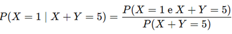

| Defeituosos em | X | Y | X + Y |
| --- | --- | --- | --- |
| (1,5) | 1 | 4 | 5 |
| (2,5) | 2 | 3 | 5 |
| (3,5) | 3 | 2 | 5 |
| (4,5) | 4 | 1 | 5 |

→ Ou seja, há 4 casos onde o segundo defeituoso é encontrado no 5º teste (testaram todos).

• Numerador: casos em que X=1 e X+Y=5:

→ Só o caso (1,5)

→ Então: P(X=1 e X+Y=5)=1/10

• Denominador: casos com X+Y=5:

→ Casos (1,5), (2,5), (3,5), (4,5)

→ Então: P(X+Y=5)=4/10

P(X=1∣X+Y=5)= 1/10 / 4/10 = 1/4

QUESTÃO 21 (NOVA)

Em um pacote com cinco transistores, dois deles são defeituosos. Os transistores são escolhidos ao acaso devem ser testados, um de cada vez, até que aqueles defeituosos sejam identificados. Qual é a probabilidade de serem necessários testar todos os cinco transistores, dado que o primeiro transistor testado foi defeituoso?

1. 1/5
2. 1/4
3. 2/5
4. 1/2
5. 3/5

RESPOSTA: B

Probabilidade de testar todos dado que o 1º testado foi defeituoso

Ou seja: P(X+Y=5∣X=1)

Entre os pares com X=1, temos:

• (1,1): (1,2) → X+Y=2

• (1,2): (1,3) → X+Y=3

• (1,3): (1,4) → X+Y=4

• (1,4): (1,5) → X+Y=5

Total de 4 casos com X=1, e só um com X+Y=5

P(X+Y=5∣X=1) = 1/10 4/10 = 1/4 = 0,25

QUESTÃO 22 (NOVA)

Em um pacote com cinco transistores, dois deles são defeituosos. Os transistores são escolhidos ao acaso devem ser testados, um de cada vez, até que aqueles defeituosos sejam identificados. Qual é a probabilidade de serem necessários testar todos os cinco transistores para encontrar os dois defeituosos?

1. 1/5
2. 1/4
3. 2/5
4. 1/2
5. 3/5

RESPOSTA: C

Probabilidade de testar todos para encontrar os dois defeituosos

Ou seja, P(X+Y=5)

Já vimos que os pares que satisfazem isso são:

• (1,4), (2,3), (3,2), (4,1) → 4 casos

Logo: P(X+Y=5) = 4/10 = 0,4

QUESTÃO 23 (NOVA) ARRUMAR

A Urna A contém 2 bolas vermelhas e 2 bolas verdes. A Urna B contém 3 bolas vermelhas e 1 bola verde. Uma bola é sorteada ao acaso de cada urna. Se ambas as bolas tiverem a mesma cor, uma terceira bola é sorteada da Urna A. Caso contrário, não há terceira extração. Seja X o número de bolas vermelhas sorteadas ao todo, e Y o número total de bolas sorteadas. Qual a probabilidade de ter tido 3 retiradas, dado que saíram 2 bolas vermelhas no experimento?  
A) 1/2

2. 2/3
3. 1
4. 3/4
5. 4/5

RESPOSTA: C

Probabilidade de ter havido 3 retiradas dado que saíram 2 vermelhas

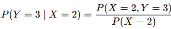

• P(X=2,Y=3) = 1/4

P(Y=3∣X=2) = 1/4 / 1/4 = 1

QUESTÃO 24 (NOVA)  
Um dado honesto é lançado uma única vez. Consideremos as variáveis X = 1, se o número observado é maior ou igual a 3, X = 0 caso contrário. Seja Y = 1 se o número observado é par, e Y = 0 caso contrário.

1. P(X=0) = 1/2, P(X=1) = 1/2

P(Y=0) = 1/2, P(Y=1) = 1/2

2. P(X=0) = 1/3, P(X=1) = 2/3

P(Y=0) = 1/2, P(Y=1) = 1/2

3. P(X=0) = 2/3, P(X=1) = 1/3

P(Y=0) = 1/2, P(Y=1) = 1/2

4. P(X=0) = 2/3, P(X=1) = 1/3

P(Y=0) = 2/3, P(Y=1) = 1/3

5. P(X=0) = 1/3, P(X=1) = 2/3

P(Y=0) = 1/3, P(Y=1) = 2/3

RESPOSTA: B

Distribuições marginais de X e Y

Para X:

• P(X=0)=1/6+1/6=2/6

• P(X=1)=2/6+2/6=4/6

Para Y:

• P(Y=0)=1/6+2/6=3/6

• P(Y=1)=1/6+2/6=3/6

QUESTÃO 25 (NOVA)

Um dado honesto é lançado uma única vez. Consideremos as variáveis X = 1, se o número observado é maior ou igual a 3, X = 0 caso contrário. Seja Y = 1 se o número observado é par, e Y = 0 caso contrário. A probabilidade de P(X+Y=1) é igual a:

1. 1/3
2. 1/2
3. 2/3
4. 1/6
5. 5/6

RESPOSTA: B

Calcule P(X+Y=1)

Queremos os pares (X,Y) cuja soma seja 1:

• X=0,Y=1 → prob = 1/6

• X=1,Y=0 → prob = 2/6

Portanto:

P(X+Y=1)=1/6+2/6=3/6=1/2

QUESTÃO 26 (NOVA)

Uma moeda honesta é lançada 4 vezes. Qual é o número de sequências possíveis?  
A) 16

2. 8
3. 32
4. 4
5. 64

RESPOSTA: A

Como a moeda é lançada 4 vezes, cada lançamento tem dois resultados possíveis: K (cara) ou C (coroa).

Logo, o total de sequências possíveis é 2^4=16

QUESTÃO 27 (NOVA) ARRUMAR

A tabela abaixo apresenta a distribuição conjunta das variáveis aleatórias X e Y:

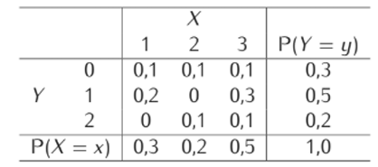

A partir dele, calcule E(X), E(Y), Var(X), Var(Y), respectivamente.

1. 2,2; 0,9; 0,76; 0,49
2. 2,2; 0,9; 0,76; 0,69
3. 2,2; 0,9; 0,56; 0,49
4. 2,0; 0,9; 0,76; 0,49
5. 2,2; 1,0; 0,76; 0,49

RESPOSTA: A

E(X) = 1 × 0,3 + 2 × 0,2 + 3 × 0,5 = 2,2

E(X²) = 1² × 0,3 + 2² × 0,2 + 3² × 0,5 = 5,6

Var(X) = 5,6 − (2,2)² = 0,76

E(Y) = 1 × 0,5 + 2 × 0,2 = 0,9

E(Y²) = 1² × 0,5 + 2² × 0,2 = 1,3

Var(Y) = 1,3 − (0,9)² = 0,49

QUESTÃO 28 (NOVA)

Em uma urna existem bolas enumeradas de 1 a 15. Qualquer uma delas possui a mesma chance de ser retirada. Determine a probabilidade de se retirar uma bola com número par.

1. 1/2
2. 7/15
3. 8/15
4. 3/5
5. 2/3

RESPOSTA: B

Espaço amostral: (1, 2, 3, 4, 5, 6, 7, 8, 9, 10, 11, 12, 13, 14, 15)

No espaço amostral de 15 números, temos 7 números pares.  
P = 7/15 = 0,466 = 46,6%

QUESTÃO 29 (NOVA)

Em uma urna existem bolas enumeradas de 1 a 15. Qualquer uma delas possui a mesma chance de ser retirada. Determine a probabilidade de se retirar uma bola com número primo.

1. 1/4
2. 1/3
3. 2/5
4. 3/5
5. 7/15

RESPOSTA: C

Espaço amostral: (1, 2, 3, 4, 5, 6, 7, 8, 9, 10, 11, 12, 13, 14, 15)

Temos 6 números primos dentre o espaço amostral de 15 números.  
P = 6/15 = 0,4 = 40%

QUESTÃO 30 (NOVA)

Em uma urna existem bolas enumeradas de 1 a 15. Qualquer uma delas possui a mesma chance de ser retirada. Determine a probabilidade de se retirar uma bola com número par ou primo.

1. 2/3
2. 3/5
3. 7/15
4. 4/5
5. 13/15

RESPOSTA: D

Número par = 7 possibilidades entre 15  
Número primo = 6 possibilidades entre 15  
Par ∩ primo = 1

P(par) + P(primo) – P (par ∩ primo)

7/15 + 6/15 - 1/15 = 12/15 = 4/5

QUESTÃO 31 (NOVA)

Em uma urna existem bolas enumeradas de 1 a 15. Qualquer uma delas possui a mesma chance de ser retirada. Determine a probabilidade de se retirar uma bola com número par e primo.  
A) 1/3  
B) 1/5  
C) 2/15  
D) 1/15  
E) 1/20  
RESPOSTA: D  
Dentro do intervalo dado, temos um único número que satisfaz a condição de ser par e primo ao mesmo tempo, que é o número 2. Portanto, temos a seguinte probabilidade:  
P = 1/15

QUESTÃO 32 (NOVA) ARRUMAR

Um teste de múltipla escolha é composto de 12 questões, com 5 alternativas de resposta, sendo que somente uma é correta. Calcule a probabilidade, em porcentagem aproximada, de uma pessoa, marcando aleatoriamente as 12 questões, acertar metade das respostas.  
A) 1,5625%  
B) 0,8%  
C) 1,55%  
D) 0,1%  
E) 25%  
RESPOSTA: C  
As chances de acerto são 1 em 5, que corresponde a 0,2 ou 20%.  
As chances de erro são 4 em 5, que corresponde a 08 ou 80%.

Vamos considerar acertos (p) e erros (q), então:

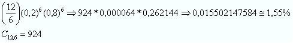

Ele possui 1,55% de chance de acertar metade das questões.

QUESTÃO 33

Uma moeda é lançada 10 vezes. Determine a probabilidade aproximada (em porcentagem) de sair “coroa” 7 vezes.  
A) 4,40%  
B) 11,72%  
C) 12,50%  
D) 25%  
E) 20,51%  
RESPOSTA: B  
Chance de sair cara = 1/2  
Chance de não sair cara (sair coroa) = ½

(10/7) . (1/2)7 . (1/2)3 = 120 . 1/128 . 1/8 = 120/1024 = 11,7%

QUESTÃO 34

Se P(A)=0,30, P(B)=0,40 e A e B são independentes, então P(A∩B) é:

1. 0,12
2. 0,70
3. 0,34
4. 0,10
5. 0,75

RESPOSTA: A

Para eventos independentes,

P(A∩B)= P(A) . P(B) = 0,30 · 0,40 = 0,12.

QUESTÃO 35

Dois eventos A e B são independentes se, e somente se:  
A) P(A|B)=P(B|A)  
B) P(A∩B)=P(A)+P(B)  
C) P(A∩B)=P(A)P(B)  
D) P(A|B)=P(A)+P(B)  
E) P(A∪B)=P(A)P(B)  
RESPOSTA: C  
A definição adotada no capítulo de probabilidades é:  
A e B são independentes ⇔ P(A∩B)=P(A) . P(B).

QUESTÃO 36

Em termos de A e B com P(B)>0, o Teorema de Bayes (versão simples) fornece P(A|B) como:  
A) P(A|B)=P(A)P(B)  
B) P(A|B)=P(A∩B)/P(A)  
C) P(A|B)=P(A∩B)/P(B)=P(A)·P(B|A)/P(B)  
D) P(A|B)=P(B|A)  
E) P(A|B)=1-P(B|A)  
RESPOSTA: C  
P(A|B)=P(A∩B)/P(B).  
Como P(A∩B)=P(A)P(B|A),  
resulta P(A|B)=P(A)·P(B|A)/P(B).

QUESTÃO 37

Num experimento binomial com parâmetros n e p, a probabilidade de X=k sucessos é:

RESPOSTA: B

Pelo modelo binomial b(n,p), a função de probabilidade é

b(k;n,p)=C(n,k)p^k q^{n-k}, com q=1-p, para k=0,1,…,n.

QUESTÃO 38

Um telefone recebe, em média, 5 chamadas por minuto. Supondo um modelo de Poisson, qual é a probabilidade de não receber chamadas em 1 minuto?  
A) e^{-5}  
B) 1-e^{-5}  
C) 5e^{-5}  
D) e^{-1/5}  
E) (1/5)e^{-5}  
RESPOSTA: A  
No modelo Poisson(λ), P(N=k)=e^{-λ} . λ^k/k!  
Para k=0 e λ=5: P(N=0)=e^{-5}.

QUESTÃO 39

Uma moeda é lançada 5 vezes (p=0,5 de cara). Seja X o número de caras. Qual é P(X=3)?  
A) 5/32  
B) 10/32  
C) 1/2  
D) 3/8  
E) 15/32  
RESPOSTA: B  
X~b(5; 0,5)  
Então P(X=3) = C(5,3) . (0,5)^3 . (0,5)^{2} = C(5,3) . (0,5)^5 = 10/32

QUESTÃO 40

Uma variável Z segue a distribuição normal padrão N(0,1), e uma variável Y segue a distribuição qui-quadrado com ν graus de liberdade, sendo Z e Y independentes. A variável t é definida como t = Z/√(Y/ν). A distribuição da variável t é:  
A) Normal padrão  
B) Qui-quadrado com ν g.l.  
C) t de Student com ν g.l.  
D) F com (1,ν) g.l.  
E) Uniforme(0,1)  
RESPOSTA: C  
A definição da distribuição t de Student com ν graus de liberdade é exatamente:  
t = Z/√(Y/ν)

QUESTÃO 41

Se X ~ N(μ, σ²), então E(X) e Var(X) são, respectivamente:

1. μ e σ
2. 0 e 1
3. μ e σ²
4. σ e μ²
5. μ² e σ²

RESPOSTA: C

No modelo normal, os momentos básicos são E(X)=μ e Var(X)=σ²

QUESTÃO 42

Se X ~ N(1000, 20²), qual é P(X < 980)? (Use a padronização Z=(X-μ)/σ e Φ(-1)=0,1587.)  
A) 0,8413  
B) 0,5000  
C) 0,1587  
D) 0,0228  
E) 0,9772  
RESPOSTA: C  
Z=(980-1000)/20 = -20/20 = -1.  
Logo P(X<980) = P(Z<-1) = Φ(-1) = 0,1587.

QUESTÃO 43

Um lote tem 20 peças, das quais 5 são defeituosas. Escolhem-se 4 peças ao acaso, sem considerar a ordem. Qual é a probabilidade de obter exatamente 2 defeituosas?  
A) C(5,2) · C(15,2) / C(20,4)  
B) C(5,2) · C(15,2) / C(20,2)  
C) C(5,4) / C(20,4)  
D) C(15,2) / C(20,4)  
E) C(5,2) / C(20,4)  
RESPOSTA: A  
O espaço amostral tem C(20,4) amostras possíveis (sem ordem).  
Casos favoráveis: escolher 2 defeituosas entre 5 e 2 não defeituosas entre 15: C(5,2) · C(15,2)  
Logo, P = C(5,2) · C(15,2) / C(20,4)  
Princípio multiplicativo com combinações.

QUESTÃO 44

Suponha que P(A∩B)=0,20 e P(B)=0,50 (com P(B)>0). Qual é P(A|B)?  
A) 0,10  
B) 0,20  
C) 0,30  
D) 0,40  
E) 0,70  
RESPOSTA: D  
P(A|B) = P(A∩B) / P(B)  
P(A|B) = 0,20/0,50 = 0,40

QUESTÃO 45

Dois eventos A e B são independentes se, e somente se:  
A) P(A|B) = P(B|A)  
B) P(A∪B) = P(A)+P(B)  
C) P(A∩B) = P(A)P(B)  
D) P(A∩B) = 0  
E) P(A) = 1 − P(B)  
RESPOSTA: C  
A e B são independentes quando a ocorrência de um não altera a probabilidade do outro.  
Uma condição equivalente é P(A∩B) = P(A) . P(B)

QUESTÃO 46

Se P(B)>0, a probabilidade condicional de A dado B é definida por:  
A) P(A|B)=P(A)P(B)  
B) P(A|B)=P(A∩B)/P(B)  
C) P(A|B)=P(B∩A)/P(A)  
D) P(A|B)=P(A)+P(B)  
E) P(A|B)=1−P(A∩B)  
RESPOSTA: B  
Pela definição, quando P(B)>0:  
P(A|B) = P(A∩B) / P(B)

QUESTÃO 47

Em uma universidade, há 200 alunos distribuídos entre cursos. No curso de Estatística, há 30 alunos, dos quais 20 são mulheres. Se um aluno é escolhido ao acaso e sabe-se que ele está matriculado em Estatística, qual é P(mulher | Estatística)?  
A) 1/10  
B) 1/3  
C) 2/3  
D) 3/5  
E) 20/200  
RESPOSTA: C  
P(mulher | Estatística) = (nº de mulheres em Estatística)/(total em Estatística) = 20/30 = 2/3.

QUESTÃO 49  
Se P(A) = 0,30, qual é P(A^c) (o complementar de A)?  
A) 0,30  
B) 0,70  
C) 1,30  
D) 0,15  
E) 0,60  
RESPOSTA: B  
P(A) + P(A^c) = 1.  
Logo, P(A^c) = 1 - 0,30 = 0,70.

QUESTÃO 51
Uma v.a. discreta X tem P(X=0) = 0,2, P(X=1) = 0,5 e P(X=2) = 0,3. Calcule E(X) e Var(X).
A) E(X)=1,1 e Var(X)=0,49
B) E(X)=1,0 e Var(X)=0,70
C) E(X)=1,3 e Var(X)=0,49
D) E(X)=1,1 e Var(X)=0,70
E) E(X)=1,0 e Var(X)=0,49
RESPOSTA: A
E(X) = Σ x p(x) = 0*0,2 + 1*0,5 + 2*0,3 = 0,5 + 0,6 = 1,1.
E(X^2) = Σ x^2 p(x) = 0 + 1*0,5 + 4*0,3 = 0,5 + 1,2 = 1,7.
Var(X) = E(X^2) -
$$E(X)$$
^2 = 1,7 - (1,1)^2 = 1,7 - 1,21 = 0,49.

QUESTÃO 52  
Em 100 intervalos de tempo, observou-se o número de eventos N com a seguinte frequência: n0=20, n1=30, n2=25, n3=25 (e nenhum intervalo com 4 ou mais eventos). Adote o modelo de Poisson e estime lambda pela média amostral. Em seguida, calcule P(N=0) pelo modelo ajustado.  
A) lambda =1,25 e P(N=0)=0,286  
B) lambda =1,55 e P(N=0)=0,212  
C) lambda =1,55 e P(N=0)=0,788  
D) lambda =1,75 e P(N=0)=0,174  
E) lambda =2,05 e P(N=0)=0,129  
RESPOSTA: B  
Estimativa por média:  
lambda = (0*20 + 1*30 + 2*25 + 3*25)/100 = (30+50+75)/100 = 155/100 = 1,55.  
No modelo de Poisson, P(N=0)=e^{-lambda } = e^{-1,55} ≈ 0,212.

RESPOSTA: C  
Se os eventos A e B são mutuamente exclusivos  
P(AUB) = P(A) + P(B)  
0,8=0,5+x  
0,8-0,5=x  
x = 0,3

QUESTÃO 55  
A probabilidade de um evento impossível é:

1. 1
2. 0,5
3. 0
4. Negativa
5. Maior que 1

RESPOSTA: C

QUESTÃO 56  
O complemento de um evento A é:

1. Outro evento independente
2. Evento impossível
3. Tudo que não é A
4. Evento certo
5. Interseção com A

RESPOSTA: C

QUESTÃO 57  
Considere A o evento: sair um número par. Calcule P(A) ao rolar um dado justo

1. 1/6
2. 1/4
3. 1/36
4. 2/6
5. 1/2

RESPOSTA: E  
Números pares em um dado: 2, 4, 6  
P(A)= 3/6 = 0,5

QUESTÃO 58  
Seja X uma variável aleatória discreta que segue o modelo Uniforme com os valores no conjunto {1, 2, 3,…, 10}. Calcule P(X<= 9 | X>=6)

1. 0,9
2. 0,45
3. 0,4
4. 0,8
5. 0,3

RESPOSTA: D  
P(X<=9 | X>=6) = P(X<=9 | X>=6) / P(X>=6) = 4/5 = 0.8

QUESTÃO 59  
Seja X uma variável que segue o modelo Binomial com n=15 e p=0,4. Calcule P(X>=4)

1. 2,52x10^-5
2. 3,54x10^-5
3. 1,47x10^5
4. 2,78x10^-4
5. 1,98x10^4

QUESTÃO 60  
Uma companhia produz circuitos em três fábricas, I, II e III. A fábrica I produz 40% dos circuitos, enquanto a II e a III produzem 30% cada uma. As probabilidades de que um circuito integrado produzido por essas fábricas não funcione são 0,01, 0,04 e 0,03, respectivamente. Escolhido um circuito da produção conjunta das três fábricas, qual a probabilidade de o mesmo não funcionar?

1. 0,03
2. 0,4
3. 0,025
4. 0,35
5. 0,25

RESPOSTA: C  
Eventos: I,II,III (fábrica)  
D (defeituoso)  
P(I): 0,4; P(II): 0,3; P(III): 0,3  
P(D|I): 0,01; P(D|II): 0,04; P(D|III): 0,03  
Assim, P(D) = P(I) * P(D|I) + P(II) * P(D|II) + P(III) * P(D|III)  
P(D) = 0,4*0,01 + 0,3*0,04 + 0,3*0,03 = 0,025

QUESTÃO 61  
Em uma fábrica de parafusos, as máquinas A, B e C produzem 25%, 35% e 40% do total, respectivamente. Da produção de cada máquina 5%, 4% e 2%, respectivamente, são parafusos defeituosos. Escolhe-se ao acaso um parafuso e verifica-se que é defeituoso. Qual a probabilidade de que o parafuso venha da máquina A?

1. 0,025
2. 0,40
3. 0,2
4. 0,0345
5. 0,512

P(D∣A)=0,05  
P(D∣B)=0,04  
P(D∣C)=0,02

Teorema de Bayes:  
P(A∣D) = ( P(D∣A) * P(A) ) / P(D)

QUESTÃO 62  
Uma moeda é lançada duas vezes e observam-se as faces obtidas. Descreva o espaço amostral considerando K para coroa e C para cara

1. {C,K}
2. {C, CK, K}
3. (CK, KC, K}
4. {CC, CK, KC, KK}
5. {CC, KC, CK, KK, C, K}

RESPOSTA: D  
As combinações possíveis em dois lançamentos de uma moeda são:  
CARA, CARA  
CARA, COROA  
COROA, CARA  
COROA, COROA

QUESTÃO 63  
Dois dados são lançados simultaneamente e estamos interessados na soma das faces observadas. Considerando A o evento “Saírem apenas somas pares”, calcule P(A)

1. 0,02
2. 0,5
3. 0,36
4. 0,9
5. 0,18

RESPOSTA: B  
Os resultados para somas pares são:  
Opção 1= Dado 1: par + Dado 2: par = soma par  
Opção 2= Dado 1: ímpar + Dado 2: ímpar = soma par

Assim, a probabilidade da primeira opção é  
3/6 * 3/6 = 9/36  
E a probabilidade da segunda opção é  
3/6 * 3/6 = 9/36

Somando as duas opções:  
9/36 + 9/36 = 18/36 = 0,5

QUESTÃO 64  
Um determinado tipo de bateria é produzido por duas linhas de montagem, L₁ e L2. A linha L₁, possui uma capacidade de produzir quatro vezes mais baterias do que a linha L2. Sabe-se, através do controle de qualidade que 2% das baterias produzidas por L₁ são defeituosas e 5% das baterias produzidas por L2 são defeituosas. Todas as baterias das duas linhas são enviadas a um depósito central.  
Se uma bateria for retirada aleatoriamente desse depósito, a probabilidade de essa bateria ser defeituosa é

1. 0,016
2. 0,018
3. 0,020
4. 0,024
5. 0,026

RESPOSTA: E  
Como L1 possui capacidade de produzir quatro vezes mais baterias do que a linha L2 e sabendo que a soma das probabilidades deve ser 1,  
P(L1) = 4x  
P(L2) = x  
x + 4x = 1  
5x = 1  
x = 0,2  
P(L1) = 0,8 e P(L2) = 0,2  
E sabendo que 0,02 das baterias produzidas por L₁ são defeituosas e 0,05 das baterias produzidas por L2 são defeituosas.  
A probabilidade da bateria ser defeituosa é  
0,02 x 0,8 + 0,2 x 0,05 = 0,026  
QUESTÃO 65  
Ao lançar um dado honesto uma vez, qual é o espaço amostral?

1. {0,1,2,3,4,5}
2. {1,2,3,4,5,6}
3. {1,2,3,4,5}
4. {2,3,4,5,6,7}
5. {cara, coroa}

RESPOSTA: B  
O espaço amostral é o conjunto de todos os resultados possíveis. Num dado, os resultados possíveis são: {1,2,3,4,5,6}

QUESTÃO 66  
Uma urna tem 3 bolas vermelhas (V) e 2 bolas azuis (A). Ao retirar uma bola da urna e observar sua cor, qual o espaço amostral?

1. {V, A}
2. {V1, V2, V3, A1, A2}
3. {1,2,3,4,5}
4. {V, V, V, A, A}
5. {V∩A, V∪A}

RESPOSTA: A  
Ao observar apenas a cor, os resultados possíveis são: bola vermelha (V) ou bola azul (A)

QUESTÃO 67  
Ao lançar dois dados honestos, quantos resultados possíveis existem no espaço amostral?

1. 6
2. 12
3. 18
4. 72
5. 36

RESPOSTA: E  
Cada dado possui 6 possibilidades, como são dois dados: 6 * 6 = 36 resultados possíveis

QUESTÃO 68  
Pelo axioma, qual afirmação é sempre verdadeira para qualquer evento A?

1. P(A) pode ser negativa
2. P(A) pode ser maior que 1
3. 0 ≤ P(A) ≤ 1
4. P(A)=1 somente se A é impossível
5. P(A)=0 somente se A é certo

RESPOSTA: C  
Para qualquer evento A, sua probabilidade sempre fica entre 0 e 1.

QUESTÃO 69  
Se P(A)=0,62, qual é a probabilidade do complemento de A?

1. 0,38
2. 0,62
3. 1,62
4. 0,34
5. 0,28

RESPOSTA: A  
O complemento de A:  
1 - P(A) = 1 - 0,62 = 0,38

QUESTÃO 70  
Se P(A)=0,5, P(B)=0,4 e P(A∩B)=0,2, então qual é a P(A∪B)?

1. 0,70
2. 0,94
3. 0,21
4. 0,39
5. 0,40

RESPOSTA: A  
Usando a fórmula: P(A∪B)=P(A)+P(B)−P(A∩B)  
P(A∪B)= 0,5 + 0,4 - 0,2  
P(A∪B) = 0,7

QUESTÃO 71  
Considere que P(A)=0,5 e P(B|A)=0,8. Calcule a P(A∩B):

1. 0,4
2. 0,8
3. 0,3
4. 1,3
5. 0,1

RESPOSTA: A  
Aplicando a fórmula: P(A∩B)=P(A)·P(B|A)  
P(A∩B)= 0,5 * 0,8 = 0,4

QUESTÃO 72  
Uma doença atinge apenas 2% da população. Sabe-se que o teste dessa doença dá positivo em 95% dos doentes e falso positivo em 5% dos não doentes. Considerando que uma pessoa testou positivo, qual a probabilidade dela estar doente?

1. 0,28
2. 0,02
3. 0,95
4. 0,52
5. 0,98

RESPOSTA: A  
Dados do problema  
Probabilidade de estar doente: P(D)=0,02  
Probabilidade de não estar doente: P(D^c)=0,98  
Teste positivo se a pessoa está doente: P(+∣D)=0,95  
Falso positivo: P(+∣D^c)=0,05  
Probabilidade que queremos encontrar (probabilidade de estar doente sabendo que o teste deu positivo): P(D∣+)

Agora vamos aplicar Bayes  
P(D∣+)=P(+∣D)P(D) / P(+)  
P(D∣+)=0,95⋅0,02 / 0,068  
P(D∣+)=0,019 / 0,068  
P(D∣+) = 0,279 = 0,28

QUESTÃO 73  
Considere uma urna contendo três bolas pretas e cinco bolas vermelhas. Retire duas bolas da urna, sem reposição e calcule a probabilidade de sair uma bola preta na primeira e segunda extrações

1. 0,521
2. 0,375
3. 0,286
4. 0,107
5. 0,518

RESPOSTA: D  
Temos 3 bolas pretas (P) e 5 bolas vermelhas (V), no total, 8 bolas  
Existem 3 bolas pretas em 8 bolas totais, então a probabilidade de sair 1 bola preta: 3/8 = 0,375  
Como não há reposição, agora restam 2 bolas pretas e 7 totais, então a probabilidade da segunda ser preta (sabendo que a primeira foi preta): 2/7 = 0,286  
Multiplicando as probabilidades: 0,375 * 0,286 = 0,1071

# QUESTÕES DE INFERÊNCIA ESTATÍSTICA

QUESTÃO 1 (FINALIZAR)

Um pesquisador está analisando o impacto da taxa de juros sobre o consumo das famílias em uma amostra de 40 municípios brasileiros. Ele calcula a média do consumo mensal per capita como R$ 1.850, com desvio padrão de R$ 300. O pesquisador deseja testar a hipótese de que o consumo médio nacional é igual a R$ 2.000, utilizando um nível de significância de 5%.  
Com base nessas informações, assinale a alternativa correta:  
A) O teste de hipótese deve ser bilateral, pois o pesquisador quer verificar se o consumo é diferente de R$ 2.000.  
B) O valor da estatística de teste será positivo, pois a média amostral é maior que a média hipotética.  
C) A hipótese nula será rejeitada se o valor-p for maior que 0,05.  
D) Adotando como hipótese de que o desvio padrão populacional seja conhecido e é igual a R$ 300 (igual ao amostral), então o teste deve usar a distribuição t de Student.  
E) O intervalo de confiança de 95% para a média populacional será maior que R$ 2.000.

QUESTÃO 2

Uma população tem μ=50 e σ=10. Retira-se uma amostra aleatória de tamanho n=36. Usando o TLC, aproxime P(X̄ > 52). (Use Φ(1,2)=0,8840.)  
A) 0,1160  
B) 0,8840  
C) 0,1587  
D) 0,5000  
E) 0,2410  
RESPOSTA: A  
Pelo TLC, X̄ ≈ N(50, 10²/36).  
Desvio-padrão de X̄: 10/6 = 1,6667.  
Padronizando: z = (52-50) / 1,6667 = 1,2.  
Assim P(X̄>52) = P(Z>1,2)= 1 - Φ(1,2) = 1 - 0,8840 = 0,1160.

QUESTÃO 3

Deseja-se escolher n tal que P(|X̄-μ| ≤ ε) = γ, assumindo σ² conhecida. Se σ=4, ε=0,5 e γ=0,95 (use z_γ = 1,96), qual n o livro obtém pela fórmula  
n = σ² . z_γ² / ε² (arredonde para cima)?  
A) 62  
B) 123  
C) 246  
D) 16  
E) 400  
RESPOSTA: C  
n = (σ² . z_γ²)/(ε²) = (16·(1,96)²) / (0,25)  
(1,96)² = 3,8416  
16·3,8416 = 61,4656  
61,4656 / 0,25 = 245,8624  
Arredondando para cima: n=246.

QUESTÃO 4

Pelo Teorema Limite Central, se a população tem média μ e variância σ² finita, então para n grande a média amostral X̄ é aproximadamente:  
A) N(0,1)  
B) N(μ, σ²)  
C) N(μ, σ²/n)  
D) b(n, μ)  
E) Poisson(σ²/n)  
RESPOSTA: C  
O TLC afirma que, para n grande, a distribuição amostral de X̄ aproxima-se de N(μ, σ²/n).

QUESTÃO 5

QUESTÃO 7  
Se (X1,…,Xn) é uma AAS(Amostra Aleatória Simples) de uma população com média μ e variância σ², qual é Var(X̄)?  
A) σ²  
B) σ²/n  
C) σ/√n  
D) σ²/(n−1)  
E) nσ²  
RESPOSTA: B  
Para uma AAS, Var(X̄)=σ²/n

QUESTÃO 8

Deseja-se que P(|X̄−μ| ≤ ε)=γ, com σ conhecida. A expressão que relaciona n, σ, ε e zγ é:  
A) n = (σ zγ)/ε  
B) n = (σ² zγ)/ε²  
C) n = (σ² zγ²)/ε²  
D) n = (ε² zγ²)/σ²  
E) n = (σ zγ²)/ε²  
RESPOSTA: C  
Padronize: Z = (X̄−μ)√n/σ ~ N(0,1)  
Imponha P(|Z|≤zγ)=γ ⇒ zγ = ε√n/σ  
Então √n = (σ zγ)/ε ⇒ n = (σ² zγ²)/ε²

QUESTÃO 9

QUESTÃO 10

QUESTÃO 11

Em um teste de hipóteses, o erro de tipo I corresponde a:  
A) Aceitar H0 quando H0 é falsa  
B) Rejeitar H0 quando H0 é verdadeira  
C) Aceitar H1 quando H1 é falsa  
D) Rejeitar H1 quando H1 é verdadeira  
E) Sempre rejeitar H0  
RESPOSTA: B  
Erro tipo I (α): rejeitar H0 mesmo quando H0 é verdadeira.  
Erro tipo II (β): não rejeitar H0 quando H0 é falsa.

QUESTÃO 12

No teste H0: p = 0,60 vs H1: p<0,60, com n = 200 e α = 0,05, a região crítica pode ser expressa como p̂ ≤ p̂c. Qual é p̂c aproximado (use zα = −1,645)?

1. 0,571
2. 0,544
3. 0,520
4. 0,600
5. 0,456

RESPOSTA: B

Sob H0, p̂ ≈ N(p0, p0(1−p0) / n), com p0 = 0,60

DP(desvio padrão) = √(0,60 · 0,40/200)=√(0,24 / 200)=√0,0012 ≈ 0,03464.

p̂c(valor crítico) = 0,60 + (−1,645) · 0,03464 ≈ 0,543

Arredondando: p̂c ≈ 0,544

QUESTÃO 13 (NOVA)

QUESTÃO 14  
Uma variável aleatória X tem distribuição normal, com média 100 e desvio padrão 10. Qual a P(90 < X < 110)?

1. 0,6826
2. 0,8974
3. 0,6954
4. 0,1495
5. 0,3248

RESPOSTA: A  
X∼N(μ=100, σ=10)  
Assim, Z = (X−μ) / σ  
Para 90: (90 - 100)/10 = -1  
Para 110: (110-100)/10 =1  
Dessa forma,  
P(90<X<110) = P(−1<Z<1)  
Usando a Tabela Normal:  
P(Z<-1) = 0,1587  
P(Z<1) = 0,8413  
0,8413 - 0,1587 = 0,6826

1. 0,68
2. 0,841
3. 0,95
4. 0,997
5. 0,50

QUESTÃO 16  
O peso dos pacotes produzidos por uma máquina segue distribuição normal com desvio padrão 10 g.  
Em quanto deve ser regulada a média μ para que apenas 10% dos pacotes tenham peso inferior a 500 g?  
(Dado: Z 0,10=−1,28)

1. 500 g
2. 505 g
3. 510 g
4. 512,8 g
5. 520 g

RESPOSTA: D  
X: peso dos pacotes produzidos  
X ~ N(μ,10)

P(X<500) = ?

Padronização:  
Z = (X - μ) / σ  
Usando Z 0,10 = -1,28 e aplicando os dados na fórmula acima, temos:  
-1,28 = (500-μ) / 10  
-1,28 x 10 = 500 - μ  
-12,8 = 500 - μ  
-12,8 - 500 = - μ  
-512,8 = -μ  
μ = 512,8  
Conclui-se que a média deve ser regularizada em 512,8g para que apenas 10% dos pacotes tenham peso inferior a 500 g

QUESTÃO 17  
A associação dos proprietários de indústrias metalúrgicas está muito preocupada com o tempo perdido com acidentes de trabalho, cuja média, nos últimos tempos, tem sido da ordem de 60 horas/homem por ano e desvio padrão de 20 horas/homem.  
Tentou-se um programa de prevenção de acidentes, após o qual foi tomada uma amostra de nove indústrias e medido o número de horas/homens perdidas por acidente, que foi de 50 horas. Você diria, no nível de 5%, que há evidência de melhoria?

1. Sim, pois Z=−1,50<−1,645
2. Sim, pois Z=−2,00
3. Não, pois Z=−1,50>−1,645
4. Não, pois Z=−0,75
5. Sim, pois Z=−0,5

RESPOSTA: C  
Hipóteses:  
H0: μ = 60  
H1: μ < 60  
Fórmula: (Considere Xˉ a média amostral)  
Z = (Xˉ - μ) / (σ / raiz quadrada de n)  
Substituindo os valores:  
Z = (50 - 60) / (20/3) = -1.5  
Considerando Z= -1,5 e o valor crítico (5% unilateral) = -1,645  
Como −1,50 > −1,645, não há evidências suficientes de melhoria.

QUESTÃO 18  
O salário médio dos empregados das indústrias siderúrgicas de um país é de 2,5 salários mínimos, com um desvio padrão de 0,5 salários mínimos. Uma indústria é escolhida ao acaso e desta é escolhida uma amostra de 49 empregados, resultando um salário médio de 2,3 salários mínimos. Podemos afirmar que esta indústria paga salários inferiores à média nacional, com o nível de 5%?

1. Não, pois Z=−1,64
2. Sim, pois Z=−2,80
3. Não, pois Z=−0,40
4. Sim, pois Z=2,80
5. Não, pois o valor-p > 0,05

RESPOSTA: B  
Hipóteses:  
H0: μ=2,5  
H1: μ<2,5  
Fórmula: (Considere Xˉ a média amostral)  
Z = (Xˉ - μ) / (σ / raiz quadrada de n)  
Substituindo os valores:  
Z= 2,3 - 2,5 / (0,5 / raiz de 49) = -2,8  
Considerando Z= -2,8 e o valor crítico (5% unilateral) = -1,645, temos que:  
-2,8 < −1,645, rejeitamos H0, então a indústria paga menos que a média nacional**.**

QUESTÃO 19  
Uma companhia de cigarros anuncia que o índice médio de nicotina dos cigarros que fabrica apresenta-se abaixo de 23 mg por cigarro.  
Um laboratório realizou 6 análises desse índice, obtendo: 27, 24, 21, 25, 26, 22. Sabe-se que o índice de nicotina se distribui normalmente, com variância igual a 4,86 mg2. Pode-se aceitar, no nível de 10%, a afirmação do fabricante?

RESPOSTA:  
Média: (27+24+21+25+26+22)/6 = 24,17  
Hipóteses:  
H0: μ=23  
H1: μ>23  
Fórmula: (Considere Xˉ a média amostral)  
Z = (Xˉ - μ) / (σ / raiz quadrada de n)  
Substituindo os valores:  
(Como a variância é 4,86, o desvio padrão é 2,205)  
Z= 24,17 - 23 / (2,205 / raiz de 6) = 1,3  
Considerando Z= 1,3 e o valor crítico (10% unilateral) = 1,28, temos que:  
1,30>1,28, assim, rejeitamos H0, não se pode aceitar a afirmação do fabricante.

QUESTÃO 20  
Assinale a alternativa correta:

1. Um parâmetro é uma medida calculada a partir da amostra.
2. Um estimador é um valor numérico fixo obtido após o cálculo
3. Uma estimativa é a regra matemática usada para calcular um parâmetro.
4. Um parâmetro é uma característica da população, geralmente desconhecida.
5. Um estimador é sempre igual ao parâmetro.

RESPOSTA: D

QUESTÃO 21  
Em um teste de hipóteses estatístico, o objetivo principal é:

1. Determinar com certeza absoluta se a hipótese nula é verdadeira
2. Comparar um parâmetro populacional com informações obtidas de uma amostra.
3. Calcular o desvio padrão da população.
4. Substituir o parâmetro populacional pela média amostral.
5. Garantir que o resultado seja sempre significativo

RESPOSTA: B

QUESTÃO 22  
O teste Qui-quadrado de independência é utilizado para:

1. Comparar médias de duas populações normais.
2. Testar igualdade de variâncias.
3. Verificar associação entre duas variáveis qualitativas.
4. Estimar intervalo de confiança para proporções.
5. Testar normalidade.

RESPOSTA: C

QUESTÃO 23  
Uma pesquisadora quer saber se existe relação entre gênero (masculino/feminino) e preferência por modalidade de aula (presencial/online).  
Qual teste estatístico é mais adequado para analisar essa situação?

1. Teste t para médias
2. Regressão linear simples
3. Teste Qui-quadrado de independência
4. Intervalo de confiança para média
5. Correlação de Pearson

RESPOSTA: C  
QUESTÃO 24  
Considerando x a idade e P o peso, analise o modelo de regressão linear simples e responda: P=2+3x  
O que o valor 2 representa?

1. O peso quando a idade é 3
2. O peso quando a idade é 0
3. O aumento do peso por ano
4. A idade mínima
5. O peso médio

RESPOSTA: B  
Quando a idade(x) for 0,  
P= 2 + 3*0 = 2

QUESTÃO 25  
O coeficiente de correlação de Pearson entre anos de estudo e salário em um grupo de pessoas foi r=0,85  
Esse valor indica:

1. Não há correlação entre as variáveis
2. Há correlação fraca
3. Há correlação forte e positiva
4. Há correlação forte e negativa
5. Não há regressão possível

RESPOSTA: C  
Como o valor da correlação de Pearson foi 0,85 (próximo de 1), existe correlação forte e positiva.

RESPOSTA: B

QUESTÃO 27  
Em um estudo que relaciona horas de estudo e nota, a variável explicativa (X) é:

1. A nota
2. A média da turma
3. As horas de estudo
4. O erro
5. O coeficiente angular

RESPOSTA: C

QUESTÃO 28  
Em um estudo entre anos de estudo e salário, obteve-se R^2=0,64. Isso significa que:

1. 64% do salário é causado pelos estudos
2. 64% da variação do salário é explicada pelos anos de estudo
3. 64% das pessoas têm salário alto
4. O salário aumenta 64 unidades
5. A correlação é negativa

RESPOSTA: B

QUESTÃO 29  
Considere o modelo: Salário = 1000 + 200x (anos de estudo)  
Qual o salário estimado para uma pessoa com 12 anos de estudo?

1. 2200
2. 2400
3. 2600
4. 3000
5. 3400

RESPOSTA: E  
y = 1000 + 200x  
se x (anos de estudo) = 12  
y = 1000 + 200 * 12 = 3400

QUESTÃO 30  
Uma pesquisa deseja conhecer a renda média mensal de todos os professores de uma cidade. Para isso, coleta dados de 120 professores escolhidos aleatoriamente. Assinale a alternativa correta:

1. A média calculada com os 120 professores é um parâmetro.
2. A renda média de todos os professores da cidade é uma estimativa.
3. A média calculada com os 120 professores é um estimador.
4. A renda média de todos os professores da cidade é um parâmetro.
5. Os 120 professores representam o parâmetro.

RESPOSTA: D

QUESTÃO 31  
Considere as seguintes afirmações:  
I – A média populacional é um parâmetro.  
II – A média amostral é um estimador da média populacional.  
III – O valor numérico calculado na amostra é uma estimativa.  
Está correto o que se afirma em:

1. Apenas I
2. Apenas I e II
3. Apenas II e III
4. I, II e III
5. Apenas III

RESPOSTA: D

QUESTÃO 32  
Uma fábrica deseja conhecer o peso médio de todos os pacotes produzidos diariamente. Como seria inviável pesar todos os pacotes, foram escolhidos 50 pacotes aleatoriamente e calculada a média de seus pesos.  
Nesse contexto, é correto afirmar que:

1. O peso médio dos 50 pacotes é um parâmetro.
2. O peso médio de todos os pacotes produzidos é uma estimativa.
3. O peso médio dos 50 pacotes é uma estimativa do parâmetro populacional.
4. Os 50 pacotes representam o parâmetro.
5. O peso médio da população é um estimador.

RESPOSTA: C

QUESTÃO 33  
Uma população tem média μ = 100 e desvio padrão σ = 20. Uma amostra de tamanho n = 25 é retirada. Qual o desvio padrão da média amostral?

1. 20
2. 10
3. 5
4. 4
5. 2

RESPOSTA: D  
Aplicando a fórmula do desvio padrão da média amostral:  
σ / raiz quadrada de n  
20 / raiz quadrada de 25  
20 / 5 = 4

QUESTÃO 34  
Em uma população, a proporção de defeituosos é p = 0,30. Uma amostra de n = 100 peças é retirada. Qual o desvio padrão da proporção amostral?

1. 0,30
2. 0,0458
3. 0,0145
4. 0,21
5. 0,003

RESPOSTA: B  
Aplicando a fórmula do desvio padrão da proporção amostral:  
σ = raiz quadrada de ( p * (1-p) ) / raiz quadrada de n  
σ = raiz quadrada de (0,3 * 0,7) / raiz quadrada de 100  
σ = raiz quadrada de (0,21) / raiz quadrada de 100  
σ = 0,458 / 10  
σ = 0,0458

QUESTÃO 35  
Uma população é normal com μ = 50 e σ = 8. Retira-se uma amostra de tamanho n = 16. Qual a probabilidade de a média amostral ser maior que 52?

1. 0,1587
2. 0,1056
3. 0,0668
4. 0,0250
5. 0,5000

RESPOSTA:  
Aplicando a fórmula do desvio padrão da média amostral:  
σ / raiz quadrada de n  
8 / raiz quadrada de 16  
8 / 4 = 2  
P(X>52)  
Aplicando a fórmula:

Z = 52 - 50 / (8 / raiz quadrada de 16)  
Z = 52 - 50 / 2  
Z = 1  
Na tabela Normal  
P(Z>1)=0,1587

# ORDEM SQL

QUESTÃO 01 - 1  
(Enem PPL 2022 — reaplicação) Até a Copa de 2010, apenas sete jogadores haviam conseguido o feito de marcar 8 ou mais gols em uma mesma edição da Copa do Mundo. O quadro apresenta os anos das edições da Copa nas quais ocorreram esses feitos, quais foram os jogadores que os realizaram e os respectivos números de gols marcados por cada um deles.

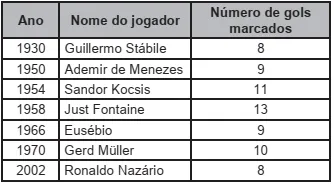

Para facilitar a análise sobre a quantidade de gols marcados por esses artilheiros nas referidas copas, foi calculada a mediana da distribuição dos números de gols marcados por eles nas sete copas especificadas no quadro.

A mediana dessa distribuição é igual a

1. 9,0.
2. 9,7.
3. 10,0.
4. 10,2.
5. 13,0.

RESPOSTA: A

Para encontrar a [mediana](https://brasilescola.uol.com.br/matematica/mediana.htm), colocaremos os dados em ordem:

8 8 9 9 10 11 13

Sabemos que a mediana é o termo que está posicionado no centro. Como há 7 elementos, a mediana é o 4º valor:

8 8 9 **9** 10 11 13

Assim, a mediana desse conjunto de dados é 9.

QUESTÃO 02 - 1

(Enem PPL 2010) Em uma corrida de regularidade, a equipe campeã é aquela em que o tempo dos participantes mais se aproxima do tempo fornecido pelos organizadores em cada etapa. Um campeonato foi organizado em 5 etapas, e o tempo médio de prova indicado pelos organizadores foi de 45 minutos por prova. No quadro, estão representados os dados estatísticos das 5 equipes mais bem classificadas.

Dados estatísticos das equipes mais bem classificadas (em minutos):

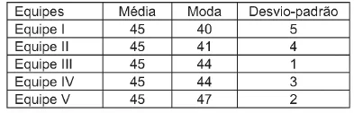

Utilizando os dados estatísticos do quadro, a campeã foi a equipe

RESPOSTA: C

Sabemos que quanto menor é o desvio padrão, mais regulares são os dados. Note que todas possuem a mesma média, entretanto a equipe III é a que tem o menor desvio padrão. Logo, essa é a equipe que possui o tempo mais próximo da meta.

QUESTÃO 03 - 1  
(UFT-TO) A nota final para uma disciplina de uma instituição de ensino superior é a média ponderada das notas A, B e C, cujos pesos são 1, 2 e 3, respectivamente. Paulo obteve A = 3,0 e B = 6,0. Quanto ele deve obter em C para que sua nota final seja 6,0?

1. 7,0
2. 9,0
3. 8,0
4. 10,0

RESPOSTA: A

Seja x a terceira nota, temos que:

[figure not shown]

QUESTÃO 04 - 1  
(Enem 2015) Uma pessoa, ao fazer uma pesquisa com alguns alunos de um curso, coletou as idades dos entrevistados e organizou esses dados em um gráfico.

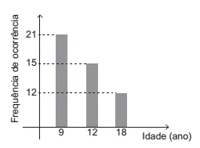

Qual a moda das idades, em anos, dos entrevistados?

1. 9
2. 12
3. 13
4. 15
5. 21

RESPOSTA: A

A moda é o valor com maior frequência, ou seja, o valor que mais ocorreu. Analisando o gráfico, vemos que o valor que possui a maior ocorrência é a idade de 9 anos, que apareceu 21 vezes. Sendo assim, a moda desse conjunto é 9.

QUESTÃO 05 - 1  
Buscando fazer uma renda extra, Fabrício decidiu fazer bolo no pote em sua casa para vender na escola. Antes de começar a produzir, ele resolveu fazer uma pesquisa de campo para entender qual seriam os sabores preferidos dos seus clientes. Considerando que os potenciais clientes eram os 400 estudantes matriculados e os 22 funcionários da escola, Fabrício foi até lá para realizar a sua pesquisa e obteve a seguinte resposta:

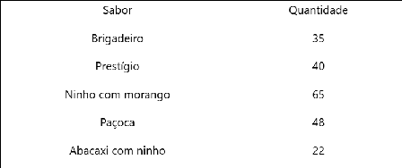

Analisando as respostas coletadas, podemos afirmar que:

1. A pesquisa foi realizada com uma amostra de 422 pessoas.
2. A pesquisa foi realizada com uma população de 210 pessoas.
3. A pesquisa foi realizada com uma amostra de 210 pessoas.
4. A pesquisa foi realizada com uma população de 400 pessoas.

RESPOSTA: C

A população abarca os estudantes e os funcionários, logo ela corresponde a 400 + 22 = 422 pessoas. Já a amostra é composta pelas pessoas que foram abordadas, que é igual a 35 + 40 + 65 + 48 + 22 = 210. Concluímos, então, que a pesquisa foi realizada com uma amostra de 210 pessoas.

QUESTÃO 06 - 1

Dados os números 10, 6, 4, 3 e 9, cinco números de uma lista de 8 números inteiros, o menor valor possível para a mediana desse conjunto é:

1. 3,0
2. 3,5
3. 4,0
4. 6,0
5. 10,0

RESPOSTA: B

Para que mediana seja o menor valor possível, os 3 números restantes, x, y e z, devem ser menores ou iguais a 3, deixando a lista da seguinte maneira:

x, y, z, **3, 4,** 6, 9, 10

Como a quantidade de termos é par, pois na sequência há 8 números, somaremos os dois termos centrais e dividiremos por 2:

(3 + 4) : 2 = 3,5

QUESTÃO 07 - 1

Durante a organização das eleições para diretor escolar, os estudantes fizeram uma pesquisa sobre a intenção de voto dos alunos entre os candidatos A, B e C. Os resultados obtidos estão na tabela a seguir:

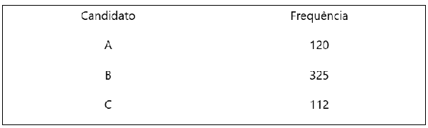

Sabendo que na escola há 607 votantes e que as pessoas restantes não estavam na escola no dia da pesquisa, a porcentagem de pessoas não alcançadas nessa pesquisa é de aproximadamente:

1. 83,0%
2. 72,0%
3. 8,3%
4. 7,2%
5. 6,0%

RESPOSTA: C

Primeiramente, calcularemos a quantidade de respostas obtidas:

120 + 325 + 112 = 557

Agora, calcularemos a diferença:

607 – 557 = 50

Transformando em [porcentagem](https://brasilescola.uol.com.br/matematica/porcentagem.htm), temos que 0,0833… *≈* 8,3%.

QUESTÃO 08 - 1

**Quantidade de irmãos dos alunos do 2º A**

1. Menos da metade dos estudantes pesquisados tem 2 irmãos ou mais.
2. Menos da metade dos estudantes pesquisados possui no máximo 2 irmãos.
3. A maior parte dos estudantes pesquisados possui exatamente 1 irmão.
4. Mais da metade dos estudantes pesquisados tem 3 irmãos ou mais.
5. Mais da metade dos estudantes pesquisados possui pelo menos 2 irmãos.

RESPOSTA: E

QUESTÃO 09 - 1

Durante uma pesquisa feita por um petshop, o atendente da loja realizava duas perguntas para cada um dos clientes atendidos naquele dia:

- Quais são as espécies de seus animais de estimação?
- Quantos animais de estimação de cada espécie você tem?

**Quantidade de animais dos clientes do petshop**

I – Podemos inferir que a pesquisa foi respondida por 45 clientes.

II – O animal mais frequente é o cachorro, que representa aproximadamente 47% dos animais.

III – Há somente 3 animais diferentes de gato, cachorro e peixe.

Marque a alternativa correta:

1. Todas as afirmativas são verdadeiras.
2. Somente a afirmativa I é falsa
3. Somente a afirmativa II é falsa
4. Somente a afirmativa III é falsa.

RESPOSTA: B

QUESTÃO 10 - 1

Os valores dos salários dos funcionários de uma empresa estão representados na tabela a seguir:

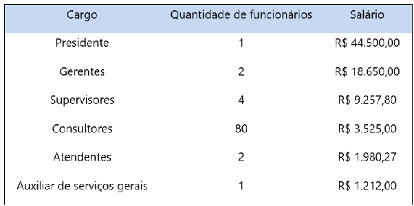

Analisando a tabela de salários dos funcionários da empresa, podemos afirmar que:

1. A moda salarial dessa empresa é R$ 3.525,00, que é o salário dos consultores.
2. A mediana dos salários é de R$ 6.391,40.
3. A maioria dos funcionários ganha abaixo de R$ 3.525,00.
4. A moda salarial dessa empresa é o conjunto {2, 4}.
5. A média salarial dessa empresa é R$ 3.525,00.

RESPOSTA: A

O cargo que possui a maior quantidade de funcionários é o de consultor, logo a moda será o salário de um consultor, que é de R$ 3.525,00.

QUESTÃO 11 - 2  
No lançamento de dois dados perfeitos, qual a probabilidade de que a soma dos resultados obtidos seja igual a 6?  
A) 1/6  
B) 1/9  
C) 5/36  
D) 1/12  
E) 7/36

RESPOSTA: C

Para que a soma seja 6, precisamos das seguintes faces: {(1,5), (2,4), (3,3), (4,2), (5,1)}. E considerando que o espaço amostral do lançamento de dois dados e representado pela multiplicação 6 * 6 = 36, temos a seguinte probabilidade:  
P = 5/36 = 0,1388  
A probabilidade é de 5/36, aproximadamente 13,88% de chance.

QUESTÃO 12 - 2

Qual é a probabilidade de, no lançamento de 4 moedas, obtermos cara em todos os resultados?

1. 2%
2. 2,2%
3. 6,2%
4. 4%
5. 4,2%

RESPOSTA: C

Primeiramente, é necessário encontrar o número total de possibilidades de resultados:

2·2·2·2 = 16

Posteriormente, devemos encontrar o número de possibilidades de obter cara em todos os resultados. Na realidade, só existe uma possibilidade de que isso aconteça.

Por fim, basta dividir o segundo pelo primeiro:

1 = 0,0625  
16

Multiplicando 6,25 por 100, para obter um percentual, teremos: 6,25%

QUESTÃO 13 - 2

Duas moedas e dois dados, todos diferentes entre si, foram lançados simultaneamente. Qual é o número de possibilidades de resultados para esse experimento?

1. 146
2. 142
3. 133
4. 144
5. 155

RESPOSTA: D

Para calcular o número de possibilidades de resultados de um experimento nesses moldes, multiplique o número de resultados possíveis de cada objeto em observação. No caso de cada moeda, 2 resultados, e de cada dado, 6 resultados:

2·2·6·6 = 4·36 = 144

QUESTÃO 14 - 2

Qual é o número total de possibilidades de resultado no lançamento de 5 moedas?

1. 2
2. 5
3. 10
4. 24
5. 32

RESPOSTA: E

O número total de resultados que pode ser obtido no lançamento de duas moedas é encontrado multiplicando-se a quantidade de resultados da primeira moeda pela quantidade da segunda e assim por diante. Observe:

2·2·2·2·2 = 32

Portanto, são 32 possibilidades diferentes.

QUESTÃO 15 - 2  
Considere que existe uma urna na qual foram colocadas 200 esferas de plásticos, e cada uma delas possui um pedaço de papel no seu interior. As esferas são coloridas, sendo uma de cada cor. Os pedaços de papel, então, trazem números de 1 a 200, diferentes a cada esfera. Qual das alternativas apresenta a probabilidade de que, ao sortear uma dessas esferas, ela tenha um número divisível por 3 e por 5 ao mesmo tempo?

a)13,0%.  
b)6,5%.  
c)3,25%.  
d)9,75%.  
e) 9,0%

RESPOSTA: B

Para saber quantos divisores de 3 e 5 têm entre 1 a 200, primeiro temos que achar o divido comum:

- MMC de 3 e 5
- 3, 5 | 3
- 1, 5 | 5
- 1, 1
- MMC = 15

Sabendo o fator comum, basta dividi-lo pela quantidade:

- 200/15
- 13 divisores comum

Probabilidade: Quero/Total

- P = 13/200 {divide por dois para ciar na base 10}
- P = 6,5/100
- P = 6,5 %

QUESTÃO 16 - 2

(Espcex (Aman)) Numa sala existem duas caixas com bolas amarelas e verdes. Na caixa 1, há 3 bolas amarelas e 7 bolas verdes. Na caixa 2, há 5 bolas amarelas e 5 bolas verdes. De forma aleatória, uma bola é extraída da caixa 1, sem que se saiba a sua cor, e é colocada na caixa 2. Após esse procedimento, a probabilidade de extrair uma bola amarela da caixa 2 é igual a:

1. 49/110
2. 51/110
3. 53/110
4. 57/110
5. 61/110

RESPOSTA: C

Temos dois casos a considerar:

1. retirada de uma bola amarela da caixa 1 e de outra amarela da caixa 2

Neste caso temos que a probabilidade de retirar uma bola amarela da primeira caixa é 3/10 e da segunda caixa é 6/11. Como neste caso estamos utilizando a conjunção “E” multiplicamos ambos os resultados:

3/10 · 6/11

2. retirada de uma bola verde da caixa 1 e de uma amarela da caixa 2

Neste caso temos que a probabilidade de retirar uma bola verde da primeira caixa é 7/10 e retirar da segunda caixa uma bola amarela é 5/11. Como neste caso estamos utilizando a conjunção “E” multiplicamos ambos os resultados:

7/10 · 5/11

Desse modo, devemos somar ambos os resultados pois queremos um “OU” outro, a resposta é dada por: 3/10 · 6/11 + 7/10 · 5/11 = 53/110

QUESTÃO 17 - 2

(Enem PPL) Para um docente estrangeiro trabalhar no Brasil, ele necessita validar o seu diploma junto ao Ministério da Educação. Num determinado ano, somente para estrangeiros que trabalharão em universidades dos estados de São Paulo e Rio de Janeiro, foram validados os diplomas de 402 docentes estrangeiros. Na tabela, está representada a distribuição desses docentes estrangeiros, por países de origem, para cada um dos dois estados.

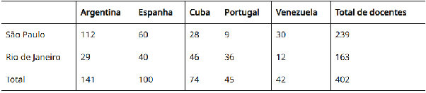

A probabilidade de se escolher, aleatoriamente, um docente espanhol, sabendo-se que ele trabalha em uma universidade do estado de São Paulo é

1. 60/402
2. 60/239
3. 60/100
4. 100/239
5. 279/402

RESPOSTA: B

Perceba que queremos saber a probabilidade de ser um espanhol sabendo que ele trabalha em uma universidade de São Paulo. Se A é o evento “docente espanhol” e B é o evento “trabalha em uma universidade do estado de São Paulo”, então queremos calcular P(A|B).

Sabendo pela tabela, que o número de professores espanhóis que lecionam em São Paulo é: n(A ∩ B) = 60

Além disso, sabemos que o número de professores estrangeiros que trabalham em São Paulo é n(B)= 239.

Dado a fórmula de probabilidade condicional sabemos que:

P(A|B)=(n(A ∩ B))/(n(B))

=60/239

QUESTÃO 18 - 2

(UFPR) Um kit para impressão vem com oito cartuchos de tinta, de formato idêntico, para impressora. Nesse kit há dois cartuchos de cada uma das quatro cores diferentes necessárias para uma impressora caseira (ciano, magenta, amarelo e preto). Escolhendo aleatoriamente dois cartuchos desse kit, qual a probabilidade de se obter duas cores distintas?

1. 6/7
2. 1/12
3. 15/56
4. 1/48
5. 1/64

RESPOSTA: A

Como são dois cartuchos de cada uma das quatro cores, não importa qual o cartucho pegar, a probabilidade de pegar outro cartucho da mesma cor é 1/7, pois há apenas mais um cartucho daquela cor dentre os 7 cartuchos que restaram. Desse modo, a probabilidade de pegar dois cartuchos de cores distintas é o complementar, ou seja 1 - 1/7 = 6/7

QUESTÃO 19 - 2

Um morador de uma região metropolitana tem 50% de probabilidade de atrasar-se para o trabalho quando chove na região. Caso não chova, sua probabilidade de atraso é de 25%. Para um determinado dia, o serviço de meteorologia estima em 30% de probabilidade da ocorrência de chuva nessa região. Qual é a probabilidade de esse morador se atrasar para o serviço no dia para o, qual foi dada a estimativa de chuva?

1. 0,075
2. 0,150
3. 0,325
4. 0,600
5. 0,800

RESPOSTA: C

P(A) = probabilidade de chover no dia * probabilidade de se atrasar quando chove + probabilidade de não chover no dia * probabilidade de não se atrasar quando chove.

Aplicando as porcentagens em decimais temos:

P(A) = 0,30 * 0,50 + 0,70 * 0,25

P(A) = 0,15 + 0,175

P(A) = 0,325

QUESTÃO 20 - 2

1. 8%.
2. 9%.
3. 11%.
4. 12%.
5. 22%.

RESPOSTA: C

P(A) = 22/200

P(A) = 11/100

QUESTÃO 21 - 2

No próximo final de semana, um grupo de alunos participará de uma aula de campo. Em dias chuvosos, aulas de campo não podem ser realizadas. A ideia é que essa aula seja no sábado, mas, se estiver chovendo no sábado, a aula será adiada para o domingo. Segundo a meteorologia, a probabilidade de chover no sábado é de 30% e a de chover no domingo é de 25%. A probabilidade de que a aula de campo ocorra no domingo é de:

1. 5,0%
2. 7,5%
3. 22,5%
4. 30,0%
5. 75,0%

RESPOSTA: C

Para que a aula aconteça no domingo, é preciso que chova no sábado e não chova no domingo. Esse “e” nos mostra que é preciso encontrar o produto entre essas probabilidades. A fórmula muda um pouco:

P(A∩B) = P(A) x P(B)

Já sabemos qual é o nosso P(A), a probabilidade de chover no sábado, que é de 30% ou 0,3. Também sabemos que a chance de chover no domingo é de 25%, o que nos leva a calcular nosso evento B favorável, a probabilidade de não chover no domingo: 100% - 25% = 75%. Nosso P(B), então, é de 75% ou 0,75.

Então, o cálculo será:

P(A∩B) = 0,3 x 0,75

P (A∩B) = 0,225 = 22,5%

QUESTÃO 22 - 2

Um dado honesto é lançado uma única vez. Consideremos as variáveis X = 1, se o número observado é maior ou igual a 3, X = 0 caso contrário. Seja Y = 1 se o número observado é par, e Y = 0 caso contrário. Calcule as distribuições marginais de X e Y.

1. Distribuições: P(X=0) = 1/3, P(X=1) = 2/3, P(X=0) = 1/2, P(X=1) = 1/2.
2. Distribuições: P(X=0) = 1/3, P(X=1) = 2/3, P(X=0) = 1/2, P(X=1) = 1/3.
3. Distribuições: P(X=0) = 1/2, P(X=1) = 1/2, P(X=0) = 1/2, P(X=1) = 1/2.
4. Distribuições: P(X=0) = 1/3, P(X=1) = 1/2, P(X=0) = 1/2, P(X=1) = 1/2.
5. Distribuições: P(X=0) = 1/2, P(X=1) = 1/2, P(X=0) = 2/3, P(X=1) = 1/3.

RESPOSTA: A

Distribuições marginais de X e Y:

Para X:

• P(X=0)=1/6+1/6= 2/6 ou 1/3

• P(X=1)=2/6+2/6= 4/6 ou 2/3

Para Y:

• P(Y=0)=1/6+2/6= 3/6 ou 1/2

• P(Y=1)=1/6+2/6= 3/6 ou 1/2

QUESTÃO 23 - 2

Um dado honesto é lançado uma única vez. Consideremos as variáveis X = 1, se o número observado é maior ou igual a 3, X = 0 caso contrário. Seja Y = 1 se o número observado é par, e Y = 0 caso contrário. Calcule P(X+Y=1).

1. P(X+Y=1) = 1/3
2. P(X+Y=1) = 1/2
3. P(X+Y=1) = 3/2
4. P(X+Y=1) = 2/3
5. P(X+Y=1) = 5/6

RESPOSTA: B

Calcule P(X+Y=1)

Queremos os pares (X,Y) cuja soma seja 1:

• X=0,Y=1 → prob = 1/6

• X=1,Y=0 → prob = 2/6

Portanto: P(X+Y=1) = 1/6 + 2/6 = 3/6 = 1/2

QUESTÃO 24 - 2

Em um pacote com cinco transistores, dois deles são defeituosos. Os transistores são escolhidos ao acaso devem ser testados, um de cada vez, até que aqueles defeituosos sejam identificados. Qual a probabilidade de haver pelo menos um transistor sem defeito entre os dois defeituosos encontrados?

1. 3/10
2. 2/5
3. 3/5
4. 7/10
5. 4/5

RESPOSTA: C

Probabilidade de se observar um transistor sem defeito entre os dois defeituosos

Ou seja, há um bom (B) entre os dois D, como por exemplo:

D B D → tem bom entre

Basta contar os casos em que entre as posições dos dois defeituosos há pelo menos 1 bom.

Isso acontece quando os defeituosos não estão em posições consecutivas.

• Consecutivos: (1,2), (2,3), (3,4), (4,5) → 4 casos

• Restantes 6 casos têm pelo menos um bom entre os dois D

Logo:

P(há um bom entre os dois defeituosos) = 6/10 = 0,6

QUESTÃO 25 - 2

Em um pacote com cinco transistores, dois deles são defeituosos. Os transistores são escolhidos ao acaso devem ser testados, um de cada vez, até que aqueles defeituosos sejam identificados. Qual é a probabilidade de serem necessários testar todos os cinco transistores, dado que o primeiro transistor testado foi defeituoso?

1. 1/5
2. 1/4
3. 2/5
4. 1/2
5. 3/5

RESPOSTA: B

Probabilidade de testar todos dado que o 1º testado foi defeituoso

Ou seja: P(X+Y=5∣X=1)

Entre os pares com X=1, temos:

• (1,1): (1,2) → X+Y=2

• (1,2): (1,3) → X+Y=3

• (1,3): (1,4) → X+Y=4

• (1,4): (1,5) → X+Y=5

Total de 4 casos com X=1, e só um com X+Y=5

P(X+Y=5∣X=1) = 1/10 4/10 = 1/4 = 0,25

QUESTÃO 26 - 2

Em um pacote com cinco transistores, dois deles são defeituosos. Os transistores são escolhidos ao acaso devem ser testados, um de cada vez, até que aqueles defeituosos sejam identificados. Qual é a probabilidade de serem necessários testar todos os cinco transistores para encontrar os dois defeituosos?

1. 1/5
2. 1/4
3. 2/5
4. 1/2
5. 3/5

RESPOSTA: C

Probabilidade de testar todos para encontrar os dois defeituosos

Ou seja, P(X+Y=5)

Já vimos que os pares que satisfazem isso são:

• (1,4), (2,3), (3,2), (4,1) → 4 casos

Logo: P(X+Y=5) = 4/10 = 0,4

QUESTÃO 27 - 2

Um dado honesto é lançado uma única vez. Consideremos as variáveis X = 1, se o número observado é maior ou igual a 3, X = 0 caso contrário. Seja Y = 1 se o número observado é par, e Y = 0 caso contrário.

1. P(X=0) = 1/2, P(X=1) = 1/2

P(Y=0) = 1/2, P(Y=1) = 1/2

2. P(X=0) = 1/3, P(X=1) = 2/3

P(Y=0) = 1/2, P(Y=1) = 1/2

3. P(X=0) = 2/3, P(X=1) = 1/3

P(Y=0) = 1/2, P(Y=1) = 1/2

4. P(X=0) = 2/3, P(X=1) = 1/3

P(Y=0) = 2/3, P(Y=1) = 1/3

5. P(X=0) = 1/3, P(X=1) = 2/3

P(Y=0) = 1/3, P(Y=1) = 2/3

RESPOSTA: B

Distribuições marginais de X e Y

Para X:

• P(X=0)=1/6+1/6=2/6

• P(X=1)=2/6+2/6=4/6

Para Y:

• P(Y=0)=1/6+2/6=3/6

• P(Y=1)=1/6+2/6=3/6

QUESTÃO 28 - 2

Um dado honesto é lançado uma única vez. Consideremos as variáveis X = 1, se o número observado é maior ou igual a 3, X = 0 caso contrário. Seja Y = 1 se o número observado é par, e Y = 0 caso contrário. A probabilidade de P(X+Y=1) é igual a:

1. 1/3
2. 1/2
3. 2/3
4. 1/6
5. 5/6

RESPOSTA: B

Calcule P(X+Y=1)

Queremos os pares (X,Y) cuja soma seja 1:

• X=0,Y=1 → prob = 1/6

• X=1,Y=0 → prob = 2/6

Portanto:

P(X+Y=1)=1/6+2/6=3/6=1/2

QUESTÃO 29 - 2

Em uma urna existem bolas enumeradas de 1 a 15. Qualquer uma delas possui a mesma chance de ser retirada. Determine a probabilidade de se retirar uma bola com número par.

1. 1/2
2. 7/15
3. 8/15
4. 3/5
5. 2/3

RESPOSTA: B

Espaço amostral: (1, 2, 3, 4, 5, 6, 7, 8, 9, 10, 11, 12, 13, 14, 15)

No espaço amostral de 15 números, temos 7 números pares.  
P = 7/15 = 0,466 = 46,6%

QUESTÃO 30 - 2

Uma moeda honesta é lançada 4 vezes. Qual é o número de sequências possíveis?  
A) 16

2. 8
3. 32
4. 4
5. 64

RESPOSTA: A

Como a moeda é lançada 4 vezes, cada lançamento tem dois resultados possíveis: K (cara) ou C (coroa).

Logo, o total de sequências possíveis é 2^4=16

QUESTÃO 31 - 2

Em uma urna existem bolas enumeradas de 1 a 15. Qualquer uma delas possui a mesma chance de ser retirada. Determine a probabilidade de se retirar uma bola com número primo.

1. 1/4
2. 1/3
3. 2/5
4. 3/5
5. 7/15

RESPOSTA: C

Espaço amostral: (1, 2, 3, 4, 5, 6, 7, 8, 9, 10, 11, 12, 13, 14, 15)

Temos 6 números primos dentre o espaço amostral de 15 números.  
P = 6/15 = 0,4 = 40%

QUESTÃO 32 - 2

Em uma urna existem bolas enumeradas de 1 a 15. Qualquer uma delas possui a mesma chance de ser retirada. Determine a probabilidade de se retirar uma bola com número par ou primo.

1. 2/3
2. 3/5
3. 7/15
4. 4/5
5. 13/15

RESPOSTA: D

Número par = 7 possibilidades entre 15  
Número primo = 6 possibilidades entre 15  
Par ∩ primo = 1

P(par) + P(primo) – P (par ∩ primo)

7/15 + 6/15 - 1/15 = 12/15 = ⅘

QUESTÃO 33 - 2  
Em uma urna existem bolas enumeradas de 1 a 15. Qualquer uma delas possui a mesma chance de ser retirada. Determine a probabilidade de se retirar uma bola com número par e primo.  
A) 1/3  
B) 1/5  
C) 2/15  
D) 1/15  
E) 1/20  
RESPOSTA: D  
Dentro do intervalo dado, temos um único número que satisfaz a condição de ser par e primo ao mesmo tempo, que é o número 2. Portanto, temos a seguinte probabilidade:  
P = 1/15

QUESTÃO 34 - 2  
Uma moeda é lançada 10 vezes. Determine a probabilidade aproximada (em porcentagem) de sair “coroa” 7 vezes.  
A) 4,40%  
B) 11,72%  
C) 12,50%  
D) 25%  
E) 20,51%  
RESPOSTA: B  
Chance de sair cara = 1/2  
Chance de não sair cara (sair coroa) = ½

(10/7) . (1/2)7 . (1/2)3 = 120 . 1/128 . 1/8 = 120/1024 = 11,7%

QUESTÃO 35 - 2

Se P(A)=0,30, P(B)=0,40 e A e B são independentes, então P(A∩B) é:

1. 0,12
2. 0,70
3. 0,34
4. 0,10
5. 0,75

RESPOSTA: A

Para eventos independentes,

P(A∩B)= P(A) . P(B) = 0,30 · 0,40 = 0,12.

QUESTÃO 36 - 2

Dois eventos A e B são independentes se, e somente se:  
A) P(A|B)=P(B|A)  
B) P(A∩B)=P(A)+P(B)  
C) P(A∩B)=P(A)P(B)  
D) P(A|B)=P(A)+P(B)  
E) P(A∪B)=P(A)P(B)  
RESPOSTA: C  
A definição adotada no capítulo de probabilidades é:  
A e B são independentes ⇔ P(A∩B)=P(A) . P(B).

QUESTÃO 37 - 2  
Em termos de A e B com P(B)>0, o Teorema de Bayes (versão simples) fornece P(A|B) como:  
A) P(A|B)=P(A)P(B)  
B) P(A|B)=P(A∩B)/P(A)  
C) P(A|B)=P(A∩B)/P(B)=P(A)·P(B|A)/P(B)  
D) P(A|B)=P(B|A)  
E) P(A|B)=1-P(B|A)  
RESPOSTA: C  
P(A|B)=P(A∩B)/P(B).  
Como P(A∩B)=P(A)P(B|A),  
resulta P(A|B)=P(A)·P(B|A)/P(B).

QUESTÃO 38 - 2

Num experimento binomial com parâmetros n e p, a probabilidade de X=k sucessos é:

1. P(X=k)= (n+k)!/(n!k!) · p^k · (1-p)^{n-k}
2. P(X=k)= C(n,k) p^k (1-p)^{n-k}
3. P(X=k)= e^{-p} p^k/k!
4. P(X=k)= (1/√(2π)) e<sup>{-k</sup>2/2}
5. P(X=k)= p(1-p)^{k-1}

RESPOSTA: B

Pelo modelo binomial b(n,p), a função de probabilidade é

b(k;n,p)=C(n,k)p^k q^{n-k}, com q=1-p, para k=0,1,…,n.

QUESTÃO 39 - 2

Um telefone recebe, em média, 5 chamadas por minuto. Supondo um modelo de Poisson, qual é a probabilidade de não receber chamadas em 1 minuto?  
A) e^{-5}  
B) 1-e^{-5}  
C) 5e^{-5}  
D) e^{-1/5}  
E) (1/5)e^{-5}  
RESPOSTA: A  
No modelo Poisson(λ), P(N=k)=e^{-λ} . λ^k/k!  
Para k=0 e λ=5: P(N=0)=e^{-5}.

QUESTÃO 40 - 2  
Uma moeda é lançada 5 vezes (p=0,5 de cara). Seja X o número de caras. Qual é P(X=3)?  
A) 5/32  
B) 10/32  
C) 1/2  
D) 3/8  
E) 15/32  
RESPOSTA: B  
X~b(5; 0,5)  
Então P(X=3) = C(5,3) . (0,5)^3 . (0,5)^{2} = C(5,3) . (0,5)^5 = 10/32

QUESTÃO 41 - 2  
Uma variável Z segue a distribuição normal padrão N(0,1), e uma variável Y segue a distribuição qui-quadrado com ν graus de liberdade, sendo Z e Y independentes. A variável t é definida como t = Z/√(Y/ν). A distribuição da variável t é:  
A) Normal padrão  
B) Qui-quadrado com ν g.l.  
C) t de Student com ν g.l.  
D) F com (1,ν) g.l.  
E) Uniforme(0,1)  
RESPOSTA: C  
A definição da distribuição t de Student com ν graus de liberdade é exatamente:  
t = Z/√(Y/ν)

QUESTÃO 42 - 2

Se X ~ N(μ, σ²), então E(X) e Var(X) são, respectivamente:

1. μ e σ
2. 0 e 1
3. μ e σ²
4. σ e μ²
5. μ² e σ²

RESPOSTA: C

No modelo normal, os momentos básicos são E(X)=μ e Var(X)=σ²

QUESTÃO 43 - 2

Se X ~ N(1000, 20²), qual é P(X < 980)? (Use a padronização Z=(X-μ)/σ e Φ(-1)=0,1587.)  
A) 0,8413  
B) 0,5000  
C) 0,1587  
D) 0,0228  
E) 0,9772  
RESPOSTA: C  
Z=(980-1000)/20 = -20/20 = -1.  
Logo P(X<980) = P(Z<-1) = Φ(-1) = 0,1587.

QUESTÃO 44 - 2  
Um lote tem 20 peças, das quais 5 são defeituosas. Escolhem-se 4 peças ao acaso, sem considerar a ordem. Qual é a probabilidade de obter exatamente 2 defeituosas?  
A) C(5,2) · C(15,2) / C(20,4)  
B) C(5,2) · C(15,2) / C(20,2)  
C) C(5,4) / C(20,4)  
D) C(15,2) / C(20,4)  
E) C(5,2) / C(20,4)  
RESPOSTA: A  
O espaço amostral tem C(20,4) amostras possíveis (sem ordem).  
Casos favoráveis: escolher 2 defeituosas entre 5 e 2 não defeituosas entre 15: C(5,2) · C(15,2)  
Logo, P = C(5,2) · C(15,2) / C(20,4)  
Princípio multiplicativo com combinações.

QUESTÃO 45 - 2  
Suponha que P(A∩B)=0,20 e P(B)=0,50 (com P(B)>0). Qual é P(A|B)?  
A) 0,10  
B) 0,20  
C) 0,30  
D) 0,40  
E) 0,70  
RESPOSTA: D  
P(A|B) = P(A∩B) / P(B)  
P(A|B) = 0,20/0,50 = 0,40

QUESTÃO 46 - 2  
Dois eventos A e B são independentes se, e somente se:  
A) P(A|B) = P(B|A)  
B) P(A∪B) = P(A)+P(B)  
C) P(A∩B) = P(A)P(B)  
D) P(A∩B) = 0  
E) P(A) = 1 − P(B)  
RESPOSTA: C  
A e B são independentes quando a ocorrência de um não altera a probabilidade do outro.  
Uma condição equivalente é P(A∩B) = P(A) . P(B)

QUESTÃO 47 - 2  
Se P(B)>0, a probabilidade condicional de A dado B é definida por:  
A) P(A|B)=P(A)P(B)  
B) P(A|B)=P(A∩B)/P(B)  
C) P(A|B)=P(B∩A)/P(A)  
D) P(A|B)=P(A)+P(B)  
E) P(A|B)=1−P(A∩B)  
RESPOSTA: B  
Pela definição, quando P(B)>0:  
P(A|B) = P(A∩B) / P(B)

QUESTÃO 48 - 3  
Uma população tem μ=50 e σ=10. Retira-se uma amostra aleatória de tamanho n=36. Usando o TLC, aproxime P(X̄ > 52). (Use Φ(1,2)=0,8840.)  
A) 0,1160  
B) 0,8840  
C) 0,1587  
D) 0,5000  
E) 0,2410  
RESPOSTA: A  
Pelo TLC, X̄ ≈ N(50, 10²/36).  
Desvio-padrão de X̄: 10/6 = 1,6667.  
Padronizando: z = (52-50) / 1,6667 = 1,2.  
Assim P(X̄>52) = P(Z>1,2)= 1 - Φ(1,2) = 1 - 0,8840 = 0,1160.

QUESTÃO 49 - 3  
Deseja-se escolher n tal que P(|X̄-μ| ≤ ε) = γ, assumindo σ² conhecida. Se σ=4, ε=0,5 e γ=0,95 (use z_γ = 1,96), qual n o livro obtém pela fórmula  
n = σ² . z_γ² / ε² (arredonde para cima)?  
A) 62  
B) 123  
C) 246  
D) 16  
E) 400  
RESPOSTA: C  
n = (σ² . z_γ²)/(ε²) = (16·(1,96)²) / (0,25)  
(1,96)² = 3,8416  
16·3,8416 = 61,4656  
61,4656 / 0,25 = 245,8624  
Arredondando para cima: n=246.

QUESTÃO 50 - 3  
Pelo Teorema Limite Central, se a população tem média μ e variância σ² finita, então para n grande a média amostral X̄ é aproximadamente:  
A) N(0,1)  
B) N(μ, σ²)  
C) N(μ, σ²/n)  
D) b(n, μ)  
E) Poisson(σ²/n)  
RESPOSTA: C  
O TLC afirma que, para n grande, a distribuição amostral de X̄ aproxima-se de N(μ, σ²/n).

QUESTÃO 52 - 3  
Se (X1,…,Xn) é uma AAS(Amostra Aleatória Simples) de uma população com média μ e variância σ², qual é Var(X̄)?  
A) σ²  
B) σ²/n  
C) σ/√n  
D) σ²/(n−1)  
E) nσ²  
RESPOSTA: B  
Para uma AAS, Var(X̄)=σ²/n

QUESTÃO 53 - 3  
Deseja-se que P(|X̄−μ| ≤ ε)=γ, com σ conhecida. A expressão que relaciona n, σ, ε e zγ é:  
A) n = (σ zγ)/ε  
B) n = (σ² zγ)/ε²  
C) n = (σ² zγ²)/ε²  
D) n = (ε² zγ²)/σ²  
E) n = (σ zγ²)/ε²  
RESPOSTA: C  
Padronize: Z = (X̄−μ)√n/σ ~ N(0,1)  
Imponha P(|Z|≤zγ)=γ ⇒ zγ = ε√n/σ  
Então √n = (σ zγ)/ε ⇒ n = (σ² zγ²)/ε²

QUESTÃO 56 - 3

Em um teste de hipóteses, o erro de tipo I corresponde a:  
A) Aceitar H0 quando H0 é falsa  
B) Rejeitar H0 quando H0 é verdadeira  
C) Aceitar H1 quando H1 é falsa  
D) Rejeitar H1 quando H1 é verdadeira  
E) Sempre rejeitar H0  
RESPOSTA: B  
Erro tipo I (α): rejeitar H0 mesmo quando H0 é verdadeira.  
Erro tipo II (β): não rejeitar H0 quando H0 é falsa.

QUESTÃO 57 - 3

No teste H0: p = 0,60 vs H1: p<0,60, com n = 200 e α = 0,05, a região crítica pode ser expressa como p̂ ≤ p̂c. Qual é p̂c aproximado (use zα = −1,645)?

1. 0,571
2. 0,544
3. 0,520
4. 0,600
5. 0,456

RESPOSTA: B

Sob H0, p̂ ≈ N(p0, p0(1−p0) / n), com p0 = 0,60

DP(desvio padrão) = √(0,60 · 0,40/200)=√(0,24 / 200)=√0,0012 ≈ 0,03464.

p̂c(valor crítico) = 0,60 + (−1,645) · 0,03464 ≈ 0,543

Arredondando: p̂c ≈ 0,544

QUESTÃO 58 - 1

Considere as variáveis a seguir, observadas em um levantamento com estudantes: (i) cor dos olhos; (ii) número de irmãos; (iii) pressão arterial (mmHg); (iv) nível de satisfação (baixo/médio/alto). Classifique cada uma como qualitativa nominal, qualitativa ordinal, quantitativa discreta ou quantitativa contínua.  
A) (i) nominal; (ii) discreta; (iii) contínua; (iv) ordinal  
B) (i) ordinal; (ii) discreta; (iii) discreta; (iv) nominal  
C) (i) nominal; (ii) contínua; (iii) contínua; (iv) ordinal  
D) (i) nominal; (ii) discreta; (iii) ordinal; (iv) contínua  
E) (i) ordinal; (ii) contínua; (iii) contínua; (iv) nominal  
RESPOSTA: A  
• (i) Cor dos olhos: categorias sem ordenação → qualitativa nominal.  
• (ii) Número de irmãos: contagem em 0,1,2,… → quantitativa discreta.  
• (iii) Pressão arterial: medida em escala contínua → quantitativa contínua.  
• (iv) Satisfação baixo/médio/alto: categorias ordenáveis → qualitativa ordinal.

QUESTÃO 59 - 1  
Os valores de uma variável X são: 4, 6, 6, 7, 9. Qual é a média aritmética?  
A) 5,6  
B) 6,4  
C) 6,8  
D) 7,0  
E) 7,6  
RESPOSTA: B  
Soma = 4+6+6+7+9 = 32. Como n = 5, a média é x-bar = 32/5 = 6,4.

QUESTÃO 61 - 1  
Considere os dados ordenados: 2, 3, 5, 7, 8, 9, 10, 11, 12, 15, 67. De acordo com a definição usual de quartis apresentada no capítulo de quantis empíricos, quais são q1 (1º quartil) e q3 (3º quartil)?  
A) q1 = 3 e q3 = 12  
B) q1 = 5 e q3 = 12  
C) q1 = 5 e q3 = 15  
D) q1 = 7 e q3 = 12  
E) q1 = 7 e q3 = 15  
RESPOSTA: B  
Os dados separam-se em quatro partes pelos quartis q1, q2 (mediana) e q3. Para esse conjunto, o texto indica q1 = 5 e q3 = 12 (com q2 = 9).

QUESTÃO 62 - 2  
Em uma universidade, há 200 alunos distribuídos entre cursos. No curso de Estatística, há 30 alunos, dos quais 20 são mulheres. Se um aluno é escolhido ao acaso e sabe-se que ele está matriculado em Estatística, qual é P(mulher | Estatística)?  
A) 1/10  
B) 1/3  
C) 2/3  
D) 3/5  
E) 20/200  
RESPOSTA: C  
P(mulher | Estatística) = (nº de mulheres em Estatística)/(total em Estatística) = 20/30 = 2/3.

QUESTÃO 63 - 2

QUESTÃO 64 - 2  
Se P(A) = 0,30, qual é P(A^c) (o complementar de A)?  
A) 0,30  
B) 0,70  
C) 1,30  
D) 0,15  
E) 0,60  
RESPOSTA: B  
P(A) + P(A^c) = 1.  
Logo, P(A^c) = 1 - 0,30 = 0,70.

QUESTÃO 66 - 2
Uma v.a. discreta X tem P(X=0) = 0,2, P(X=1) = 0,5 e P(X=2) = 0,3. Calcule E(X) e Var(X).
A) E(X)=1,1 e Var(X)=0,49
B) E(X)=1,0 e Var(X)=0,70
C) E(X)=1,3 e Var(X)=0,49
D) E(X)=1,1 e Var(X)=0,70
E) E(X)=1,0 e Var(X)=0,49
RESPOSTA: A
E(X) = Σ x p(x) = 0*0,2 + 1*0,5 + 2*0,3 = 0,5 + 0,6 = 1,1.
E(X^2) = Σ x^2 p(x) = 0 + 1*0,5 + 4*0,3 = 0,5 + 1,2 = 1,7.
Var(X) = E(X^2) -
$$E(X)$$
^2 = 1,7 - (1,1)^2 = 1,7 - 1,21 = 0,49.

QUESTÃO 67 - 2  
Em 100 intervalos de tempo, observou-se o número de eventos N com a seguinte frequência: n0=20, n1=30, n2=25, n3=25 (e nenhum intervalo com 4 ou mais eventos). Adote o modelo de Poisson e estime lambda pela média amostral. Em seguida, calcule P(N=0) pelo modelo ajustado.  
A) lambda =1,25 e P(N=0)=0,286  
B) lambda =1,55 e P(N=0)=0,212  
C) lambda =1,55 e P(N=0)=0,788  
D) lambda =1,75 e P(N=0)=0,174  
E) lambda =2,05 e P(N=0)=0,129  
RESPOSTA: B  
Estimativa por média:  
lambda = (0*20 + 1*30 + 2*25 + 3*25)/100 = (30+50+75)/100 = 155/100 = 1,55.  
No modelo de Poisson, P(N=0)=e^{-lambda } = e^{-1,55} ≈ 0,212.

QUESTÃO 71 - 1  
A variável “nível de escolaridade” é classificada como:

1. Quantitativa discreta
2. Quantitativa contínua
3. Qualitativa nominal
4. Qualitativa ordinal
5. Numérica intervalar

RESPOSTA: D  
“Nível de escolaridade” é uma variável qualitativa ordinal, pois é uma categoria que possui uma ordem/hierarquia.

QUESTÃO 72 - 1  
A medida que indica o quanto os dados estão dispersos em torno da média é:

1. Mediana
2. Moda
3. Desvio padrão
4. Percentil
5. Frequência relativa

RESPOSTA: C  
O desvio padrão indica a dispersão dos dados em torno da média

QUESTÃO 73 - 1  
Qual desses exemplos é considerado uma variável quantitativa discreta

1. Altura
2. Número de filhos
3. Peso
4. Cor de cabelo
5. Classe social

RESPOSTA: B  
“Número de filhos” é uma variável quantitativa discreta, pois são valores numéricos inteiros  
QUESTÃO 74 - 1  
Num experimento, 15 coelhos foram alimentados com uma nova ração e tiveram seus pesos avaliados ao fim do mês. Os dados referentes ao ganho de peso dos coelhos (em quilogramas) foram: 1,5; 1,6; 2,3; 1,7; 1,5; 2,0; 1,5; 1,8; 2,1; 2,1; 1,9; 1,8; 1,7; 2,5 e 2,2  
Qual foi a média de ganho de peso dos coelhos (em quilogramas)?

1. 2,45
2. 1,52
3. 1,81
4. 1,88
5. 2,10

RESPOSTA: D  
1,5 + 1,6 + 2,3 + 1,7 + 1,5 + 2,0 + 1,5 + 1,8 + 2,1 + 2,1 + 1,9 + 1,8 + 1,7 + 2,5 + 2,2 = 28,2  
28,2 / 15 =1,88

QUESTÃO 75 - 1  
Os dados abaixo referem-se à dureza de 12 peças de alumínio:  
53,0; 70,2; 84,3; 69,5; 77,8; 87,5; 53,4; 82,5; 67,3; 54,1; 70,5; 71,4  
Calcule o desvio padrão (considere 3 casas decimais):

1. 11,893
2. 9,837
3. 10,432
4. 11,102
5. 8,987

RESPOSTA: A  
Média:  
53,0 + 70,2 + 84,3 + 69,5 + 77,8 + 87,5 + 53,4 + 82,5 + 67,3 + 54,1 + 70,5 + 71,4 = 841,5  
841,5/12 =70,125  
Desvios  
70,125 - 53,0 = 17,125  
70,125 - 70,2 = -0,075  
70,125 - 84,3 = −14,175  
70,125 - 69,5 = 0,625  
70,125 - 77,8 = −7,675  
70,125 - 87,5 = −17,375  
70,125 - 53,4 = 16,725  
70,125 - 82,5 = −12,375  
70,125 - 67,3 = 2,825  
70,125 - 54,1 = 16,025  
70,125 - 70,5 = −0,375  
70,125 - 71,4 = −1,275  
Desvios ao quadrado:  
293,266  
0,006  
200,931  
0,391  
58,911  
301,891  
279,726  
153,141  
7,981  
256,801  
0,141  
1,626  
Soma do quadrado dos desvios:  
293,266 + 0,006 + 200,931 + 0,391 + 58,911 + 301,891 + 279,726 + 153,141 + 7,981 + 256,801 + 0,141 + 1,626 = 1.555,812  
Variância:  
1.555,812 / (12-1) = 141,437  
Desvio padrão: raiz de 141,437 = 11,893

QUESTÃO 76 - 1  
Num experimento, 15 coelhos foram alimentados com uma nova ração e tiveram seus pesos avaliados ao fim do mês. Os dados referentes ao ganho de peso dos coelhos (em quilogramas) foram: 1,5; 1,6; 2,3; 1,7; 1,5; 2,0; 1,5; 1,8; 2,1; 2,1; 1,9; 1,8; 1,7; 2,5 e 2,2  
Qual foi a média de ganho de peso dos coelhos (em quilogramas)?

1. 2,45
2. 1,52
3. 1,81
4. 1,88
5. 2,10

RESPOSTA: D  
1,5 + 1,6 + 2,3 + 1,7 + 1,5 + 2,0 + 1,5 + 1,8 + 2,1 + 2,1 + 1,9 + 1,8 + 1,7 + 2,5 + 2,2 = 28,2  
28,2 / 15 =1,88

QUESTÃO 77 - 1  
Uma companhia de seguros analisou a frequência com que 2.000 segurados (1.000 homens e 1.000 mulheres) usaram o hospital. Os resultados foram:

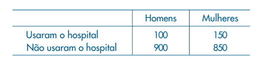

Calcule a proporção de homens entre os indivíduos que usaram o hospital.

1. 0,45
2. 0,5
3. 0,05
4. 0,075
5. 0,1

QUESTÃO 78 - 1  
A frequência relativa é:

1. Número total de observações
2. Proporção de cada categoria
3. Soma das frequências
4. Média dos valores
5. Desvio dos dados

RESPOSTA: B  
A frequência relativa equivale a proporção de cada categoria dentro de uma tabela de contingência

QUESTÃO 79 - 2  
Considere dois eventos A e B mutuamente exclusivos, sendo a P(A)=0,5, a P(B)=x e a P(AUB)= 0,8.  
Determine o valor de x

1. 0,5
2. 0,8
3. 0,3
4. 0,2
5. 0,6

RESPOSTA: C  
Se os eventos A e B são mutuamente exclusivos  
P(AUB) = P(A) + P(B)  
0,8=0,5+x  
0,8-0,5=x  
x = 0,3

QUESTÃO 80 - 2  
A probabilidade de um evento impossível é:

1. 1
2. 0,5
3. 0
4. Negativa
5. Maior que 1

RESPOSTA: C  
A probabilidade de um evento impossível é zero. Isso significa que não há nenhuma chance de ocorrência, representando um conjunto vazio dentro do espaço amostral.

QUESTÃO 81 - 2  
O complemento de um evento A é:

1. Outro evento independente
2. Evento impossível
3. Tudo que não é A
4. Evento certo
5. Interseção com A

RESPOSTA: C

QUESTÃO 82 - 2  
Considere A o evento: sair um número par. Calcule P(A) ao rolar um dado justo

1. 1/6
2. 1/4
3. 1/36
4. 2/6
5. 1/2

RESPOSTA: E  
Números pares em um dado: 2, 4, 6  
P(A)= 3/6 = 0,5

QUESTÃO 86 - 3  
Em um teste de hipóteses, obteve-se valor-p = 0,03. Qual afirmação é correta?  
A) Rejeita-se H0 para qualquer nível de significância alpha.  
B) Não se rejeita H0 para alpha=0,05.  
C) Rejeita-se H0 para alpha=0,05, mas não necessariamente para alpha=0,01.  
D) O valor-p é a probabilidade de H0 ser verdadeira.  
E) O valor-p independe dos dados amostrais.  
RESPOSTA: C  
O valor-p é o menor nível de significância (alpha) para o qual H0 seria rejeitada com os dados observados.  
Assim, se alpha=0,05 (>0,03), rejeitamos H0; se alpha=0,01 (<0,03), não rejeitamos H0.

QUESTÃO 87 - 3  
Em um teste de hipóteses, o erro do tipo I é:  
A) Aceitar H0 quando H0 é falsa.  
B) Rejeitar H0 quando H0 é verdadeira.  
C) Rejeitar H1 quando H1 é verdadeira.  
D) Aceitar H1 quando H1 é falsa.  
E) Tomar qualquer decisão quando alpha=0.  
RESPOSTA: B  
Por definição, erro tipo I ocorre quando rejeitamos a hipótese nula H0 sendo ela verdadeira (probabilidade alpha).

QUESTÃO 89 - 1  
Considere as variáveis observadas em uma pesquisa: (I) estado civil (solteiro, casado, …); (II) número de filhos; (III) peso (kg); (IV) grau de instrução (fundamental, médio, superior). A classificação correta (qualitativa nominal/ordinal; quantitativa discreta/contínua) é:  
A) I nominal; II discreta; III contínua; IV ordinal.  
B) I ordinal; II contínua; III discreta; IV nominal.  
C) I nominal; II contínua; III contínua; IV nominal.  
D) I ordinal; II discreta; III contínua; IV nominal.  
E) I nominal; II discreta; III discreta; IV ordinal.  
RESPOSTA: A  
I: qualitativa nominal (não há ordenação). II: quantitativa discreta (contagem). III: quantitativa contínua (mensuração). IV: qualitativa ordinal (há ordenação: fundamental < médio < superior).

QUESTÃO 90 - 1  
Em uma turma com n = 40 alunos, 10 reprovaram. A frequência relativa f e a porcentagem correspondente são:  
A) f = 10/40 = 0,25 e 25%.  
B) f = 10/40 = 0,40 e 40%.  
C) f = 40/10 = 4 e 4%.  
D) f = 30/40 = 0,75 e 75%.  
E) f = 10/40 = 2,5 e 2,5%.  
RESPOSTA: A  
Por definição, f = ni /n.  
Logo, f = 10/40 = 0,25 e 100·f = 25%.

QUESTÃO 91 - 1  
Os valores (em horas) de estudo de 5 alunos foram: 2, 3, 3, 4, 8. A média amostral x̄ é:  
A) x̄ = (2+3+3+4+8)/5 = 4.  
B) x̄ = (2+3+3+4+8)/5 = 5.  
C) x̄ = (2+3+3+4+8)/4 = 5.  
D) x̄ = (2+3+3+4+8)/5 = 3.  
E) x̄ = (2·3·3·4·8)^(1/5) = 4.  
RESPOSTA: A  
Somando: 2+3+3+4+8 = 20. Então x̄ = 20/5 = 4.

QUESTÃO 92 - 1  
Para a amostra 1, 2, 3, calcule a variância amostral s² (com denominador n−1).  
A) s² = 1.  
B) s² = 2/3.  
C) s² = 2.  
D) s² = 1/3.  
E) s² = 3.  
RESPOSTA: A  
x̄ = (1+2+3)/3 = 2.  
Σ(xi −x̄)² = (1−2)²+(2−2)²+(3−2)² = 1+0+1 = 2.  
s² = Σ(xi −x̄)²/(n−1) = 2/(3−1) = 1.

QUESTÃO 94 - 3  
Considere os pares (x,y): (1,1), (2,2), (3,3). O coeficiente de correlação linear de Pearson r é:  
A) r = 0.  
B) r = −1.  
C) r = 1.  
D) r = 1/2.  
E) r = −1/2.  
RESPOSTA: C  
Aqui y = x exatamente, logo há associação linear perfeita positiva. Formalmente, r = cov(x,y)/(sx sy ) = 1.

QUESTÃO 95 - 2  
Se P(A)=0,40, P(B)=0,35 e P(A∩B)=0,10, então P(A∪B) é:  
A) 0,75  
B) 0,65  
C) 0,50  
D) 0,25  
E) 0,85  
RESPOSTA: B  
P(A∪B) = P(A)+P(B)−P(A∩B) = 0,40+0,35−0,10 = 0,65.

QUESTÃO 96 - 2  
Dados P(A)=0,30, P(B)=0,50 e P(A∩B)=0,12. A e B são independentes?  
A) Sim, pois P(A∩B)=P(A)+P(B).  
B) Sim, pois P(A∩B)=P(A)·P(B).  
C) Não, pois P(A∩B)≠P(A)·P(B).  
D) Não, pois P(A|B)=P(B|A).  
E) Sim, pois P(A|B)=P(A)−P(B).  
RESPOSTA: C  
Independência exige P(A∩B)=P(A)·P(B)=0,30·0,50=0,15. Como 0,12≠0,15, não são independentes.

QUESTÃO 98 - 2  
Uma v.a. discreta X assume valores 0, 1, 2 com probabilidades 0,2; 0,5; 0,3. E(X) é:  
A) E(X)=0·0,2+1·0,5+2·0,3=1,1.  
B) E(X)=0·0,2+1·0,5+2·0,3=0,8.  
C) E(X)=0+1+2=3.  
D) E(X)=0,2+0,5+0,3=1.  
E) E(X)=1·0,2+2·0,5+3·0,3=2,1.  
RESPOSTA: A  
E(X)=Σ x·P(X=x)=0·0,2+1·0,5+2·0,3=0+0,5+0,6=1,1.

QUESTÃO 100 - 2  
Se X ~ U(0,10), então P(3 ≤ X ≤ 7) é:  
A) (7−3)/(10−0)=0,4.  
B) (7−3)/(10−0)=0,7.  
C) (3−7)/(10−0)=−0,4.  
D) 7/10=0,7.  
E) 3/10=0,3.  
RESPOSTA: A  
Para U(a,b), P(c ≤ X ≤ d) = (d−c)/(b−a). Aqui: (7−3)/10 = 4/10 = 0,4.

QUESTÃO 101 - 2  
Se X ~ N(μ=50, σ=10), qual é P(X≤60)? Use Φ(1)=0,8413.  
A) 0,1587  
B) 0,5000  
C) 0,8413  
D) 0,9000  
E) 0,9772  
RESPOSTA: C  
Padronizando: Z=(X−μ)/σ.  
Para x=60: z=(60−50)/10=1.  
Logo P(X≤60)=P(Z≤1)=Φ(1)=0,8413.

QUESTÃO 102 - 2  
Se T ~ Exp(λ), qual expressão é sempre verdadeira para s,t>0?  
A) P(T>s+t | T>s) = P(T>t).  
B) P(T≤s+t | T≤s) = P(T≤t).  
C) P(T>s+t) = P(T>s)+P(T>t).  
D) P(T>s+t) = P(T>s)·P(T>t) para qualquer distribuição contínua.  
E) P(T>s+t | T>s) = P(T>s+t).  
RESPOSTA: A  
A exponencial tem a propriedade sem memória: P(T>s+t | T>s)=P(T>t). As demais alternativas não valem em geral.

QUESTÃO 103 - 2  
Considere a p.m.f. conjunta de (X,Y) dada por: P(X=0,Y=0)=0,2; P(0,1)=0,3; P(1,0)=0,1; P(1,1)=0,4. Calcule cov(X,Y).  
A) cov(X,Y)=0,05  
B) cov(X,Y)=−0,05  
C) cov(X,Y)=0  
D) cov(X,Y)=0,10  
E) cov(X,Y)=−0,10  
RESPOSTA: A  
E(X)=P(X=1)=0,1+0,4=0,5.  
E(Y)=P(Y=1)=0,3+0,4=0,7.  
E(XY)=0·0·0,2 + 0·1·0,3 + 1·0·0,1 + 1·1·0,4 = 0,4. cov(X,Y)=E(XY)−E(X)E(Y)=0,4−(0,5)(0,7)=0,4−0,35=0,05.  
QUESTÃO 104 - 2  
Seja X uma variável aleatória discreta que segue o modelo Uniforme com os valores no conjunto {1, 2, 3,…, 10}. Calcule P(X<= 9 | X>=6)

1. 0,9
2. 0,45
3. 0,4
4. 0,8
5. 0,3

RESPOSTA: D  
P(X<=9 | X>=6) = P(X<=9 | X>=6) / P(X>=6) = 4/5 = 0.8

1. 2,52x10^-5
2. 3,54x10^-5
3. 1,47x10^5
4. 2,78x10^-4
5. 1,98x10^4

RESPOSTA: A  
P(X≥14)=P(X=14)+P(X=15)  
P(X=14)= C(15,14) * (0,4)^14 * (0,6)^1 = 2,41×10^−5  
P(X=15)= C(15,15) * (0,4)^15 * (0,6)^0 = 1,07×10^−6

P(X=14)+P(X=15) = 2,41×10^−5 + 1,07×10^−6 = 2,52×10^−5

QUESTÃO 106 - 2  
Uma companhia produz circuitos em três fábricas, I, II e III. A fábrica I produz 40% dos circuitos, enquanto a II e a III produzem 30% cada uma. As probabilidades de que um circuito integrado produzido por essas fábricas não funcione são 0,01, 0,04 e 0,03, respectivamente. Escolhido um circuito da produção conjunta das três fábricas, qual a probabilidade de o mesmo não funcionar?

1. 0,03
2. 0,4
3. 0,025
4. 0,35
5. 0,25

RESPOSTA: C  
Eventos: I,II,III (fábrica)  
D (defeituoso)  
P(I): 0,4; P(II): 0,3; P(III): 0,3  
P(D|I): 0,01; P(D|II): 0,04; P(D|III): 0,03  
Assim, P(D) = P(I) * P(D|I) + P(II) * P(D|II) + P(III) * P(D|III)  
P(D) = 0,4*0,01 + 0,3*0,04 + 0,3*0,03 = 0,025

QUESTÃO 107 - 2  
Em uma fábrica de parafusos, as máquinas A, B e C produzem 25%, 35% e 40% do total, respectivamente. Da produção de cada máquina 5%, 4% e 2%, respectivamente, são parafusos defeituosos. Escolhe-se ao acaso um parafuso e verifica-se que é defeituoso. Qual a probabilidade de que o parafuso venha da máquina A?

1. 0,025
2. 0,40
3. 0,2
4. 0,0345
5. 0,512

P(D∣A)=0,05  
P(D∣B)=0,04  
P(D∣C)=0,02

Teorema de Bayes:  
P(A∣D) = ( P(D∣A) * P(A) ) / P(D)

Para calcularmos o Teorema de Bayes, é necessário encontrar P(D)  
Como P(D) = P(A) * P(D|A) + P(B) * P(D|B) + P(C) * P(D|C)  
P(D) = 0,25*0,05 + 0,35*0,04 + 0,40*0,02  
P(D) = 0,0125 + 0,014 + 0,008 = 0,0345

QUESTÃO 108 - 2  
Uma moeda é lançada duas vezes e observam-se as faces obtidas. Descreva o espaço amostral considerando K para coroa e C para cara

1. {C,K}
2. {C, CK, K}
3. (CK, KC, K}
4. {CC, CK, KC, KK}
5. {CC, KC, CK, KK, C, K}

RESPOSTA: D  
As combinações possíveis em dois lançamentos de uma moeda são:  
CARA, CARA  
CARA, COROA  
COROA, CARA  
COROA, COROA

QUESTÃO 109 - 2  
Dois dados são lançados simultaneamente e estamos interessados na soma das faces observadas. Considerando A o evento “Saírem apenas somas pares”, calcule P(A)

1. 0,02
2. 0,5
3. 0,36
4. 0,9
5. 0,18

RESPOSTA: B  
Os resultados para somas pares são:  
Opção 1= Dado 1: par + Dado 2: par = soma par  
Opção 2= Dado 1: ímpar + Dado 2: ímpar = soma par

Assim, a probabilidade da primeira opção é  
3/6 * 3/6 = 9/36  
E a probabilidade da segunda opção é  
3/6 * 3/6 = 9/36

Somando as duas opções:  
9/36 + 9/36 = 18/36 = 0,5

QUESTÃO 110 - 2  
Um determinado tipo de bateria é produzido por duas linhas de montagem, L₁ e L2. A linha L₁, possui uma capacidade de produzir quatro vezes mais baterias do que a linha L2. Sabe-se, através do controle de qualidade que 2% das baterias produzidas por L₁ são defeituosas e 5% das baterias produzidas por L2 são defeituosas. Todas as baterias das duas linhas são enviadas a um depósito central.  
Se uma bateria for retirada aleatoriamente desse depósito, a probabilidade de essa bateria ser defeituosa é

1. 0,016
2. 0,018
3. 0,020
4. 0,024
5. 0,026

RESPOSTA: E  
Como L1 possui capacidade de produzir quatro vezes mais baterias do que a linha L2 e sabendo que a soma das probabilidades deve ser 1,  
P(L1) = 4x  
P(L2) = x  
x + 4x = 1  
5x = 1  
x = 0,2  
P(L1) = 0,8 e P(L2) = 0,2  
E sabendo que 0,02 das baterias produzidas por L₁ são defeituosas e 0,05 das baterias produzidas por L2 são defeituosas.  
A probabilidade da bateria ser defeituosa é  
0,02 x 0,8 + 0,2 x 0,05 = 0,026

QUESTÃO 111 - 1  
Uma entidade realizou um teste de proficiência da língua inglesa com seus gerentes. A entidade deseja saber o seguinte:  
I. A média das notas dos gerentes.  
II. A distribuição da frequência de cada nota dos gerentes.  
III. A proficiência do idioma entre os diretores que possuem características semelhantes aos gerentes.  
Ao utilizar a estatística descritiva, foi possível obter as seguintes informações:

1. I, somente.
2. I e II, somente.
3. I e III, somente.
4. II e III, somente.
5. I, II e III.

RESPOSTA: B

QUESTÃO 112 - 3  
Uma variável aleatória X tem distribuição normal, com média 100 e desvio padrão 10. Qual a P(90 < X < 110)?

1. 0,6826
2. 0,8974
3. 0,6954
4. 0,1495
5. 0,3248

RESPOSTA: A  
X∼N(μ=100, σ=10)  
Assim, Z = (X−μ) / σ  
Para 90: (90 - 100)/10 = -1  
Para 110: (110-100)/10 =1  
Dessa forma,  
P(90<X<110) = P(−1<Z<1)  
Usando a Tabela Normal:  
P(Z<-1) = 0,1587  
P(Z<1) = 0,8413  
0,8413 - 0,1587 = 0,6826  
QUESTÃO 113 - 3  
Uma variável aleatória X tem distribuição normal, com média 100 e desvio padrão 10. Qual a P(90 < X < 110)?

1. 0,6826
2. 0,8974
3. 0,6954
4. 0,1495
5. 0,3248

RESPOSTA: A  
X∼N(μ=100, σ=10)  
Assim, Z = (X−μ) / σ  
Para 90: (90 - 100)/10 = -1  
Para 110: (110-100)/10 =1  
Dessa forma,  
P(90<X<110) = P(−1<Z<1)  
Usando a Tabela Normal:  
P(Z<-1) = 0,1587  
P(Z<1) = 0,8413  
0,8413 - 0,1587 = 0,6826

QUESTÃO 114 - 3  
Uma população tem distribuição normal com média 100 e desvio padrão 10. Uma amostra de tamanho (n) 16 é retirada dessa população.  
Qual é o valor aproximado de P(90<Xˉ<110)? (Xˉ : média amostral)  
(Dado: e σ =2,5)

1. 0,68
2. 0,841
3. 0,95
4. 0,997
5. 0,50

RESPOSTA: D  
Desvio padrão da média amostral:  
σ / raiz quadrada de n = 10/4 =2.5  
Assim, Xˉ∼N(100;2,5)  
Padronização:  
(Xˉ - μ) / σ  
Para 90  
90-100 / 2,5 = -4  
Para 110  
110-100 / 2,5 = 4  
Na Tabela Normal:  
P(-4 < X < 4) = 0,997  
Logo, o valor aproximado de P(90<Xˉ<110) é 0,997

QUESTÃO 115 - 3  
O peso dos pacotes produzidos por uma máquina segue distribuição normal com desvio padrão 10 g.  
Em quanto deve ser regulada a média μ para que apenas 10% dos pacotes tenham peso inferior a 500 g?  
(Dado: Z 0,10=−1,28)

1. 500 g
2. 505 g
3. 510 g
4. 512,8 g
5. 520 g

RESPOSTA: D  
X: peso dos pacotes produzidos  
X ~ N(μ,10)

P(X<500) = ?

Padronização:  
Z = (X - μ) / σ  
Usando Z 0,10 = -1,28 e aplicando os dados na fórmula acima, temos:  
-1,28 = (500-μ) / 10  
-1,28 x 10 = 500 - μ  
-12,8 = 500 - μ  
-12,8 - 500 = - μ  
-512,8 = -μ  
μ = 512,8  
Conclui-se que a média deve ser regularizada em 512,8g para que apenas 10% dos pacotes tenham peso inferior a 500 g

QUESTÃO 116 - 3  
A associação dos proprietários de indústrias metalúrgicas está muito preocupada com o tempo perdido com acidentes de trabalho, cuja média, nos últimos tempos, tem sido da ordem de 60 horas/homem por ano e desvio padrão de 20 horas/homem.  
Tentou-se um programa de prevenção de acidentes, após o qual foi tomada uma amostra de nove indústrias e medido o número de horas/homens perdidas por acidente, que foi de 50 horas. Você diria, no nível de 5%, que há evidência de melhoria?

1. Sim, pois Z=−1,50<−1,645
2. Sim, pois Z=−2,00
3. Não, pois Z=−1,50>−1,645
4. Não, pois Z=−0,75
5. Sim, pois Z=−0,5

RESPOSTA: C  
Hipóteses:  
H0: μ = 60  
H1: μ < 60  
Fórmula: (Considere Xˉ a média amostral)  
Z = (Xˉ - μ) / (σ / raiz quadrada de n)  
Substituindo os valores:  
Z = (50 - 60) / (20/3) = -1.5  
Considerando Z= -1,5 e o valor crítico (5% unilateral) = -1,645  
Como −1,50 > −1,645, não há evidências suficientes de melhoria.

QUESTÃO 117 - 3  
O salário médio dos empregados das indústrias siderúrgicas de um país é de 2,5 salários mínimos, com um desvio padrão de 0,5 salários mínimos. Uma indústria é escolhida ao acaso e desta é escolhida uma amostra de 49 empregados, resultando um salário médio de 2,3 salários mínimos. Podemos afirmar que esta indústria paga salários inferiores à média nacional, com o nível de 5%?

1. Não, pois Z=−1,64
2. Sim, pois Z=−2,80
3. Não, pois Z=−0,40
4. Sim, pois Z=2,80
5. Não, pois o valor-p > 0,05

RESPOSTA: B  
Hipóteses:  
H0: μ=2,5  
H1: μ<2,5  
Fórmula: (Considere Xˉ a média amostral)  
Z = (Xˉ - μ) / (σ / raiz quadrada de n)  
Substituindo os valores:  
Z= 2,3 - 2,5 / (0,5 / raiz de 49) = -2,8  
Considerando Z= -2,8 e o valor crítico (5% unilateral) = -1,645, temos que:  
-2,8 < −1,645, rejeitamos H0, então a indústria paga menos que a média nacional**.**

QUESTÃO 118 - 3  
Uma companhia de cigarros anuncia que o índice médio de nicotina dos cigarros que fabrica apresenta-se abaixo de 23 mg por cigarro.  
Um laboratório realizou 6 análises desse índice, obtendo: 27, 24, 21, 25, 26, 22. Sabe-se que o índice de nicotina se distribui normalmente, com variância igual a 4,86 mg2. Pode-se aceitar, no nível de 10%, a afirmação do fabricante?

RESPOSTA:  
Média: (27+24+21+25+26+22)/6 = 24,17  
Hipóteses:  
H0: μ=23  
H1: μ>23  
Fórmula: (Considere Xˉ a média amostral)  
Z = (Xˉ - μ) / (σ / raiz quadrada de n)  
Substituindo os valores:  
(Como a variância é 4,86, o desvio padrão é 2,205)  
Z= 24,17 - 23 / (2,205 / raiz de 6) = 1,3  
Considerando Z= 1,3 e o valor crítico (10% unilateral) = 1,28, temos que:  
1,30>1,28, assim, rejeitamos H0, não se pode aceitar a afirmação do fabricante.

QUESTÃO 119 - 3  
Assinale a alternativa correta:

1. Um parâmetro é uma medida calculada a partir da amostra.
2. Um estimador é um valor numérico fixo obtido após o cálculo
3. Uma estimativa é a regra matemática usada para calcular um parâmetro.
4. Um parâmetro é uma característica da população, geralmente desconhecida.
5. Um estimador é sempre igual ao parâmetro.

RESPOSTA: D

QUESTÃO 120 - 3  
Em um teste de hipóteses estatístico, o objetivo principal é:

1. Determinar com certeza absoluta se a hipótese nula é verdadeira
2. Comparar um parâmetro populacional com informações obtidas de uma amostra.
3. Calcular o desvio padrão da população.
4. Substituir o parâmetro populacional pela média amostral.
5. Garantir que o resultado seja sempre significativo

RESPOSTA: B

QUESTÃO 121 - 3  
O teste Qui-quadrado de independência é utilizado para:

1. Comparar médias de duas populações normais.
2. Testar igualdade de variâncias.
3. Verificar associação entre duas variáveis qualitativas.
4. Estimar intervalo de confiança para proporções.
5. Testar normalidade.

RESPOSTA: C

QUESTÃO 122 - 3  
Uma pesquisadora quer saber se existe relação entre gênero (masculino/feminino) e preferência por modalidade de aula (presencial/online).  
Qual teste estatístico é mais adequado para analisar essa situação?

1. Teste t para médias
2. Regressão linear simples
3. Teste Qui-quadrado
4. Intervalo de confiança para média
5. Correlação de Pearson

RESPOSTA: C

QUESTÃO 123 - 1  
Responda verdadeiro (V) ou falso (F):  
1) Suponha duas amostras colhidas de uma mesma população, sendo uma de tamanho 100 e outra de tamanho 200. Então, a amostra de tamanho maior é mais representativa da população.  
2) Duas variáveis com valores diferentes podem apresentar histogramas iguais.  
3) Duas variáveis com box-plot iguais não podem ter valores diferentes.

1. V, F, F
2. F, V, F
3. F, V, V
4. V, V, F
5. F, F, V

RESPOSTA: B

QUESTÃO 124 - 1  
Um grupo de pedagogos estuda a influência da troca de escolas no  
desempenho de alunos do ensino fundamental. Como parte do levantamento  
realizado, foi anotado o número de escolas cursadas pelos alunos participantes do estudo.

| ESCOLAS CURSADAS | FREQUÊNCIA |
| --- | --- |
| 1 | 46 |
| 2 | 57 |
| 3 | 21 |
| 4 | 15 |
| 5 | 54 |

Qual a porcentagem dos alunos que cursam mais de uma escola?

1. 76%
2. 30%
3. 82%
4. 54%
5. 23%

RESPOSTA: A  
Quantidade de alunos que cursam mais de uma escola (2 ou mais):  
57 + 21 + 15 + 54 = 147  
Quantidade de alunos total:  
46 + 57 + 21 + 15 + 54 = 193  
147 / 193 = 0.762  
0,762 * 100% = 76%

QUESTÃO 125 - 1  
Alunos da Escola de Educação Física foram submetidos a um teste de  
resistência quanto ao número de quilômetros que conseguiram correr sem parar. Qual é a classificação da variável em estudo segundo os tipos de variáveis?

1. Variável quantitativa contínua
2. Variável qualitativa nominal
3. Variável quantitativa discreta
4. Variável qualitativa ordinal
5. Variável qualitativa discreta

RESPOSTA: A  
Variável quantitativa contínua porque a distância é uma grandeza que pode assumir qualquer valor real

QUESTÃO 126 - 1  
O tempo de utilização de caixas eletrônicos depende de cada usuário e das  
operações efetuadas. Foram coletadas 10 medidas desse tempo (em minutos): 1,1; 1,7; 1,5; 0,9; 1,3; 1,4; 1,6; 1,7; 1,6; 1,0  
Assinale a alternativa correta:

1. A média de tempo de utilização de caixas eletrônicos é 1,6
2. A amplitude do tempo de utilização de caixas eletrônicos é 0,8
3. A mediana do tempo de utilização de caixas eletrônicos é 1,3
4. A moda do tempo de utilização de caixas eletrônicos é 1,1
5. O desvio padrão do tempo de utilização de caixas eletrônicos é 1,4

RESPOSTA: B  
Valor máximo: 1,7  
Valor mínimo: 0,9  
Amplitude total: 1,7 - 0,9 = 0,8

QUESTÃO 127 - 1  
Foram feitas medidas em operários da construção civil a respeito da taxa de  
hemoglobina no sangue (em gramas/cm³):  
15,8; 14,7; 13,5; 12,7; 12,3; 13,5; 15,4; 16,3; 15,2; 12,3; 13,7; 14,1  
Determine o terceiro quartil e a mediana.

1. 16,2 e 15
2. 15,3 e 13,9
3. 15,3 e 12,6
4. 16,2 e 13,9
5. 12,8 e 11,5

RESPOSTA: B  
Ordem crescente:  
12,3; 12,3; 12,7; 13,5; 13,5; 13,7; 14,1; 14,7; 15,2; 15,4; 15,8; 16,3

Como temos 12 valores (n=12), n é par, logo, a mediana é a média entre o 6º e o 7º valores.

12,3; 12,3; 12,7; 13,5; 13,5; 13,7; 14,1; 14,7; 15,2; 15,4; 15,8; 16,3

(13,7+14,1)/2 = 13,9

Para n par, Q3 é a mediana da metade superior.

Metade superior:

14,1; 14,7; 15,2; 15,4; 15,8; 16,3

Q3 = média do 3º e 4º: (15,2+15,4)/2 = 15,3

QUESTÃO 128 - 1  
Uma pesquisa coletou os dados de idade de 30 pacientes em uma clínica. Calcule: média, moda e mediana  
34; 27; 45; 51; 39; 63; 29; 48; 56; 31; 40; 36; 42; 54; 47; 50; 38; 33; 60; 52; 37; 43; 35; 46; 49; 55; 32; 41; 44; 30

1. 42,9; 38 e 42,5
2. 43; 42,9 e 43
3. 42,9; não há e 42,5
4. 42,5; não há e 42,9
5. 45; 42,6 e 47

RESPOSTA: C  
Média:  
34+ 27+ 45+ 51+ 39+ 63+ 29+ 48+ 56+ 31+ 40+ 36+ 42+ 54+ 47+ 50+ 38+ 33+ 60+ 52+ 37+ 43+ 35+ 46+ 49+ 55+ 32+ 41+ 44+ 30 = 1287  
1287 / 30 = 42.9  
Moda: não há valor que se repete, logo, não há moda  
Mediana: como n é par (n=30) a mediana é a média entre o 15º e 16º valor  
Ordem crescente:  
27; 29; 30; 31; 32; 33; 34; 35; 36; 37; 38; 39; 40; 41; 42; 43; 44; 45; 46; 47; 48; 49; 50; 51; 52; 54; 55; 56; 60; 63  
(42 + 43) / 2 = 42.5

QUESTÃO 129 - 3  
Considerando x a idade e P o peso, analise o modelo de regressão linear simples e responda: P=2+3x  
O que o valor 2 representa?

1. O peso quando a idade é 3
2. O peso quando a idade é 0
3. O aumento do peso por ano
4. A idade mínima
5. O peso médio

RESPOSTA: B  
Quando a idade(x) for 0,  
P= 2 + 3*0 = 2

QUESTÃO 130 - 3  
O coeficiente de correlação de Pearson entre anos de estudo e salário em um grupo de pessoas foi r=0,85  
Esse valor indica:

1. Não há correlação entre as variáveis
2. Há correlação fraca
3. Há correlação forte e positiva
4. Há correlação forte e negativa
5. Não há regressão possível

RESPOSTA: C  
Como o valor da correlação de Pearson foi 0,85 (próximo de 1), existe correlação forte e positiva.

QUESTÃO 131 - 3  
Em um estudo sobre horas de exercício físico por semana (x) e nível de colesterol (y) , obteve-se: y = 210 - 3x e a correlação de Pearson: r=0,70  
A interpretação correta é:

1. Mais exercício aumenta o colesterol
2. Mais exercício reduz o colesterol e a relação é moderada/forte
3. Não há relação
4. O colesterol não depende do exercício
5. A relação é positiva

RESPOSTA: B

QUESTÃO 132 - 3  
Em um estudo que relaciona horas de estudo e nota, a variável explicativa (X) é:

1. A nota
2. A média da turma
3. As horas de estudo
4. O erro
5. O coeficiente angular

RESPOSTA: C

QUESTÃO 133 - 3  
Em um estudo entre anos de estudo e salário, obteve-se R^2=0,64. Isso significa que:

1. 64% do salário é causado pelos estudos
2. 64% da variação do salário é explicada pelos anos de estudo
3. 64% das pessoas têm salário alto
4. O salário aumenta 64 unidades
5. A correlação é negativa

RESPOSTA: B

QUESTÃO 134 - 3  
Considere o modelo: Salário = 1000 + 200x (anos de estudo)  
Qual o salário estimado para uma pessoa com 12 anos de estudo?

1. 2200
2. 2400
3. 2600
4. 3000
5. 3400

RESPOSTA: E  
y = 1000 + 200x  
se x (anos de estudo) = 12  
y = 1000 + 200 * 12 = 3400  
QUESTÃO 135 - 2  
Ao lançar um dado honesto uma vez, qual é o espaço amostral?

1. {0,1,2,3,4,5}
2. {1,2,3,4,5,6}
3. {1,2,3,4,5}
4. {2,3,4,5,6,7}
5. {cara, coroa}

RESPOSTA: B  
O espaço amostral é o conjunto de todos os resultados possíveis. Num dado, os resultados possíveis são: {1,2,3,4,5,6}

QUESTÃO 136 - 2  
Uma urna tem 3 bolas vermelhas (V) e 2 bolas azuis (A). Ao retirar uma bola da urna e observar sua cor, qual o espaço amostral?

1. {V, A}
2. {V1, V2, V3, A1, A2}
3. {1,2,3,4,5}
4. {V, V, V, A, A}
5. {V∩A, V∪A}

RESPOSTA: A  
Ao observar apenas a cor, os resultados possíveis são: bola vermelha (V) ou bola azul (A)

QUESTÃO 137 - 2  
Ao lançar dois dados honestos, quantos resultados possíveis existem no espaço amostral?

1. 6
2. 12
3. 18
4. 72
5. 36

RESPOSTA: E  
Cada dado possui 6 possibilidades, como são dois dados: 6 * 6 = 36 resultados possíveis

QUESTÃO 138 - 2  
Pelo axioma, qual afirmação é sempre verdadeira para qualquer evento A?

1. P(A) pode ser negativa
2. P(A) pode ser maior que 1
3. 0 ≤ P(A) ≤ 1
4. P(A)=1 somente se A é impossível
5. P(A)=0 somente se A é certo

RESPOSTA: C  
Para qualquer evento A, sua probabilidade sempre fica entre 0 e 1.

QUESTÃO 139 - 2  
Se P(A)=0,62, qual é a probabilidade do complemento de A?

1. 0,38
2. 0,62
3. 1,62
4. 0,34
5. 0,28

RESPOSTA: A  
O complemento de A:  
1 - P(A) = 1 - 0,62 = 0,38

QUESTÃO 140 - 2  
Se P(A)=0,5, P(B)=0,4 e P(A∩B)=0,2, então qual é a P(A∪B)?

1. 0,70
2. 0,94
3. 0,21
4. 0,39
5. 0,40

RESPOSTA: A  
Usando a fórmula: P(A∪B)=P(A)+P(B)−P(A∩B)  
P(A∪B)= 0,5 + 0,4 - 0,2  
P(A∪B) = 0,7

QUESTÃO 141 - 2  
Considere que P(A)=0,5 e P(B|A)=0,8. Calcule a P(A∩B):

1. 0,4
2. 0,8
3. 0,3
4. 1,3
5. 0,1

RESPOSTA: A  
Aplicando a fórmula: P(A∩B)=P(A)·P(B|A)  
P(A∩B)= 0,5 * 0,8 = 0,4

QUESTÃO 142 - 2  
Uma doença atinge apenas 2% da população. Sabe-se que o teste dessa doença dá positivo em 95% dos doentes e falso positivo em 5% dos não doentes. Considerando que uma pessoa testou positivo, qual a probabilidade dela estar doente?

1. 0,28
2. 0,02
3. 0,95
4. 0,52
5. 0,98

RESPOSTA: A  
Dados do problema  
Probabilidade de estar doente: P(D)=0,02  
Probabilidade de não estar doente: P(D^c)=0,98  
Teste positivo se a pessoa está doente: P(+∣D)=0,95  
Falso positivo: P(+∣D^c)=0,05  
Probabilidade que queremos encontrar (probabilidade de estar doente sabendo que o teste deu positivo): P(D∣+)

Agora vamos aplicar Bayes  
P(D∣+)=P(+∣D)P(D) / P(+)  
P(D∣+)=0,95⋅0,02 / 0,068  
P(D∣+)=0,019 / 0,068  
P(D∣+) = 0,279 = 0,28

QUESTÃO 143 - 2  
Considere uma urna contendo três bolas pretas e cinco bolas vermelhas. Retire duas bolas da urna, sem reposição e calcule a probabilidade de sair uma bola preta na primeira e segunda extrações

1. 0,521
2. 0,375
3. 0,286
4. 0,107
5. 0,518

RESPOSTA: D  
Temos 3 bolas pretas (P) e 5 bolas vermelhas (V), no total, 8 bolas  
Existem 3 bolas pretas em 8 bolas totais, então a probabilidade de sair 1 bola preta: 3/8 = 0,375  
Como não há reposição, agora restam 2 bolas pretas e 7 totais, então a probabilidade da segunda ser preta (sabendo que a primeira foi preta): 2/7 = 0,286  
Multiplicando as probabilidades: 0,375 * 0,286 = 0,1071

QUESTÃO 144 - 1  
Considere dois conjuntos:  
Conjunto A: 10, 10, 10, 10, 10  
Conjunto B: 5, 8, 10, 12, 15  
Ambos têm média igual a 10. Sobre a dispersão, podemos afirmar que:

1. Ambos têm o mesmo desvio padrão
2. O conjunto A tem maior variabilidade
3. O conjunto B tem maior variabilidade
4. Ambos têm amplitude igual
5. Não é possível comparar

RESPOSTA: C  
No conjunto A, todos os valores são iguais, logo, não há variabilidade.  
No conjunto B, há valores de 5 a 15, então há variabilidade  
Portanto, o conjunto B apresenta maior dispersão

QUESTÃO 145 - 1  
Em uma empresa, a maioria dos funcionários ganha entre R$ 2.000 e R$ 3.000, mas alguns diretores ganham acima de R$ 20.000.  
Essa distribuição tende a apresentar:

1. Assimetria negativa
2. Assimetria nula
3. Assimetria positiva
4. Curtose negativa
5. Distribuição uniforme

RESPOSTA: C  
A maioria ganha valores menores, mas há poucos salários muito altos, “puxando” a média para cima. Isso gera uma cauda à direita, chamada de assimetria positiva.

QUESTÃO 146 - 1  
Em uma pesquisa com 100 pessoas, podemos afirmar que:

|  | PRATICAM ESPORTE | NÃO PRATICAM ESPORTE |
| --- | --- | --- |
| FEMININO | 10 | 40 |
| MASCULINO | 30 | 20 |

1. 70% praticam esporte
2. 50% são homens
3. 40% das mulheres praticam esporte
4. 60% não praticam esporte
5. Homens praticam menos esporte que mulheres

RESPOSTA: B  
Total de homens: 30 + 20 = 50  
Total geral: 10 + 40 + 30 + 20 =100  
50 / 100 = 0.5 = 50%

QUESTÃO 147 - 3  
Uma pesquisa deseja conhecer a renda média mensal de todos os professores de uma cidade. Para isso, coleta dados de 120 professores escolhidos aleatoriamente. Assinale a alternativa correta:

1. A média calculada com os 120 professores é um parâmetro.
2. A renda média de todos os professores da cidade é uma estimativa.
3. A média calculada com os 120 professores é um estimador.
4. A renda média de todos os professores da cidade é um parâmetro.
5. Os 120 professores representam o parâmetro.

RESPOSTA: D

QUESTÃO 148 - 3  
Considere as seguintes afirmações:  
I – A média populacional é um parâmetro.  
II – A média amostral é um estimador da média populacional.  
III – O valor numérico calculado na amostra é uma estimativa.  
Está correto o que se afirma em:

1. Apenas I
2. Apenas I e II
3. Apenas II e III
4. I, II e III
5. Apenas III

RESPOSTA: D

QUESTÃO 149 - 3  
Uma fábrica deseja conhecer o peso médio de todos os pacotes produzidos diariamente. Como seria inviável pesar todos os pacotes, foram escolhidos 50 pacotes aleatoriamente e calculada a média de seus pesos.  
Nesse contexto, é correto afirmar que:

1. O peso médio dos 50 pacotes é um parâmetro.
2. O peso médio de todos os pacotes produzidos é uma estimativa.
3. O peso médio dos 50 pacotes é uma estimativa do parâmetro populacional.
4. Os 50 pacotes representam o parâmetro.
5. O peso médio da população é um estimador.

RESPOSTA: C

QUESTÃO 150 - 3  
Uma população tem média μ = 100 e desvio padrão σ = 20. Uma amostra de tamanho n = 25 é retirada. Qual o desvio padrão da média amostral?

1. 20
2. 10
3. 5
4. 4
5. 2

RESPOSTA: D  
Aplicando a fórmula do desvio padrão da média amostral:  
σ / raiz quadrada de n  
20 / raiz quadrada de 25  
20 / 5 = 4

QUESTÃO 151 - 3  
Em uma população, a proporção de defeituosos é p = 0,30. Uma amostra de n = 100 peças é retirada. Qual o desvio padrão da proporção amostral?

1. 0,30
2. 0,0458
3. 0,0145
4. 0,21
5. 0,003

RESPOSTA: B  
Aplicando a fórmula do desvio padrão da proporção amostral:  
σ = raiz quadrada de ( p * (1-p) ) / raiz quadrada de n  
σ = raiz quadrada de (0,3 * 0,7) / raiz quadrada de 100  
σ = raiz quadrada de (0,21) / raiz quadrada de 100  
σ = 0,458 / 10  
σ = 0,0458

QUESTÃO 152 - 3  
Uma população é normal com μ = 50 e σ = 8. Retira-se uma amostra de tamanho n = 16. Qual a probabilidade de a média amostral ser maior que 52?

1. 0,1587
2. 0,1056
3. 0,0668
4. 0,0250
5. 0,5000

RESPOSTA:  
Aplicando a fórmula do desvio padrão da média amostral:  
σ / raiz quadrada de n  
8 / raiz quadrada de 16  
8 / 4 = 2  
P(X>52)  
Aplicando a fórmula:

Z = 52 - 50 / (8 / raiz quadrada de 16)  
Z = 52 - 50 / 2  
Z = 1  
Na tabela Normal  
P(Z>1)=0,1587

QUESTÕES 153 - 1  
Considere os dados (em unidades): 4, 7, 7, 10, 12. Calcule a média aritmética x̄.  
A) 7,0  
B) 7,5  
C) 8,0  
D) 8,5  
E) 9,0  
RESPOSTA: C  
• x̄ = (4 + 7 + 7 + 10 + 12)/5  
• x̄ = 40/5 = 8

QUESTÃO 154 - 1  
Seis observações ordenadas são: 2, 3, 5, 8, 9, 11. Qual é a mediana?  
A) 5  
B) 6,5  
C) 7  
D) 8  
E) 9  
RESPOSTA: B  
• Como n = 6 é par, a mediana é a média das duas observações centrais (3ª e 4ª).  
• md = (5 + 8)/2 = 6,5.

QUESTÕES 155 - 1  
Uma amostra tem n = 4 valores: 2, 4, 4, 6. Calcule a variância amostral S² = ∑(Xi − x̄)²/(n − 1).  
A) 2/3  
B) 4/3  
C) 2  
D) 8/3  
E) 4  
RESPOSTA: D  
• x̄ = (2 + 4 + 4 + 6)/4 = 16/4 = 4.  
• ∑(Xi − x̄)² = (2−4)² + (4−4)² + (4−4)² + (6−4)² = 4 + 0 + 0 + 4 = 8.  
• S² = 8/(4−1) = 8/3.

QUESTÃO 156 - 1  
A variável assume os valores 1, 1, 2, 2, 2, 3, 4. Qual é a moda?  
A) 1  
B) 1,5  
C) 2  
D) 2,5  
E) 4  
RESPOSTA: C  
• A moda é a realização mais frequente.  
• O valor 2 aparece 3 vezes, mais do que os demais. Logo, moda = 2.

QUESTÃO 157 - 1  
Em uma série de salários, há um único valor muito alto (outlier). Qual medida tende a ser menos afetada por esse valor e, portanto, pode ser mais representativa da posição central?  
A) Média aritmética  
B) Mediana  
C) Variância  
D) Desvio padrão  
E) Amplitude total  
RESPOSTA: B  
• Um valor extremo altera bastante a soma total, deslocando a média.  
• A mediana depende apenas da ordenação e da posição central, sendo mais robusta a outliers.  
• Logo, a medida menos afetada tende a ser a mediana.

QUESTÃO 158 - 1  
Em uma amostra com n = 20 observações, verificou-se que N(10) = 7, isto é, há 7 observações ≤ 10. Qual é o valor da função de distribuição empírica Fe(10) = N(10)/n?  
A) 0,07  
B) 0,20  
C) 0,35  
D) 0,50  
E) 0,70  
RESPOSTA: C  
• Pela definição, Fe(10) = N(10)/n.  
• Fe(10) = 7/20 = 0,35.

QUESTÃO 159 - 2  
Se P(B) = 0,5 e P(A ∩ B) = 0,2, calcule P(A|B).  
A) 0,1  
B) 0,2  
C) 0,3  
D) 0,4  
E) 0,5  
RESPOSTA: D  
• P(A|B) = P(A ∩ B)/P(B).  
• P(A|B) = 0,2/0,5 = 0,4.

QUESTÃO 160 - 2  
Dois eventos A e B são independentes e P(A) = 0,3, P(B) = 0,4. Qual é P(A ∩ B)?  
A) 0,12  
B) 0,16  
C) 0,30  
D) 0,40  
E) 0,70  
RESPOSTA: A  
• Para eventos independentes, P(A ∩ B) = P(A)P(B).  
• P(A ∩ B) = 0,3 × 0,4 = 0,12.

QUESTÃO 161 - 2  
Uma urna é escolhida ao acaso entre três tipos: C1 com probabilidade 0,4, C2 com probabilidade 0,4 e C3 com probabilidade 0,2. Sabe-se que P(B|C1)=1/2, P(B|C2)=1/3, P(B|C3)=1. Dado que saiu uma bola branca (evento B), calcule P(C3|B).  
A) 0,20  
B) 0,30  
C) 0,40  
D) 0,50  
E) 0,60  
RESPOSTA: C  
• P(C3|B) = P(C3)P(B|C3) / P(B).  
• P(B) = 0,4×(1/2) + 0,4×(1/3) + 0,2×1 = 0,2 + 0,1333… + 0,2 = 0,5333…  
• P(C3|B) = (0,2×1)/0,5333… = 0,375 ≈ 0,38.  
• A alternativa mais próxima é 0,40.

QUESTÃO 162 - 2  
Se X ∼ b(10, 0,1), calcule P(X = 2).  
A) (10 2)·(0,1)²·(0,9)⁸  
B) (10 2)·(0,1)⁸·(0,9)²  
C) (10 2)·(0,1)²·(0,9)¹⁰  
D) (10 2)·(0,1)¹⁰·(0,9)⁰  
E) (10 2)·(0,1)⁰·(0,9)¹⁰  
RESPOSTA: A  
• Para X ∼ b(n,p), P(X=k) = (n k) p^k (1−p)^(n−k).  
• Aqui n=10, p=0,1 e k=2.  
• Logo, P(X=2) = (10 2)·(0,1)²·(0,9)⁸.

QUESTÃO 163 - 2  
Se X ∼ b(n,p) com n = 20 e p = 0,3, calcule E(X) e Var(X).  
A) E(X)=6; Var(X)=4,2  
B) E(X)=6; Var(X)=6  
C) E(X)=20; Var(X)=6  
D) E(X)=4,2; Var(X)=6  
E) E(X)=4,2; Var(X)=4,2  
RESPOSTA: A  
• Para a binomial, E(X)=np e Var(X)=npq, com q=1−p.  
• E(X)=20×0,3=6.  
• q=0,7 ⇒ Var(X)=20×0,3×0,7=4,2.

QUESTÃO 164 - 2  
Se Z ∼ N(0,1), qual é a expressão da densidade φ(z)?  
A) φ(z)=√(2π)·e^(−z²/2)  
B) φ(z)=1/√(2π)·e^(−z²/2)  
C) φ(z)=1/(2π)·e^(−z/2)  
D) φ(z)=1/√(2π)·e^(−|z|/2)  
E) φ(z)=1/2·e^(−z²)  
RESPOSTA: B  
• A densidade da normal padrão é dada por φ(z)=1/√(2π)·e^(−z²/2).

QUESTÃO 165 - 3  
Coleta-se uma amostra de 10 observações independentes de uma N(2,2). Determine a probabilidade de a média amostral ser inferior a 1.

1. 0,0127
2. 0,4472
3. 0,2774
4. 0,6547
5. 0,9841

RESPOSTA: A  
Aqui N(2,2) significa média μ=2 e variância σ^2 = 2, então σ= raiz quadrada de 2.  
Aplicando a fórmula do desvio padrão da média amostral:  
σ / raiz quadrada de n  
raiz quadrada de 2 / raiz quadrada de 10 = 0,4472  
P(Xˉ<1) = ?  
Aplicando a fórmula:

Z = (1-2)/0,4472 = -2,236  
Consultando a tabela Normal:  
P(Xˉ<1) = P(Z<−2,236) ≈ 0,0127

QUESTÃO 166 - 3  
Um fabricante afirma que sua vacina contra gripe imuniza em 80% dos casos. Uma amostra de 25 indivíduos que tomaram a vacina foi sorteada e testes foram feitos para verificar a imunização ou não desses indivíduos. Se o fabricante estiver correto, qual é a probabilidade de a proporção de imunizados na amostra ser inferior a 0,75?

1. 0,284
2. 0,329
3. 0,266
4. 0,546
5. 0,625

RESPOSTA: C  
p=0,8  
Aplicando a fórmula da proporção amostral p^ (aprox. normal):  
σ p^ = raiz quadrada de ( (0,8*0,2)/25 )  
σ p^ = raiz quadrada de (0,0064) = 0,08  
P(p^<0,75) = ?  
Aplicando a fórmula:  
Z = (0,75 - 0,8) / 0,08 = -0,625  
Consultando a tabela Normal  
P(p^<0,75) = P(Z<−0,625) = 0,266

QUESTÃO 167 - 3  
De 50.000 válvulas fabricadas por uma companhia retira-se uma amostra de 400 válvulas, e obtém-se a vida média de 800 horas e o desvio padrão de 100 horas. Qual o intervalo de confiança de 95% para a vida média da população?

1. (790,2; 809,8)
2. (795,0; 805,0)
3. (780,4; 819,6)
4. (792,0; 808,0)
5. (789,0; 811,0)

RESPOSTA: A  
Como usamos 95% de confiança, temos 5% de significância  
5% = 0,05, que dividido por 2 = 0,025  
Então usamos Z 0,025 para encontrar o intervalo de confiança  
Intervalo de confiança: Xˉ ± Z 0,025 * erro padrão  
Calculando separadamente, Z 0,025 = 1,96 (considere a tabela Normal) e o erro padrão é:  
Substituindo os valores:  
Erro padrão: 100 / raiz quadrada de 400  
Erro padrão: 5

Com todos os valores prontos, podemos encontrar o intervalo de confiança:  
IC: 800 ± 1,96 * 5 = (790,2; 809,8)

QUESTÃO 168 - 3  
Suponha que estejamos interessados em estimar a proporção de consumidores de um certo produto. Se a amostra de tamanho 300 forneceu 100 indivíduos que consomem o dado produto, determine o intervalo de confiança para p, com coeficiente de confiança de 95%:

1. (0,280; 0,387)
2. (0,300; 0,366)
3. (0,270; 0,397)
4. (0,250; 0,417)
5. (0,310; 0,356)

RESPOSTA: A  
Proporção amostral: p^ = 100/300 = 0.333  
Erro padrão da proporção:

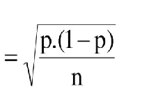

Como usamos 95% de confiança, temos 5% de significância  
5% = 0,05, que dividido por 2 = 0,025  
Assim, Z 0,025 = 1,96 (tabela Normal)

QUESTÃO 169 -3  
O nível de colesterol segue distribuição Normal com variância conhecida igual a 64 (mg/ml)². Uma amostra de 46 indivíduos apresentou média de 120  
mg/ml. Construa o intervalo de confiança de 88% para a média populacional. (Dado: z0,06=1,55)

1. (118,17 ; 121,83)
2. (117,90 ; 122,10)
3. (118,35 ; 121,65)
4. (117,50 ; 122,50)
5. (119,10 ; 120,90)

RESPOSTA: A  
σ=8  
Erro padrão:  
8/ raiz quadrada de 46 = 1,18

Intervalo de confiança:  
IC: Xˉ ± Z 0,06 * erro padrão  
IC: 120 ± 1,55 * 1,18 = (118,17 ; 121,83)

QUESTÃO 170 - 3  
O consumo médio de combustível de um modelo de automóvel tem desvio padrão conhecido igual a 2 km/l. Uma amostra de 40 veículos apresentou média de 9,3 km/l. Construa o intervalo de confiança de 94% para a média populacional. (Dado: z0,03=1,88)

1. (8,70 ; 9,90)
2. (8,71 ; 9,89)
3. (8,65 ; 9,95)
4. (8,80 ; 9,80)
5. (8,50 ; 10,10)

RESPOSTA: B  
Erro padrão:  
2 / raiz quadrada de 40 = 0,316

Intervalo de confiança:  
IC: Xˉ ± Z 0,03 * erro padrão  
IC: 9,3 ± 1,88 * 0,316 = (8,71;9,89)

QUESTÃO 171 - 3  
Um intervalo de confiança de 95% para a média de uma população Normal com desvio padrão 2 foi construído com base em uma amostra de tamanho 100: (35,21;35,99). Qual foi o valor da média amostral?

1. 35,50
2. 35,60
3. 35,40
4. 35,21
5. 35,99

RESPOSTA: 35,60  
A média amostral é o ponto central do intervalo:  
(35,21+35,99)/2 = 35,6

QUESTÕES 173 - 2  
Se X ∼ N(μ,σ²) com μ = 50 e σ = 10, qual transformação gera Z ∼ N(0,1)?  
A) Z=(X−50)/10  
B) Z=(X−10)/50  
C) Z=(50−X)/10  
D) Z=(X−50)/100  
E) Z=10(X−50)  
RESPOSTA: A  
• A padronização é Z = (X−μ)/σ.  
• Com μ=50 e σ=10: Z = (X−50)/10.

QUESTÃO 174 - 1  
Se X1,…,Xn são i.i.d. com média μ e variância σ², qual é Var(X̄)?  
A) σ²  
B) σ²/n  
C) nσ²  
D) σ²/(n−1)  
E) (n−1)σ  
RESPOSTA: B  
• X̄ = (1/n)∑Xi.  
• Var(X̄) = σ²/n

QUESTÕES 175 - 2  
Deseja-se escolher n tal que P(|X̄ − μ| ≤ ε) = γ, com σ conhecido. Qual expressão para n aparece no livro (em função de σ, ε e zγ)?  
A) n = (σ/ε)·zγ  
B) n = σ²·zγ/ε²  
C) n = σ²·zγ²/ε²  
D) n = (ε/σ)·zγ²  
E) n = (σ²/ε)·zγ²  
RESPOSTA: C  
• Do desenvolvimento, usa-se Z = (X̄−μ)√n/σ e P(−zγ < Z < zγ)=γ.  
• Resulta √n·ε/σ = zγ. • Elevando ao quadrado: n = σ²·zγ²/ε².

QUESTÕES 177 - 3  
Um IC(μ;0,95) foi obtido como ]12,3; 15,7[. Qual interpretação está correta? A) P(12,3 < μ < 15,7) = 0,95 para este μ fixo.  
B) Em 95% das amostras, o intervalo construído conterá o μ verdadeiro.  
C) μ varia aleatoriamente e tem 95% de chance de cair no intervalo.  
D) O intervalo contém 95% dos dados da amostra.  
E) A amplitude do intervalo depende de X̄, mas não de n.  
RESPOSTA: B  
• μ é um parâmetro fixo; o intervalo é aleatório porque depende da amostra.  
• A interpretação frequencista: em repetições do procedimento, 95% dos intervalos conterão o verdadeiro μ.

QUESTÕES 178 - 3  
Qual sequência corresponde aos passos gerais para construir um teste de hipóteses?  
A) Fixar RC → Fixar H0/H1 → Calcular estatística → Fixar α → Decidir  
B) Fixar H0/H1 → Escolher estatística → Fixar α e construir RC → Calcular estatística → Decidir  
C) Escolher estatística → Fixar H0/H1 → Fixar α → Calcular estatística → Construir RC  
D) Fixar α → Fixar H0/H1 → Decidir → Construir RC → Calcular estatística  
E) Construir RC → Fixar α → Fixar H0/H1 → Escolher estatística → Decidir RESPOSTA: B  
• Os passos são: (1) fixar H0 e H1; (2) escolher estatística e sua distribuição sob H0; (3) fixar α e construir RC; (4) calcular a estatística com os dados; (5) decidir comparando com a RC.

QUESTÃO 179 - 1  
Um pesquisador deseja estudar a variável ”Renda Mensal” de um grupo de funcionários. Ao organizar os dados, ele percebe que a distribuição é fortemente assimétrica à direita (cauda longa para a direita). Segundo a abordagem de Bussab & Morettin, qual a relação esperada entre as medidas de posição?  
A) Média < Mediana < Moda  
B) Moda = Mediana = Média  
C) Moda < Mediana < Média  
D) Mediana < Moda < Média  
E) Média = Mediana < Moda  
RESPOSTA: C  
Em distribuições assimétricas à direita, os valores extremos altos ”puxam” a média para cima. A moda é o valor mais frequente (pico da curva), e a mediana divide a área ao meio, ficando entre as duas.

QUESTÃO 180 - 1  
Considere um conjunto de dados X = {x1, x2, . . . , xn} com variância s^2 . Se multiplicarmos todos os valores do conjunto por uma constante k e somarmos uma constante c a cada valor, a nova variância será:  
A) s^2 + c  
B) k · s^2  
C) k^2 · s^2 + c  
D) k^2 · s^2  
E) k(s^2 + c)  
RESPOSTA: D  
Pela propriedade da variância, se Y = kX + c, então Var(Y ) = Var(kX + c) = k^2Var(X). A constante aditiva c não altera a dispersão.

QUESTÃO 182 - 1  
Ao estudar a relação entre duas variáveis quantitativas X e Y , o Coeficiente de Correlação de Pearson (r) resultou em −0, 85. Segundo os autores, este valor indica:  
A) Uma correlação linear nula.  
B) Uma correlação linear positiva e fraca.  
C) Uma correlação linear negativa e forte.  
D) Uma correlação não linear perfeita.  
E) Um erro de cálculo, pois r deve ser sempre positivo.  
RESPOSTA: C  
O coeficiente r varia de -1 a 1. Valores próximos de -1 indicam uma correlação linear forte e negativa (inversamente proporcionais).

QUESTÃO 183 - 2  
Para uma variável aleatória discreta, a função que dá P(X=x) para cada valor x chama-se:

1. Função densidade de probabilidade.
2. Função de probabilidade.
3. Função logarítmica.
4. Função derivada
5. Função exponencial

RESPOSTA: B

QUESTÃO 184 - 2  
Qual condição é obrigatória para uma função p(x) ser uma função de probabilidade de uma variável discreta?

1. p(x) pode ser negativa
2. A soma de todas as p(x) é 2
3. A soma de todas as p(x) é 1 e p(x)≥0
4. p(x) deve ser sempre crescente
5. p(x) deve ser contínua

RESPOSTA: C  
Probabilidades não podem ser negativas e a soma total deve dar 1.

QUESTÃO 185 - 2  
X assume valores 0,1,2 com p(0)=0,2; p(1)=k; p(2)=0,3. Qual é k para p(x) ser válida?

1. 0,1
2. 0,2
3. 0,3
4. 0,4
5. 0,5

RESPOSTA: E  
A soma das probabilidades deve ser 1, logo:  
0,2 + k + 0,3 = 1  
0,5 + k = 1  
k = 1 - 0,5  
k = 0,5  
QUESTÃO 186 - 2  
Uma moeda honesta é lançada 3 vezes. Seja X o número de caras. Qual é P(X=2)?

1. 1/8
2. 2/8
3. 3/8
4. 4/8
5. 6/8

RESPOSTA: C  
X segue Binomial com n=3 e p=1/2 (X~Bin(3,1/2 )

P(X=2) = C(3,2) * (1/2)^2 * (1/2)^1  
P(X=2) = 3 * 1/8  
P(X=2) = 3/8

QUESTÃO 187 - 2  
Em 4 lançamentos de moeda honesta, qual é P(X=0)?

1. 1/2
2. 1/4
3. 1/8
4. 1/16
5. 4/16

RESPOSTA: D  
X segue Binomial com n=4 e p=1/2 (X~Bin(4,1/2 )

P(X=0) = C(4,0) * (1/2)^0 * (1/2)^4  
P(X=0) = (1) * (1/16)  
P(X=0) = 1/16

QUESTÃO 188 - 2  
Em 6 tentativas independentes com probabilidade de sucesso p=0,4, X~Bin(6;0,4). Qual é P(X≤2)?

1. 0,18
2. 0,32
3. 0,54
4. 0,68
5. 0,82

RESPOSTA: C  
P(X≤2) = P(0)+P(1)+P(2)  
P(0) = C(6,0) * 0,6^6 = 0,0467  
P(1) = C(6,1) * 0,4 * 0,6^5 = 0,1866  
P(2) = C(6,2) * 0,4^2 * 0,6^4 = 0,3110.

QUESTÃO 189 - 2  
Em 8 tentativas com p=0,2, qual é P(X=3) para X~Bin(8,0,2)?

1. 0,021
2. 0,056
3. 0,147
4. 0,279
5. 0,512

RESPOSTA: C  
P(X=3) = C(8,3) * 0,2^3 * 0,8^5  
= 56 * 0,008 * 0,32768  
= 56 * 0,002621 = 0,1468

QUESTÃO 190 - 2  
Se X~Binomial(n=10, p=0,5), então E(X) e Var(X) são, respectivamente:

1. 5 e 2,5
2. 10 e 5
3. 5 e 5
4. 2,5 e 5
5. 5 e 10

RESPOSTA: A  
Para binomial:  
E(X) = np = 10 * 0,5 = 5  
Var(X) = np(1−p) = 10*0,5*0,5 = 2,5

QUESTÃO 191 - 2  
A distribuição Exponencial é muito usada para modelar:

1. Número de sucessos em n tentativas
2. Tempo de espera até um evento ocorrer
3. Soma de probabilidades discretas
4. Alturas de pessoas em uma população
5. Erros de medição sempre simétricos

RESPOSTA: B  
A exponencial modela tempo de espera (ex.: tempo até a falha de um dispositivo).

QUESTÃO 192 - 2  
Se X~Exponencial(λ=4), então E(X) e Var(X) são:

1. ) 4 e 16
2. 1/4 e 1/16
3. 1/4 e 1/8
4. 4 e 4
5. 1 e 1

RESPOSTA: B  
Para exponencial:  
E(X) = 1/λ  
Com λ=4  
E=1/4

1. É sempre assimétrica
2. É simétrica em torno da média
3. Só assume valores inteiros
4. Tem probabilidade 1 em um único ponto
5. Só serve para contagens

RESPOSTA: B  
A normal é uma curva contínua e simétrica em torno da média

QUESTÃO 195 - 1  
A variável ”Grau de Escolaridade” (Fundamental, Médio, Superior) é classificada como:  
A) Qualitativa Nominal.  
B) Qualitativa Ordinal.  
C) Quantitativa Discreta.  
D) Quantitativa Contínua.  
E) Variável Dummy.  
RESPOSTA: B  
É qualitativa pois expressa um atributo, e ordinal pois existe uma hierarquia lógica (Fundamental < Médio < Superior).

QUESTÃO 196 - 2  
Dois eventos A e B são considerados independentes se, e somente se:  
A) P(A∪B)=P(A)+P(B)  
B) P(A∩B)=0  
C) P(A|B) = P(B)  
D) P(A∩B)=P(A)·P(B)  
E) A e B forem mutuamente exclusivos.  
RESPOSTA: D  
Esta é a definição clássica de independência: a probabilidade da intersecção de dois eventos independentes é igual ao produto das suas probabilidades marginais.

QUESTÃO 197 - 2  
Em uma urna há 5 bolas brancas e 3 pretas. Duas bolas são retiradas sucessivamente, sem reposição. Qual a probabilidade de a primeira ser branca e a segunda ser preta?  
A) 15/64  
B) 15/56  
C) 5/8  
D) 3/8  
E) 15/28  
RESPOSTA: B  
Sendo Eventos dependentes (sem reposição):  
P(B1∩P2) = P(B1)·P(P2|B1) = 5/8 · 3/7 = 15/56.

QUESTÃO 198 - 2  
Uma variável aleatória X segue uma distribuição de Bernoulli com parâmetro p = 0,4. A variância de X, Var(X), é igual a:  
A) 0,40  
B) 0,60  
C) 0,24  
D) 0,16  
E) 1,00  
RESPOSTA: C  
Para a distribuição de Bernoulli, a variância é dada por Var(X) = p · (1 − p). Logo, Var(X) = 0,4·0,6 = 0,24.

QUESTÃO 200 - 2  
Seja Z uma variável aleatória com distribuição Normal Padrão, Z ∼ N(0,1). Se desejamos encontrar um valor k tal que P(−k ≤ Z ≤ k)=0,95,qual o valor aproximado de segundo tabelas clássicas?  
A) 1,00  
B) 1,64  
C) 1,96  
D) 2,33  
E) 2,58  
RESPOSTA: C  
O intervalo que concentra 95% da probabilidade na Normal Padrão (Z) deixa 2, 5% em cada cauda. O valor crítico z correspondente na tabela é 1,96.

QUESTÃO 201 - 2  
Uma moeda honesta é lançada 100 vezes. Para calcular a probabilidade de obter entre 45 e 55 “caras” usando a aproximação pela Normal, devemos considerar a variável contínua X ∼ N(µ,σ^2) com:  
A) µ =50 e σ^2 =50  
B) µ =50 e σ^2 =25  
C) µ =100 e σ^2 =50  
D) µ=0,5 e σ^2 =0,25  
E) µ =50 e σ^2 =10  
RESPOSTA: B  
A aproximação normal tem os parâmetros: µ = E(X) = n·p = 100·0,5 = 50, e a variância σ^2 = n·p·(1−p) = 100·0,5·0,5 = 25.

QUESTÃO 202 - 3  
A técnica de amostragem que consiste em dividir a população em grupos homogêneos e selecionar uma amostra aleatória de cada grupo é chamada de:  
A) Amostragem Sistemática.  
B) Amostragem por Conveniência.  
C) Amostragem aleatória Simples.  
D) Amostragem Estratificada.  
E) Amostragem por Conglomerados.  
RESPOSTA: D  
Esta é a exata definição de amostragem estratificada, muito útil para reduzir a variância dos estimadores quando as subpopulações (estratos) são distintas entre si.

QUESTÃO 203 - 3  
Um estimador θ é dito ser não viesado (ou não viciado) para o parâmetro θ se:  
A) Sua variância for mínima.  
B) O limite de sua probabilidade convergir para θ.  
C) Seu valor esperado for igual ao parâmetro: E(θ) = θ.  
D) Ele for calculado a partir de uma amostra grande (n > 30).  
E) Sua distribuição for Normal.  
RESPOSTA: C  
Um estimador é dito não viesado quando sua esperança matemática(valor esperado) é exatamente igual ao verdadeiro valor do parâmetro populacional.

QUESTÃO 204 - 3  
Para uma amostra de tamanho n = 100 de uma população com desvio padrão conhecido σ = 20, o erro padrão da média é:  
A) 20  
B) 2  
C) 0,2  
D) 200  
E) 10  
RESPOSTA: B  
O erro padrão da média é dado por σ¯x = σ/√ n . Substituindo: 20/√100 = 20/10 = 2.

RESPOSTA: C  
A 1 é binomial. A 2 só seria binomial se todas as urnas tivessem exatamente a mesma proporção de bolas e a 3 só seria binomial se a probabilidade de alguém ser contra fosse a mesma em todas as cidades e as escolhas independentes.

QUESTÃO 207 - 2  
Se X ~ b(n, p), sabendo-se que E(X) = 12 e σ2= 3, determine n e p

1. 21 e 4
2. 16 e 12
3. 3/4 e 3
4. 16 e 3/4
5. 12 e 16

RESPOSTA: D  
E(X) = np  
Logo, se E(X)=12, conclui-se que np=12  
Var(X)=np(1−p)  
Logo, se Var(X)=3, conclui-se que np(1-p) = 3

Sabendo que np=12, podemos substituir na Var(X):  
12(1-p) = 3  
1-p = 3/12  
1-p = 1/4  
1+p = - 1/4  
p = 1 - 1/4  
p = 3/4

Com o valor de p e np, podemos obter o valor de n:  
np=12  
3/4 * n = 12  
n = 12 * 4/3  
n = 16  
Logo, n=16 e p=3/4

QUESTÃO 208 - 2  
Numa central telefônica, o número de chamadas chega segundo uma distribuição de Poisson, com a média de oito chamadas por minuto. Determine qual a probabilidade de que num minuto se tenha 3 ou mais chamadas

1. 0,154
2. 0,986
3. 0,851
4. 0,322
5. 0,466

RESPOSTA: B  
X∼Poisson(λ=8) e queremos calcular P(X≥3)  
Para resolver esse cálculo, usamos o complemento:  
P(X>=3) = 1 - P(X<=2)  
E para calcularmos (PX<=2), devemos encontrar a soma de:  
P(X=0), P(X=1) e P(X=2)  
Para isso, usamos a fórmula:  
P(X=0) = 8^0 * e^-8 / 0! = e^-8 = 0,000335  
P(X=1) = 8^1 * e^-8 / 1! = 8e^-8 = 0,00268  
P(X=2) = 8^2 * e^-8 / 2! = 32e^-8 = 0,01073

P(X=0) + P(X=1) + P(X=2) = 0,000335 + 0,00268 + 0,01073 = 0,01375  
Como P(X≤2) = 0,01375  
P(X>=3) = 1 - 0,01375 = 0,986  
Ou seja, há 98,6% de chance de ocorrerem 3 ou mais chamadas em um minuto.

QUESTÃO 209 - 2  
Num certo tipo de fabricação de fita magnética, ocorrem cortes a uma taxa de um por 2.000 pés. Qual a probabilidade de que um rolo com 2.000 pés de fita magnética não tenha nenhum corte?

1. 0,457
2. 0,218
3. 0,368
4. 0,955
5. 0,150

RESPOSTA: C  
A taxa é 1 corte a cada 2.000 pés, se o rolo tem 2.000 pés, então: λ=1  
Queremos calcular P(X=0), e para isso, usamos a fórmula:  
P(X=0) = 1^0 * e^-1 / 0! = e^-1 = 0,3679

QUESTÃO 210 - 2  
Suponha que a probabilidade de que um item produzido por uma máquina seja defeituoso é de 0,2. Se dez itens produzidos por essa máquina são selecionados ao acaso, qual é a probabilidade de que não mais do que um defeituoso seja encontrado?

1. 0,376
2. 0,452
3. 0,621
4. 0,998
5. 0,126

RESPOSTA: A  
X∼Bin(10;0,2), queremos encontrar P(X<=1)  
P(X≤1) = P(X=0) + P(X=1)  
Calculando separadamente, usando a fórmula:

P(X=0) = C(10,0) * 0,2^0 * (0,8)^10 = (0,8)^10 = 0,1074  
P(X=1) = C(10,1) * 0,2^1 * (0,8)^9 = 10* 0,2 * (0,8)^9 = 0,2684  
P(X≤1) = 0,1074+0,2684 = 0,3758

QUESTÃO 211 - 2  
Na manufatura de certo artigo, é sabido que um entre dez dos artigos é defeituoso. Qual a probabilidade de que uma amostra casual de tamanho quatro contenha exatamente um defeituoso?

1. 0,429
2. 0,512
3. 0,292
4. 0,398
5. 0,113

RESPOSTA: C  
X∼Bin(4,0,1), queremos: P(X=1)  
Usando a fórmula:

P(X=1) = C(4,1) * 0,1^1 * 0,9^3 = 4 * 0,1* 0,9^3 = 0,2916

QUESTÃO 212 - 2  
Um fabricante de peças de automóveis garante que uma caixa de suas peças conterá, no máximo, duas defeituosas. Se a caixa contém 18 peças, e a experiência tem demonstrado que esse processo de fabricação produz 5% das peças defeituosas, qual a probabilidade de que uma caixa satisfaça a garantia?

1. 0,94
2. 0,85
3. 0,62
4. 0,31
5. 0,12

RESPOSTA: A  
X∼Bin(18;0,05), queremos encontrar P(X≤2)  
P(X≤2)=P(X=0)+P(X=1)+P(X=2)  
Usando a fórmula:

P(X=0)=C(18,0) * (0,05)^0 * (0,95)^18 = (0,95)^18 = 0,397  
P(X=1)=C(18,1) * (0,05)^1 * (0,95)^17 = 18* 0,05* (0,95)^17 = 0,376  
P(X=2)=C(18,2) * (0,05)^2 * (0,95)^16 = 153 * 0,05^2 * (0,95)^16 = 0,168

P(X=0)+P(X=1)+P(X=2) = 0,397+0,376+0,168 = 0,941

QUESTÃO 213 - 2  
Um curso de treinamento aumenta a produtividade de uma certa população de funcionários em 80% dos casos. Se dez funcionários quaisquer participam desse curso, encontre a probabilidade de exatamente sete funcionários aumentarem a produtividade?

1. 0,326
2. 0,201
3. 0,408
4. 0,015
5. 0,874

RESPOSTA: B  
X∼Bin(10;0,8), queremos encontrar P(X=7)  
Usando a fórmula:

P(X=7) = C(10,7) * 0,8^7 * 0,2^3 = 120 * 0,2097 * 0,008 = 0,2013

QUESTÃO 214 - 2  
O número de petroleiros que chegam a uma refinaria em cada dia ocorre segundo uma distribuição de Poisson, com λ = 2. As atuais instalações podem atender, no máximo, a três petroleiros por dia. Se mais de três aportarem num dia, o excesso é enviado a outro porto. Em um dia, qual a probabilidade de se enviar petroleiros para outro porto?

1. 0,241
2. 0,633
3. 0,874
4. 0,108
5. 0,143

RESPOSTA: E  
X∼Poisson(λ=2), queremos calcular P(X>3)  
Para resolver, usamos o complemento:  
P(X>3) = 1−P(X≤3)  
E a P(X≤3) = P(X=0) + P(X=1) + P(X=2) + P(X=3)  
Usando a fórmula:  
P(X=0) = 2^0 * e^-2 / 0! = 0,1353  
P(X=1) = 2^1 * e^-2 / 1! = 0,2707  
P(X=0) = 2^2 * e^-2 / 2! = 0,2707  
P(X=0) = 2^3 * e^-2 / 3! = 0,1804

P(X=0) + P(X=1) + P(X=2) + P(X=3) = 0,1353+0,2707+0,2707+0,1804 =0,857  
Usando o complemento: P(X>3) = 1−0,8571 = 0,1429